# Guia de leitura do código em R

Companion da dissertação e do Replication Package V2

08 August 2026

# 1 Como ler este documento

Este é um guia de leitura, não um novo pipeline de replicação. Ele foi feito para ser aberto ao lado da [Dissertação de Mestrado V3 no Notion](https://app.notion.com/p/Disserta-o-de-Mestrado-V3-33dcc8ca461082bda8880151f42ba19b?source=copy_link) e do Replication Package V2.

O objetivo é tornar visíveis, em uma única navegação:

- quais dados entram em cada parte da dissertação;
- como os painéis são construídos;
- quais equações são estimadas em R;
- quais partes são executadas aqui, quais são carregadas da referência assinada e quais seriam pesadas demais para este guia;
- como as tabelas, os gráficos, os testes de pré-tendência e os limites de interpretação se conectam.

O documento **não altera** `V2/results/reference/`. As tabelas e figuras congeladas são lidas dessa referência; os poucos modelos executados usam apenas as entradas analíticas compactas já presentes no bundle V2.

**Carregado da referência assinada do V2.** O guia lê 53 artefatos assinados do V2 e os mapeia para as 55 tabelas e figuras computacionais da versão atual da dissertação.

## 1.1 Convenções de leitura

Ao longo do documento, cada bloco importante traz uma etiqueta:

- **Executed in this document**: uma versão leve é de fato reestimada em R a partir de uma entrada analítica compacta.
- **Loaded from the signed V2 reference**: o artefato é o resultado congelado do V2, apenas exibido para leitura.
- **Code displayed for reading only**: é o código canônico ou uma tradução didática; não é reexecutado aqui porque depende de fontes brutas, painéis grandes ou de toda a DAG.
- **Scientific gate**: uma restrição substantiva que deve acompanhar a leitura do resultado, mesmo quando a tabela ou o gráfico está disponível.

## 1.2 Mapa de cobertura da dissertação

O V2 assinado contém 53 artefatos publicados. A versão atual da dissertação também mostra duas tabelas descritivas adicionais no Apêndice A, ambas já sustentadas por backing data do V2. Por isso, o mapa abaixo tem 55 linhas, sem modificar a referência assinada.

Crosswalk between the current manuscript and the V2 code/reference artifacts

| manuscript_label | artifact_id | component | producer | reference_path | command |
| --- | --- | --- | --- | --- | --- |
| Figure 5.1: National event studies and trajectories | figure_5_1 | caged | code.render.phase8b_figures | caged/figures/figure_5_1_national_event_studies.png | python run_replication.py –target caged –mode reproduce |
| Figure 5.2.1.1: Admissions by sex | figure_5_2_1_1 | caged | code.render.phase8b_figures | caged/figures/figure_5_2_1_1_sex_admissions.png | python run_replication.py –target caged –mode reproduce |
| Figure 5.2.1.2: Real admission wage by sex | figure_5_2_1_2 | caged | code.render.phase8b_figures | caged/figures/figure_5_2_1_2_sex_wage.png | python run_replication.py –target caged –mode reproduce |
| Figure 5.2.2.1: Admissions by race or color | figure_5_2_2_1 | caged | code.render.phase8b_figures | caged/figures/figure_5_2_2_1_race_admissions.png | python run_replication.py –target caged –mode reproduce |
| Figure 5.2.2.2: Real admission wage by race or color | figure_5_2_2_2 | caged | code.render.phase8b_figures | caged/figures/figure_5_2_2_2_race_wage.png | python run_replication.py –target caged –mode reproduce |
| Figure 5.2.3.1: Admissions by age group | figure_5_2_3_1 | caged | code.render.phase8b_figures | caged/figures/figure_5_2_3_1_age_admissions.png | python run_replication.py –target caged –mode reproduce |
| Figure 5.2.3.2: Real admission wage by age group | figure_5_2_3_2 | caged | code.render.phase8b_figures | caged/figures/figure_5_2_3_2_age_wage.png | python run_replication.py –target caged –mode reproduce |
| Figure 5.2.3.3: Real admission wage for ages 22 to 25 | figure_5_2_3_3 | caged | code.render.canaries_wage_figure | caged/figures/figure_5_2_3_3_canaries_22_25_wage.png | python run_replication.py –target caged –mode reproduce |
| Figure 5.2.4.1: Admissions by education | figure_5_2_4_1 | caged | code.render.phase8b_figures | caged/figures/figure_5_2_4_1_education_admissions.png | python run_replication.py –target caged –mode reproduce |
| Figure 5.2.4.2: Real admission wage by education | figure_5_2_4_2 | caged | code.render.phase8b_figures | caged/figures/figure_5_2_4_2_education_wage.png | python run_replication.py –target caged –mode reproduce |
| Figure 5.2.5.1: Admissions by pre-treatment income | figure_5_2_5_1 | caged | code.render.phase8b_figures | caged/figures/figure_5_2_5_1_income_admissions.png | python run_replication.py –target caged –mode reproduce |
| Figure 5.2.5.2: Real admission wage by pre-treatment income | figure_5_2_5_2 | caged | code.render.phase8b_figures | caged/figures/figure_5_2_5_2_income_wage.png | python run_replication.py –target caged –mode reproduce |
| Figure 5.2.6: Within-group DiD estimates by outcome | figure_5_2_6 | caged | code.render.phase8b_figures | caged/figures/figure_5_2_6_group_outcome_forest.png | python run_replication.py –target caged –mode reproduce |
| Figure C.1: Monthly admissions by occupational case and age | figure_c_1 | caged | code.render.phase8b_figures | caged/figures/figure_c_1_occupation_cases_admissions_by_age.png | python run_replication.py –target caged –mode reproduce |
| Figure C.2: Monthly real admission wage by occupational case and age | figure_c_2 | caged | code.render.phase8b_figures | caged/figures/figure_c_2_occupation_cases_wage_by_age.png | python run_replication.py –target caged –mode reproduce |
| Table 4.2.1: Occupation-month panel scope | table_4_2_1 | caged | code.render.phase8b_tables | caged/tables/table_4_2_1_panel_scope.csv | python run_replication.py –target caged –mode reproduce |
| Table 4.2.2: CBO treatment and control classification | table_4_2_2 | caged | code.render.phase8b_tables | caged/tables/table_4_2_2_treatment_classification.csv | python run_replication.py –target caged –mode reproduce |
| Table 4.2.3: Panel coverage by exposure group | table_4_2_3 | caged | code.render.phase8b_tables | caged/tables/table_4_2_3_panel_coverage.csv | python run_replication.py –target caged –mode reproduce |
| Table 4.3.1: Analysis outcomes | table_4_3_1 | caged | code.render.phase8b_tables | caged/tables/table_4_3_1_outcomes.csv | python run_replication.py –target caged –mode reproduce |
| Table 5.1.1: Sector-control co-principal specifications | table_5_1_1 | caged | code.render.phase8b_tables | caged/tables/table_5_1_1_sector_control.csv | python run_replication.py –target caged –mode reproduce |
| Table 5.1: National average results | table_5_1 | caged | code.render.phase8b_tables | caged/tables/table_5_1_national_results.csv | python run_replication.py –target caged –mode reproduce |
| Table 5.2.1: Results by sex | table_5_2_1 | caged | code.render.phase8b_tables | caged/tables/table_5_2_1_sex.csv | python run_replication.py –target caged –mode reproduce |
| Table 5.2.2: Results by race or color | table_5_2_2 | caged | code.render.phase8b_tables | caged/tables/table_5_2_2_race.csv | python run_replication.py –target caged –mode reproduce |
| Table 5.2.3: Results by age group | table_5_2_3 | caged | code.render.phase8b_tables | caged/tables/table_5_2_3_age.csv | python run_replication.py –target caged –mode reproduce |
| Table 5.2.4: Results by education | table_5_2_4 | caged | code.render.phase8b_tables | caged/tables/table_5_2_4_education.csv | python run_replication.py –target caged –mode reproduce |
| Table 5.2.5: Results by pre-treatment occupational wage | table_5_2_5 | caged | code.render.phase8b_tables | caged/tables/table_5_2_5_income.csv | python run_replication.py –target caged –mode reproduce |
| Table A.1 | table_a_1 | caged | code.render.phase8b_tables | caged/tables/table_a_1_national_diagnostics.csv | python run_replication.py –target caged –mode reproduce |
| Table A.2.1 | table_a_2_1 | caged | caged audit backing data | caged/audit/a1_education_composition_shift.csv | Backed by V2 CAGED audit |
| Table A.2.2 | table_a_2_2 | caged | caged audit backing data | caged/audit/a2_wage_price_composition_split.csv | Backed by V2 CAGED audit |
| Table A.3 | table_a_2 | caged | code.render.phase8b_tables | caged/tables/table_a_2_sex.csv | python run_replication.py –target caged –mode reproduce |
| Table A.4 | table_a_3 | caged | code.render.phase8b_tables | caged/tables/table_a_3_race.csv | python run_replication.py –target caged –mode reproduce |
| Table A.5 | table_a_4 | caged | code.render.phase8b_tables | caged/tables/table_a_4_age.csv | python run_replication.py –target caged –mode reproduce |
| Table A.6 | table_a_5 | caged | code.render.phase8b_tables | caged/tables/table_a_5_education.csv | python run_replication.py –target caged –mode reproduce |
| Table A.7 | table_a_6 | caged | code.render.phase8b_tables | caged/tables/table_a_6_income.csv | python run_replication.py –target caged –mode reproduce |
| Table C.1: Occupational case selection and exposure composition | table_c_1 | caged | code.render.phase8b_tables | caged/tables/table_c_1_occupation_cases.csv | python run_replication.py –target caged –mode reproduce |
| Table B.2: Exact-model pretrends for PNADc | table_b_2 | pnadc | code.render.complementary | pnadc/tables/table_b_2_pnadc_pretrends.csv | python run_replication.py –target pnadc –mode reproduce |
| Table D.2: Occupational composition and stock (Family E) | table_d_2 | pnadc | code.render.complementary | pnadc/tables/table_d_2_pnadc.csv | python run_replication.py –target pnadc –mode reproduce |
| Table B.1: Exact-model pretrends for RAIS | table_b_1 | rais | code.render.complementary | rais/tables/table_b_1_rais_pretrends.csv | python run_replication.py –target rais –mode reproduce |
| Table D.1: Formal stock turnover and job tenure (Family D) | table_d_1 | rais | code.render.complementary | rais/tables/table_d_1_rais.csv | python run_replication.py –target rais –mode reproduce |
| Figure 3.10: AI exposure by formality status | figure_3_10 | section3 | code.section3.pipeline | section3/figures/figure_3_10_formality.png | python run_replication.py –target section3 –mode reproduce |
| Figure 3.1: Distribution of AI exposure in Brazil | figure_3_1 | section3 | code.section3.pipeline | section3/figures/figure_3_1_histogram_kde.png | python run_replication.py –target section3 –mode reproduce |
| Figure 3.2: Employed population by AI exposure gradient | figure_3_2 | section3 | code.section3.pipeline | section3/figures/figure_3_2_gradient_population.png | python run_replication.py –target section3 –mode reproduce |
| Figure 3.3: Occupational composition by AI exposure score | figure_3_3 | section3 | code.section3.pipeline | section3/figures/figure_3_3_score_by_occupation_group.png | python run_replication.py –target section3 –mode reproduce |
| Figure 3.4: High AI exposure by state | figure_3_4 | section3 | code.section3.pipeline | section3/figures/figure_3_4_state_high_exposure.png | python run_replication.py –target section3 –mode reproduce |
| Figure 3.5: AI exposure by sex | figure_3_5 | section3 | code.section3.pipeline | section3/figures/figure_3_5_sex.png | python run_replication.py –target section3 –mode reproduce |
| Figure 3.6: AI exposure by race or color | figure_3_6 | section3 | code.section3.pipeline | section3/figures/figure_3_6_race.png | python run_replication.py –target section3 –mode reproduce |
| Figure 3.7: AI exposure by age group | figure_3_7 | section3 | code.section3.pipeline | section3/figures/figure_3_7_age.png | python run_replication.py –target section3 –mode reproduce |
| Figure 3.8: AI exposure by education | figure_3_8 | section3 | code.section3.pipeline | section3/figures/figure_3_8_education.png | python run_replication.py –target section3 –mode reproduce |
| Figure 3.9: AI exposure by income group | figure_3_9 | section3 | code.section3.pipeline | section3/figures/figure_3_9_income.png | python run_replication.py –target section3 –mode reproduce |
| Table 3.1: Final analytical data specification | table_3_1 | section3 | code.section3.pipeline | section3/tables/table_3_1_base_specs.csv | python run_replication.py –target section3 –mode reproduce |
| Table 3.2: Employed population by AI exposure gradient | table_3_2 | section3 | code.section3.pipeline | section3/tables/table_3_2_gradients.csv | python run_replication.py –target section3 –mode reproduce |
| Table 3.3: Largest occupations with high AI exposure | table_3_3 | section3 | code.section3.pipeline | section3/tables/table_3_3_high_exposure_occupations.csv | python run_replication.py –target section3 –mode reproduce |
| Table 3.4: AI exposure by sector | table_3_4 | section3 | code.section3.pipeline | section3/tables/table_3_4_sector_exposure.csv | python run_replication.py –target section3 –mode reproduce |
| Table B.3: December 2021 temporal placebo | table_b_3 | spatial | code.render.complementary | spatial/tables/table_b_3_spatial_placebo.csv | python run_replication.py –target spatial –mode reproduce |
| Table B.4: Effective clusters by digital-intensity proxy | table_b_4 | spatial | code.render.complementary | spatial/tables/table_b_4_spatial_support.csv | python run_replication.py –target spatial –mode reproduce |

| object | location |
| --- | --- |
| V2 source | ../V2 |
| Signed reference | ../V2/results/reference/artifacts |
| Analytical bundle | ../_bundle/v2 |

# 2 Medida de exposição e análise descritiva (Seções 2 e 3)

## 2.1 O que a seção constrói

A Seção 3 combina a PNAD Contínua 2025T3 com a classificação de exposição ocupacional à IA. A unidade observada é a pessoa ocupada; os resultados usam pesos da pesquisa para recuperar agregados populacionais. A classificação é feita na ocupação disponível, mantendo explicitamente a cobertura de pareamentos de quatro e três dígitos e os casos não classificados.

**Código exibido apenas para leitura.** O arquivo analítico completo da Seção 3 está em Parquet e não é lido aqui de propósito. O script de agregação em R e os agregados congelados abaixo mostram exatamente o que é calculado sem duplicar o bundle analítico em memória.

## 2.2 A agregação independente em R

O V2 usa o script abaixo para recalcular os agregados da Seção 3 em R. O script lê uma base analítica, define os grupos de exposição e produz identificadores estáveis `scope::key::metric`, que depois são comparados com os valores calculados no pipeline principal.

```r
#!/usr/bin/env Rscript

suppressPackageStartupMessages({
  library(data.table)
  library(jsonlite)
})

arguments <- commandArgs(trailingOnly = TRUE)
argument_value <- function(flag) {
  position <- match(flag, arguments)
  if (is.na(position) || position == length(arguments)) {
    stop("Missing required argument: ", flag)
  }
  arguments[[position + 1L]]
}

input_path <- normalizePath(argument_value("--input"), mustWork = TRUE)
output_path <- argument_value("--output")
status_path <- argument_value("--status")
dir.create(dirname(output_path), recursive = TRUE, showWarnings = FALSE)

if (paste(R.version$major, R.version$minor, sep = ".") != "4.4.1") {
  stop("The locked replication runtime requires R 4.4.1.")
}

data <- fread(
  input_path,
  colClasses = list(
    character = c(
      "cod_ocupacao",
      "sigla_uf",
      "match_level",
      "exposure_gradient",
      "grande_grupo",
      "setor_agregado_original",
      "sector_corrected",
      "sexo_texto",
      "raca_agregada",
      "faixa_etaria",
      "faixa_renda_sm"
    )
  )
)

official_gradients <- c(
  "Not Exposed",
  "Minimal Exposure",
  "Exposed: Gradient 1",
  "Exposed: Gradient 2",
  "Exposed: Gradient 3",
  "Exposed: Gradient 4"
)
low_gradients <- c("Not Exposed", "Minimal Exposure")
moderate_gradients <- c("Exposed: Gradient 1", "Exposed: Gradient 2")
high_gradients <- c("Exposed: Gradient 3", "Exposed: Gradient 4")

aggregate_rows <- list()
add_aggregate <- function(scope, key, metric, value) {
  aggregate_rows[[length(aggregate_rows) + 1L]] <<- data.table(
    aggregate_id = paste(scope, key, metric, sep = "::"),
    scope = scope,
    aggregate_key = key,
    metric = metric,
    value = as.numeric(value)
  )
}

weighted_mean <- function(values, weights) {
  valid <- !is.na(values) & !is.na(weights)
  if (!any(valid)) {
    return(NA_real_)
  }
  sum(values[valid] * weights[valid]) / sum(weights[valid])
}

scored <- data[!is.na(exposure_score)]
official <- data[exposure_gradient %chin% official_gradients]
total_weight <- sum(data$peso)
score_weight <- sum(scored$peso)
add_aggregate("base", "sample", "observations", nrow(data))
add_aggregate("base", "sample", "population_m", total_weight / 1e6)
add_aggregate("base", "sample", "scored_population_m", score_weight / 1e6)
add_aggregate("base", "sample", "score_coverage_pct", score_weight / total_weight * 100)
add_aggregate("base", "sample", "four_digit_match_pct", mean(data$match_level == "4-digit") * 100)
add_aggregate("base", "sample", "three_digit_match_pct", mean(data$match_level == "3-digit") * 100)
add_aggregate("base", "sample", "unscored_rows_pct", mean(is.na(data$exposure_score)) * 100)
add_aggregate("base", "sample", "federal_units", uniqueN(data$sigla_uf, na.rm = TRUE))
add_aggregate("base", "sample", "occupations", uniqueN(data$cod_ocupacao, na.rm = TRUE))
add_aggregate("base", "sample", "matched_occupations", uniqueN(scored$cod_ocupacao, na.rm = TRUE))
add_aggregate("base", "sample", "original_sectors", uniqueN(data$setor_agregado_original, na.rm = TRUE))
add_aggregate("base", "sample", "corrected_sectors", uniqueN(data$sector_corrected, na.rm = TRUE))

for (gradient in c(official_gradients, "Sem classificação")) {
  group <- scored[exposure_gradient == gradient]
  weight <- sum(group$peso)
  add_aggregate("gradient", gradient, "population_m", weight / 1e6)
  add_aggregate("gradient", gradient, "share_pct", weight / score_weight * 100)
}

for (label in c("low", "moderate", "high")) {
  gradients <- switch(
    label,
    low = low_gradients,
    moderate = moderate_gradients,
    high = high_gradients
  )
  weight <- sum(official[exposure_gradient %chin% gradients]$peso)
  add_aggregate("exposure_group", label, "population_m", weight / 1e6)
  add_aggregate(
    "exposure_group",
    label,
    "share_pct",
    weight / sum(official$peso) * 100
  )
}

high <- official[exposure_gradient %chin% high_gradients]
top_occupations <- high[
  ,
  .(
    population_m = sum(peso) / 1e6,
    mean_score = weighted_mean(exposure_score, peso)
  ),
  by = .(cod_ocupacao, grande_grupo)
]
setorder(top_occupations, -population_m, cod_ocupacao)
top_occupations <- head(top_occupations, 5L)
for (rank in seq_len(nrow(top_occupations))) {
  row <- top_occupations[rank]
  key <- paste(rank, row$cod_ocupacao, row$grande_grupo, sep = ":")
  add_aggregate("high_occupation", key, "population_m", row$population_m)
  add_aggregate("high_occupation", key, "mean_score", row$mean_score)
}

official_total <- sum(official$peso)
for (sector in sort(unique(official$sector_corrected))) {
  group <- official[sector_corrected == sector]
  total <- sum(group$peso)
  low <- sum(group[exposure_gradient %chin% low_gradients]$peso)
  moderate <- sum(group[exposure_gradient %chin% moderate_gradients]$peso)
  high_weight <- sum(group[exposure_gradient %chin% high_gradients]$peso)
  values <- c(
    population_m = total / 1e6,
    brazil_share_pct = total / official_total * 100,
    mean_score = weighted_mean(group$exposure_score, group$peso),
    low_population_m = low / 1e6,
    low_share_pct = low / total * 100,
    moderate_population_m = moderate / 1e6,
    moderate_share_pct = moderate / total * 100,
    high_population_m = high_weight / 1e6,
    high_share_pct = high_weight / total * 100,
    exposed_population_m = (moderate + high_weight) / 1e6,
    exposed_share_pct = (moderate + high_weight) / total * 100
  )
  for (metric in names(values)) {
    add_aggregate("sector", sector, metric, values[[metric]])
  }
}

dimensions <- list(
  sex = list(column = "sexo_texto", income_only = FALSE),
  race = list(column = "raca_agregada", income_only = FALSE),
  age = list(column = "faixa_etaria", income_only = FALSE),
  education = list(column = "nivel_instrucao", income_only = FALSE),
  income = list(column = "faixa_renda_sm", income_only = TRUE),
  formality = list(column = "formal", income_only = FALSE)
)
for (dimension in names(dimensions)) {
  specification <- dimensions[[dimension]]
  base <- if (specification$income_only) data[tem_renda == 1] else data
  column <- specification$column
  score_base <- base[!is.na(exposure_score)]
  official_base <- base[exposure_gradient %chin% official_gradients]
  categories <- sort(
    unique(
      c(
        as.character(score_base[[column]]),
        as.character(official_base[[column]])
      )
    )
  )
  categories <- categories[!is.na(categories)]
  for (category in categories) {
    score_group <- score_base[as.character(get(column)) == category]
    group <- official_base[as.character(get(column)) == category]
    total <- sum(group$peso)
    low <- sum(group[exposure_gradient %chin% low_gradients]$peso)
    moderate <- sum(group[exposure_gradient %chin% moderate_gradients]$peso)
    high_weight <- sum(group[exposure_gradient %chin% high_gradients]$peso)
    values <- c(
      population_m = total / 1e6,
      mean_score = weighted_mean(score_group$exposure_score, score_group$peso),
      low_share_pct = low / total * 100,
      moderate_share_pct = moderate / total * 100,
      high_share_pct = high_weight / total * 100,
      high_population_m = high_weight / 1e6
    )
    key <- paste(dimension, category, sep = ":")
    for (metric in names(values)) {
      add_aggregate("demographic", key, metric, values[[metric]])
    }
  }
}

for (state in sort(unique(official$sigla_uf))) {
  group <- official[sigla_uf == state]
  total <- sum(group$peso)
  high_weight <- sum(group[exposure_gradient %chin% high_gradients]$peso)
  add_aggregate("state", state, "population_m", total / 1e6)
  add_aggregate("state", state, "high_population_m", high_weight / 1e6)
  add_aggregate("state", state, "high_share_pct", high_weight / total * 100)
}

for (major_group in sort(unique(scored$grande_grupo))) {
  group <- scored[grande_grupo == major_group]
  add_aggregate(
    "occupation_group",
    major_group,
    "population_m",
    sum(group$peso) / 1e6
  )
  add_aggregate(
    "occupation_group",
    major_group,
    "mean_score",
    weighted_mean(group$exposure_score, group$peso)
  )
}

add_aggregate("score_distribution", "all", "minimum", min(scored$exposure_score))
add_aggregate("score_distribution", "all", "maximum", max(scored$exposure_score))
add_aggregate(
  "score_distribution",
  "all",
  "weighted_mean",
  weighted_mean(scored$exposure_score, scored$peso)
)

aggregates <- rbindlist(aggregate_rows, use.names = TRUE)
setnames(aggregates, "aggregate_key", "key")
if (anyDuplicated(aggregates$aggregate_id)) {
  stop("Section 3 aggregate identifiers are not unique.")
}
setorder(aggregates, aggregate_id)
fwrite(aggregates, output_path)

status <- list(
  aggregate_rows = nrow(aggregates),
  data_table_version = as.character(packageVersion("data.table")),
  input_rows = nrow(data),
  r_version = paste(R.version$major, R.version$minor, sep = "."),
  status = "pass"
)
write_json(status, status_path, auto_unbox = TRUE, pretty = TRUE, digits = 16)
cat(toJSON(status, auto_unbox = TRUE, digits = 16), "\n")
```

## 2.3 Diagnóstico da base e reconciliação entre linguagens

A tabela de diagnóstico abaixo não é um resultado substantivo da dissertação. Ela documenta a construção da base: quantas observações entram, quantas permanecem depois dos filtros, qual população os pesos representam e quantas ocupações foram pareadas em quatro ou três dígitos. Assim, ela permite conferir se a amostra e a cobertura da classificação ocupacional correspondem ao desenho descrito na Seção 3.

**Carregado da referência assinada do V2.** São diagnósticos congelados e agregados independentes em R. Eles não são regenerados neste guia.

Diagnóstico da construção da base analítica da Seção 3

| metric | value |
| --- | --- |
| after_filters | 207901.0 |
| final_population | 97783776.2 |
| final_rows | 207901.0 |
| final_states | 27.0 |
| initial_rows | 220091.0 |
| population_1_digit | 0.0 |
| population_2_digit | 0.0 |
| population_3_digit | 1023113.7 |
| population_4_digit | 95943649.4 |
| population_total | 97783776.2 |
| population_unmatched | 817013.1 |
| quarter | 3.0 |
| rows_1_digit | 0.0 |
| rows_2_digit | 0.0 |
| rows_3_digit | 2613.0 |
| rows_4_digit | 203617.0 |
| rows_unmatched | 1671.0 |
| year | 2025.0 |

Independent R aggregates for Section 3 (first 30 rows)

| aggregate_id | scope | key | metric | value |
| --- | --- | --- | --- | --- |
| base::sample::corrected_sectors | base | sample | corrected_sectors | 19.000000 |
| base::sample::federal_units | base | sample | federal_units | 27.000000 |
| base::sample::four_digit_match_pct | base | sample | four_digit_match_pct | 97.939404 |
| base::sample::matched_occupations | base | sample | matched_occupations | 422.000000 |
| base::sample::observations | base | sample | observations | 207901.000000 |
| base::sample::occupations | base | sample | occupations | 428.000000 |
| base::sample::original_sectors | base | sample | original_sectors | 17.000000 |
| base::sample::population_m | base | sample | population_m | 97.783776 |
| base::sample::score_coverage_pct | base | sample | score_coverage_pct | 99.164470 |
| base::sample::scored_population_m | base | sample | scored_population_m | 96.966763 |
| base::sample::three_digit_match_pct | base | sample | three_digit_match_pct | 1.256848 |
| base::sample::unscored_rows_pct | base | sample | unscored_rows_pct | 0.803748 |
| demographic::age:18-24::high_population_m | demographic | age:18-24 | high_population_m | 2.437084 |
| demographic::age:18-24::high_share_pct | demographic | age:18-24 | high_share_pct | 16.247755 |
| demographic::age:18-24::low_share_pct | demographic | age:18-24 | low_share_pct | 61.886607 |
| demographic::age:18-24::mean_score | demographic | age:18-24 | mean_score | 0.303812 |
| demographic::age:18-24::moderate_share_pct | demographic | age:18-24 | moderate_share_pct | 21.865638 |
| demographic::age:18-24::population_m | demographic | age:18-24 | population_m | 14.999511 |
| demographic::age:25-34::high_population_m | demographic | age:25-34 | high_population_m | 3.084174 |
| demographic::age:25-34::high_share_pct | demographic | age:25-34 | high_share_pct | 12.552972 |
| demographic::age:25-34::low_share_pct | demographic | age:25-34 | low_share_pct | 67.540526 |
| demographic::age:25-34::mean_score | demographic | age:25-34 | mean_score | 0.292780 |
| demographic::age:25-34::moderate_share_pct | demographic | age:25-34 | moderate_share_pct | 19.906502 |
| demographic::age:25-34::population_m | demographic | age:25-34 | population_m | 24.569275 |
| demographic::age:35-44::high_population_m | demographic | age:35-44 | high_population_m | 2.252937 |
| demographic::age:35-44::high_share_pct | demographic | age:35-44 | high_share_pct | 8.834580 |
| demographic::age:35-44::low_share_pct | demographic | age:35-44 | low_share_pct | 71.528421 |
| demographic::age:35-44::mean_score | demographic | age:35-44 | mean_score | 0.276173 |
| demographic::age:35-44::moderate_share_pct | demographic | age:35-44 | moderate_share_pct | 19.636999 |
| demographic::age:35-44::population_m | demographic | age:35-44 | population_m | 25.501343 |

Section 3 Python/R aggregate reconciliation

| aggregate_rows | passed | maximum_absolute_difference |
| --- | --- | --- |
| 497 | 497 | 0 |

## 2.4 Tabelas e gráficos da Seção 3

**Carregado da referência assinada do V2.** As quatro tabelas publicadas da Seção 3 são renderizadas a partir da referência assinada do V2.

table 3 1 base specs

| Item | Value |
| --- | --- |
| Source | PNADc 2025 Q3 (IBGE) + ILO WP140 (Gmyrek et al., 2025) |
| Universe | Employed workers ages 18-65 with a valid occupation code |
| Sample observations | 207.901 |
| Population represented (millions) | 97.8 |
| Population with exposure score (millions) | 97.0 |
| Sample weight | V1028 |
| PNAD source aliases selected | 15 |
| ILO ISCO-08 occupations | 427 |
| COD occupations with match | 422 of 428 |
| Score coverage (% population) | 99.2 |
| 4-digit match (% rows) | 97.9 |
| 3-digit match (% rows) | 1.3 |
| No score (% rows) | 0.8 |
| Federal units | 27 |
| Original sector categories in input | 17 |
| Corrected CNAE sector categories | 19 |
| Reference minimum wage | BRL 1.518 |

table 3 2 gradients

| Category | Interpretation | Population (M) | % |
| --- | --- | --- | --- |
| Not exposed | Occupations with no relevant exposure condition. | 52.2 | 53.9 |
| Minimal exposure | Residual or punctual exposure. | 15.2 | 15.7 |
| Gradient 1 | Partial exposure, mostly augmentation. | 8.7 | 9.0 |
| Gradient 2 | More intense partial exposure. | 10.0 | 10.3 |
| Gradient 3 | High exposure and deep task transformation. | 4.8 | 4.9 |
| Gradient 4 | Maximum exposure and potentially substitutable tasks. | 5.0 | 5.1 |
| Unclassified | Score assigned through aggregation; no WP140 gradient label. | 1.0 | 1.1 |

table 3 3 high exposure occupations

| COD | Occupation title (ILO) | Major group | Exposure mean | Population (M) | Gradient |
| --- | --- | --- | --- | --- | --- |
| 4110 | General Office Clerks | Apoio administrativo | 0.60 | 3.75 | Gradient 4 |
| 4226 | Receptionists (general) | Apoio administrativo | 0.57 | 1.04 | Gradient 3 |
| 2411 | Accountants | Profissionais das ciências | 0.51 | 0.59 | Gradient 3 |
| 4120 | Secretaries (general) | Apoio administrativo | 0.58 | 0.50 | Gradient 3 |
| 2431 | Advertising and Marketing Professionals | Profissionais das ciências | 0.55 | 0.43 | Gradient 3 |

table 3 4 sector exposure

| Sector | Total (M) | % BR | Exposure Mean | Low (M) | Low (%) | Moderate (M) | Moderate (%) | High (M) | High (%) | Exposed (M) | Exposed (%) |
| --- | --- | --- | --- | --- | --- | --- | --- | --- | --- | --- | --- |
| Finanças e Seguros | 1.53 | 1.6 | 0.512 | 0.14 | 9.2 | 0.55 | 36.0 | 0.84 | 54.9 | 1.39 | 90.8 |
| Informação e Comunicação | 1.73 | 1.8 | 0.456 | 0.33 | 19.2 | 0.85 | 48.9 | 0.55 | 31.9 | 1.40 | 80.8 |
| Serviços Profissionais | 4.07 | 4.2 | 0.420 | 1.89 | 46.5 | 0.91 | 22.3 | 1.27 | 31.2 | 2.18 | 53.5 |
| Atividades Imobiliárias | 0.70 | 0.7 | 0.386 | 0.48 | 68.8 | 0.09 | 13.4 | 0.12 | 17.8 | 0.22 | 31.2 |
| Administração Pública | 4.27 | 4.5 | 0.352 | 2.31 | 54.1 | 0.84 | 19.6 | 1.12 | 26.3 | 1.96 | 45.9 |
| Comércio | 17.83 | 18.6 | 0.342 | 7.19 | 40.3 | 9.27 | 52.0 | 1.36 | 7.7 | 10.63 | 59.7 |
| Artes e Cultura | 1.10 | 1.1 | 0.316 | 0.83 | 75.1 | 0.17 | 15.5 | 0.10 | 9.4 | 0.27 | 24.9 |
| Saúde | 6.19 | 6.5 | 0.300 | 4.59 | 74.2 | 0.75 | 12.1 | 0.85 | 13.7 | 1.60 | 25.8 |
| Serviços Administrativos | 4.37 | 4.6 | 0.294 | 3.02 | 69.1 | 0.53 | 12.1 | 0.82 | 18.8 | 1.35 | 30.9 |
| Utilidades | 0.72 | 0.8 | 0.293 | 0.52 | 71.5 | 0.10 | 13.4 | 0.11 | 15.2 | 0.21 | 28.5 |
| Educação | 7.18 | 7.5 | 0.290 | 6.07 | 84.4 | 0.47 | 6.5 | 0.65 | 9.0 | 1.12 | 15.6 |
| Transporte | 5.72 | 6.0 | 0.280 | 3.48 | 60.8 | 1.78 | 31.2 | 0.46 | 8.0 | 2.24 | 39.2 |
| Alojamento e Alimentação | 5.09 | 5.3 | 0.266 | 3.86 | 75.7 | 1.01 | 19.8 | 0.23 | 4.4 | 1.24 | 24.3 |
| Ind. Extrativa | 0.59 | 0.6 | 0.262 | 0.50 | 84.0 | 0.06 | 9.5 | 0.04 | 6.4 | 0.09 | 16.0 |
| Ind. Transformação | 11.31 | 11.8 | 0.245 | 9.60 | 84.9 | 0.95 | 8.4 | 0.76 | 6.7 | 1.71 | 15.1 |
| Outros Serviços | 4.04 | 4.2 | 0.219 | 3.60 | 89.2 | 0.18 | 4.5 | 0.25 | 6.3 | 0.44 | 10.8 |
| Serviços Domésticos | 5.30 | 5.5 | 0.160 | 5.26 | 99.3 | 0.04 | 0.7 | 0.00 | 0.0 | 0.04 | 0.7 |
| Agropecuária | 6.97 | 7.3 | 0.155 | 6.86 | 98.4 | 0.05 | 0.8 | 0.06 | 0.8 | 0.11 | 1.6 |
| Construção | 7.23 | 7.5 | 0.146 | 6.94 | 95.9 | 0.11 | 1.6 | 0.18 | 2.5 | 0.29 | 4.1 |

**Carregado da referência assinada do V2.** As dez figuras da Seção 3 abaixo são as imagens de referência assinadas.

#### 2.4.0.1 Figure 3.1 — Distribution of AI exposure in Brazil

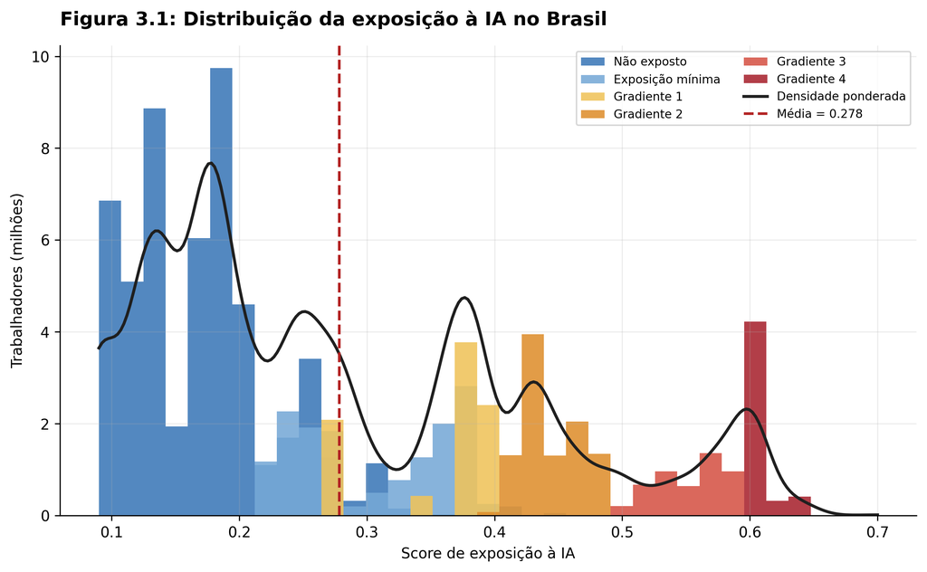

Figure 3.1 — Distribution of AI exposure in Brazil

#### 2.4.0.2 Figure 3.2 — Employed population by AI exposure gradient

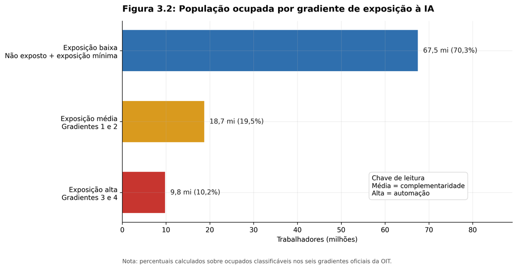

Figure 3.2 — Employed population by AI exposure gradient

#### 2.4.0.3 Figure 3.3 — Occupational composition by AI exposure score

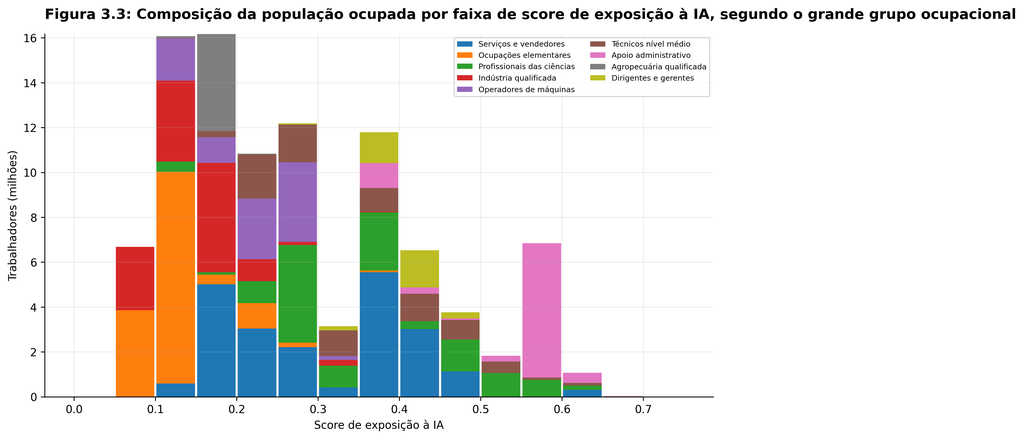

Figure 3.3 — Occupational composition by AI exposure score

#### 2.4.0.4 Figure 3.4 — High AI exposure by state

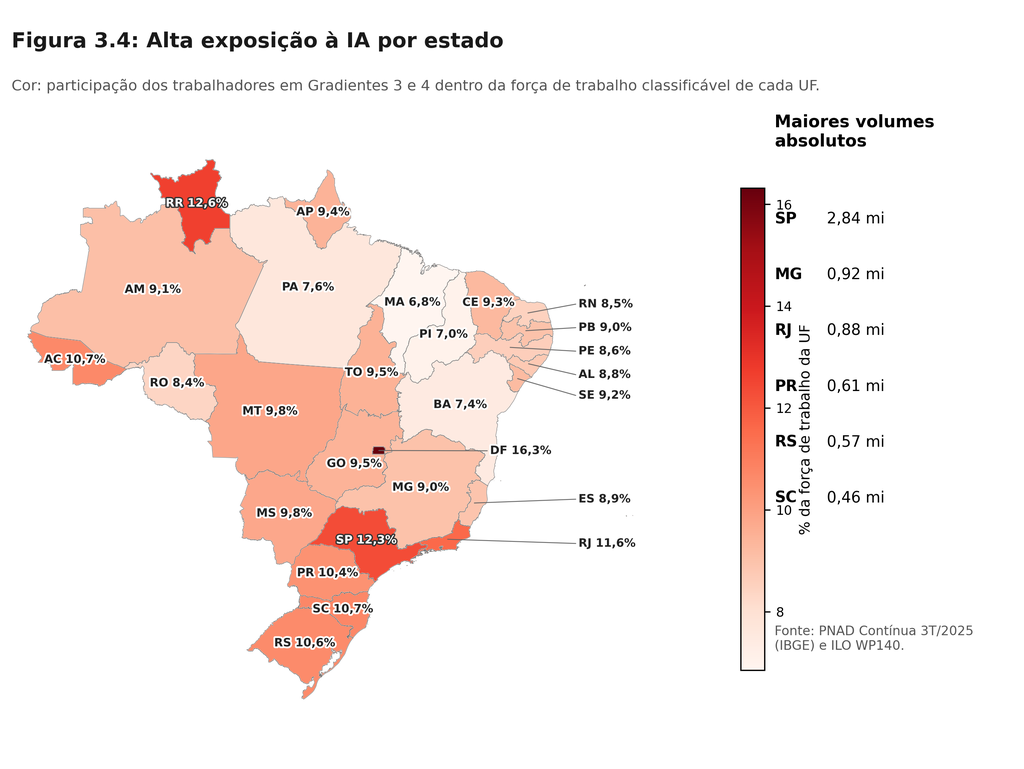

Figure 3.4 — High AI exposure by state

#### 2.4.0.5 Figure 3.5 — AI exposure by sex

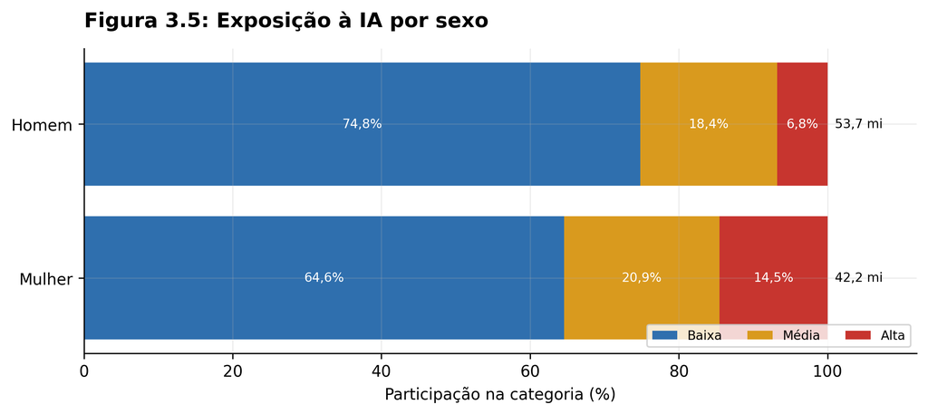

Figure 3.5 — AI exposure by sex

#### 2.4.0.6 Figure 3.6 — AI exposure by race or color

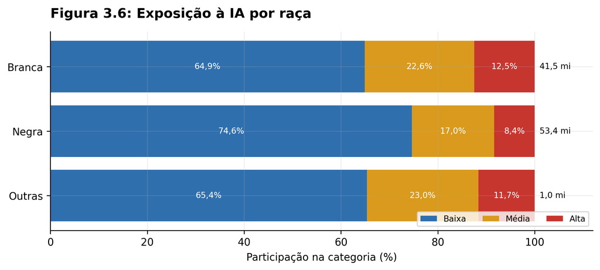

Figure 3.6 — AI exposure by race or color

#### 2.4.0.7 Figure 3.7 — AI exposure by age group

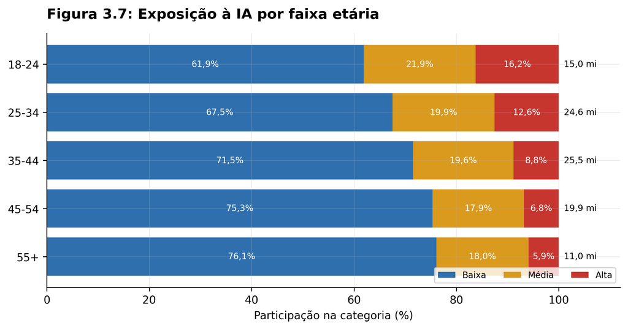

Figure 3.7 — AI exposure by age group

#### 2.4.0.8 Figure 3.8 — AI exposure by education

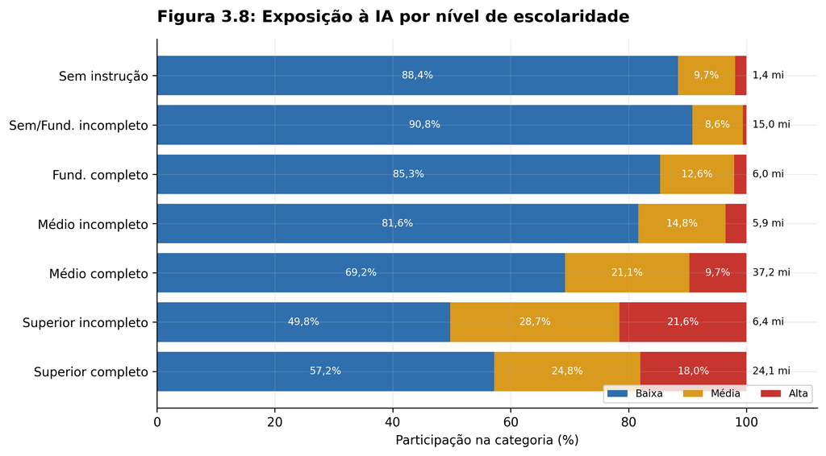

Figure 3.8 — AI exposure by education

#### 2.4.0.9 Figure 3.9 — AI exposure by income group

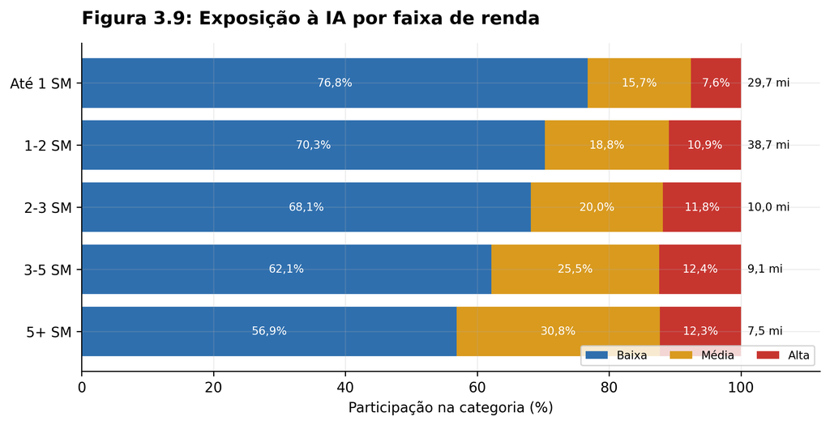

Figure 3.9 — AI exposure by income group

#### 2.4.0.10 Figure 3.10 — AI exposure by formality status

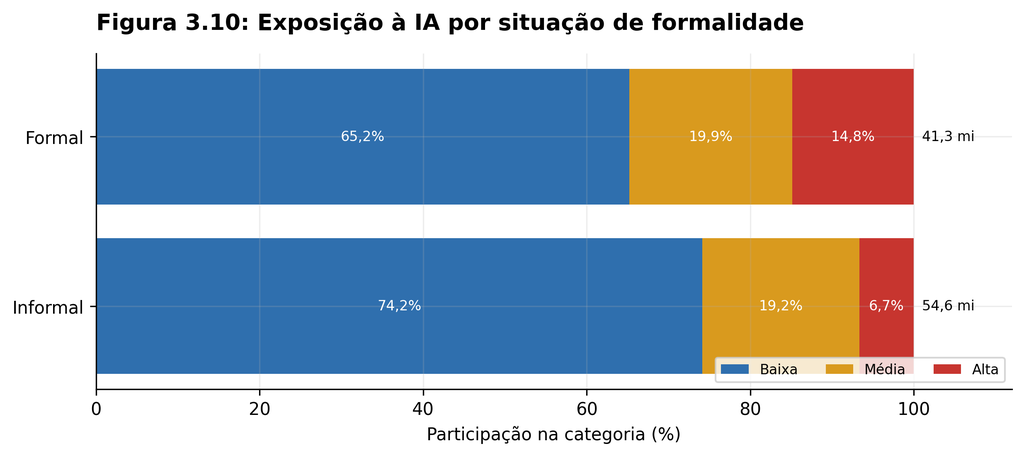

Figure 3.10 — AI exposure by formality status

# 3 Estratégia empírica e painel CAGED (Seção 4)

## 3.1 De registros administrativos ao painel ocupação-mês

O CAGED não entra diretamente em uma regressão. Primeiro, os arquivos da safra são reconciliados por competência: movimentos regulares (`MOV`) e declarações fora do prazo (`FOR`) entram com peso positivo; exclusões (`EXC`) entram com peso negativo. Depois, os registros são agregados para ocupação CBO de quatro dígitos por mês e recebem a classificação de exposição, deflação pelo IPCA e controles de composição.

**Código exibido apenas para leitura.** A reconstrução bruta do CAGED usa 195 arquivos oficiais e deliberadamente não é executada de novo aqui. A fonte canônica em Python é mostrada porque é o código de produção da construção dos dados; o código R abaixo trabalha a partir da entrada analítica compacta de ocupação-mês.

### 3.1.1 Regra de sinais na reconstrução

```python
def prepare_archive_frame(
    frame: pd.DataFrame,
    archive_type: str,
    competencia_arquivo: str,
) -> pd.DataFrame:
    """Apply source metadata and enforce fact-time relationships."""
    if archive_type not in {"MOV", "FOR", "EXC"}:
        raise ValueError(f"Unexpected archive type: {archive_type}")
    if not frame["competenciamov"].str.fullmatch(r"\d{6}").all():
        raise ValueError("competenciamov must contain six-digit YYYYMM values")

    if archive_type == "MOV":
        invalid = frame["competenciamov"].ne(competencia_arquivo)
        if invalid.any():
            raise ValueError(
                f"MOV facts must equal file month {competencia_arquivo}; "
                f"found {int(invalid.sum())} violations"
            )
    elif archive_type == "FOR":
        invalid = frame["competenciamov"].ge(competencia_arquivo)
        if invalid.any():
            raise ValueError(
                f"FOR facts must be strictly earlier than file month "
                f"{competencia_arquivo}; found {int(invalid.sum())} violations"
            )
    else:
        invalid = frame["competenciamov"].gt(competencia_arquivo)
        if invalid.any():
            raise ValueError(
                f"EXC facts cannot be later than file month "
                f"{competencia_arquivo}; found {int(invalid.sum())} violations"
            )

    prepared = frame.copy()
    for column in set(EXCLUSION_COLUMNS) - set(prepared.columns):
        prepared[column] = pd.NA
    prepared["origem"] = archive_type
    prepared["competencia_arquivo"] = competencia_arquivo
    prepared["peso"] = -1 if archive_type == "EXC" else 1
    for column in STRING_COLUMNS:
        prepared[column] = prepared[column].astype("string")
    prepared["peso"] = prepared["peso"].astype("int8")
    return prepared[["competenciamov", *OUTPUT_COLUMNS]]


def _table_from_group(group: pd.DataFrame) -> pa.Table:
    return pa.Table.from_pandas(
        group[list(OUTPUT_COLUMNS)],
        schema=ARROW_SCHEMA,
        preserve_index=False,
        safe=True,
    )


def _write_reconciliation(
    counters: dict[str, Counter[str]],
    path: Path,
) -> None:
    path.parent.mkdir(parents=True, exist_ok=True)
    fieldnames = (
        "competenciamov",
        "linhas_mov",
        "linhas_for",
        "linhas_exc",
        "linhas_exc_mesmo_mes",
        "liquido",
    )
    with path.open("w", encoding="utf-8", newline="") as handle:
        writer = csv.DictWriter(
            handle,
            fieldnames=fieldnames,
            lineterminator="\n",
        )
        writer.writeheader()
        for competencia in sorted(counters):
            counts = counters[competencia]
            writer.writerow(
                {
                    "competenciamov": competencia,
                    "linhas_mov": counts["MOV"],
                    "linhas_for": counts["FOR"],
                    "linhas_exc": counts["EXC"],
                    "linhas_exc_mesmo_mes": counts["EXC_SAME_MONTH"],
                    "liquido": (
                        counts["MOV"] + counts["FOR"] - counts["EXC"]
                    ),
                }
            )


def _directory_size(path: Path) -> int:
    return sum(
        file_path.stat().st_size
        for file_path in path.rglob("*")
        if file_path.is_file()
    )


def build_movements(
    records: Sequence[dict[str, object]],
    vintage_dir: Path,
    output_dir: Path,
    reconciliation_path: Path,
    *,
    parser: Parser = parse_archive,
) -> dict[str, int]:
    """Build one atomic partitioned dataset from the frozen archives."""
    if output_dir.exists():
        raise FileExistsError(
            f"Output already exists; refusing to overwrite: {output_dir}"
        )
    building_dir = output_dir.with_name(f"{output_dir.name}.building")
    if building_dir.exists():
        raise FileExistsError(
            f"Previous incomplete build exists: {building_dir}"
        )
    building_dir.mkdir(parents=True)

    writers: dict[str, pq.ParquetWriter] = {}
    counters: dict[str, Counter[str]] = defaultdict(Counter)
    total_exclusion_rows = 0
    negative_weight_rows = 0

    try:
        for index, record in enumerate(records, start=1):
            archive_type = str(record["tipo"])
            competencia_arquivo = str(record["competencia"])
            filename = Path(urlparse(str(record["url"])).path).name
            archive_path = vintage_dir / filename
            if not archive_path.is_file():
                raise FileNotFoundError(archive_path)
            print(
                f"[{index}/{len(records)}] parse {filename}",
                flush=True,
            )
            frame = parser(archive_path)
            prepared = prepare_archive_frame(
                frame,
                archive_type,
                competencia_arquivo,
            )
            if archive_type == "EXC":
                total_exclusion_rows += len(prepared)
                negative_weight_rows += int(prepared["peso"].eq(-1).sum())

            if archive_type == "MOV":
                archive_groups = (
                    (competencia_arquivo, prepared),
                )
            else:
                archive_groups = prepared.groupby(
                    "competenciamov",
                    sort=False,
                    observed=True,
                )
            for competencia, group in archive_groups:
                competencia_text = str(competencia)
                partition_dir = (
                    building_dir
                    / f"competenciamov={competencia_text}"
                )
                partition_dir.mkdir(parents=True, exist_ok=True)
                writer = writers.get(competencia_text)
                if writer is None:
                    writer = pq.ParquetWriter(
                        partition_dir / "part.parquet",
                        ARROW_SCHEMA,
                        compression="zstd",
                        compression_level=3,
                        use_dictionary=True,
                    )
                    writers[competencia_text] = writer
                writer.write_table(_table_from_group(group))
                counters[competencia_text][archive_type] += len(group)
                if (
                    archive_type == "EXC"
                    and competencia_text == competencia_arquivo
                ):
                    counters[competencia_text]["EXC_SAME_MONTH"] += len(group)

            del frame, prepared
            gc.collect()
    finally:
        for writer in writers.values():
            writer.close()

    if negative_weight_rows != total_exclusion_rows:
        raise RuntimeError(
            "Negative weights do not match processed EXC rows: "
            f"{negative_weight_rows} != {total_exclusion_rows}"
        )

    if len(records) == 195:
        required = pd.period_range("2021-01", "2026-05", freq="M").strftime(
            "%Y%m"
        )
        missing = sorted(set(required) - set(counters))
        if missing:
            raise RuntimeError(f"Missing fact-month partitions: {missing}")

    _write_reconciliation(counters, reconciliation_path)
    os.replace(building_dir, output_dir)
    metrics = {
        "archives_processed": len(records),
        "partitions_written": len(counters),
        "total_exclusion_rows": total_exclusion_rows,
        "negative_weight_rows": negative_weight_rows,
        "output_bytes": _directory_size(output_dir),
    }
    metrics_path = reconciliation_path.with_name(
        "build_movements_metrics.json"
    )
    metrics_path.write_text(
        json.dumps(metrics, indent=2, sort_keys=True) + "\n",
        encoding="utf-8",
    )
    return metrics
```

Em linguagem R, a mesma lógica de auditoria pode ser lida assim. Este bloco é um espelho didático — a implementação canônica acima é a que registra hashes, schemas e partições.

```r
# Pedagogical translation; not the canonical raw-data builder.
movements <- rbindlist(list(mov, late_filings, exclusions), use.names = TRUE, fill = TRUE)
movements[, weight := fifelse(origin == "EXC", -1, 1)]
movements[, signed_admissions := weight * (movement_type == "admission")]
movements[, signed_separations := weight * (movement_type == "separation")]

panel_cbo_month <- movements[, .(
  admissoes = sum(signed_admissions),
  desligamentos = sum(signed_separations),
  n_movimentacoes = .N
), by = .(cbo_4d, periodo)]
```

### 3.1.2 Construção do painel e variáveis analíticas

```python
def _aggregate_national(
    connection: duckdb.DuckDBPyConnection,
) -> pd.DataFrame:
    connection.execute(
        """
        CREATE TEMP TABLE wage_bounds AS
        SELECT
            cbo_4d,
            ano,
            approx_quantile(salario, 0.01) AS wage_p01,
            approx_quantile(salario, 0.99) AS wage_p99
        FROM valid_movements
        WHERE peso = 1
        GROUP BY cbo_4d, ano
        """
    )
    return connection.execute(
        f"""
        WITH winsorized AS (
            SELECT
                movement.*,
                greatest(
                    bounds.wage_p01,
                    least(movement.salario, bounds.wage_p99)
                ) AS salario_winsor
            FROM valid_movements AS movement
            INNER JOIN wage_bounds AS bounds
              USING (cbo_4d, ano)
        ),
        totals AS (
            SELECT
                cbo_4d,
                periodo_num,
                CAST(sum(
                    CASE WHEN movimento = 1 THEN peso ELSE 0 END
                ) AS BIGINT) AS admissoes,
                CAST(sum(
                    CASE WHEN movimento = -1 THEN peso ELSE 0 END
                ) AS BIGINT) AS desligamentos,
                sum(CASE
                    WHEN movimento = 1
                    THEN peso * salario_winsor
                    ELSE 0
                END) AS salario_soma_adm,
                sum(CASE
                    WHEN movimento = -1
                    THEN peso * salario_winsor
                    ELSE 0
                END) AS salario_soma_desl,
                sum(CASE
                    WHEN movimento = 1 THEN peso * idade ELSE 0
                END) AS idade_soma_adm,
                sum(CASE
                    WHEN movimento = -1 THEN peso * idade ELSE 0
                END) AS idade_soma_desl,
                sum(CASE
                    WHEN movimento = 1 AND sexo = '3' THEN peso
                    ELSE 0
                END) AS mulher_soma_adm,
                sum(CASE
                    WHEN movimento = -1 AND sexo = '3' THEN peso
                    ELSE 0
                END) AS mulher_soma_desl,
                sum(CASE
                    WHEN movimento = 1
                     AND graudeinstrucao IN ({COMPLETE_HIGHER_EDUCATION_SQL})
                    THEN peso ELSE 0
                END) AS superior_soma_adm,
                sum(CASE
                    WHEN movimento = -1
                     AND graudeinstrucao IN ({COMPLETE_HIGHER_EDUCATION_SQL})
                    THEN peso ELSE 0
                END) AS superior_soma_desl,
                sum(CASE
                    WHEN movimento = 1 AND racacor IN ('2', '3')
                    THEN peso ELSE 0
                END) AS negra_soma_adm,
                sum(CASE
                    WHEN movimento = -1 AND racacor IN ('2', '3')
                    THEN peso ELSE 0
                END) AS negra_soma_desl
            FROM winsorized
            GROUP BY cbo_4d, periodo_num
        )
        SELECT
            cbo_4d,
            CAST(floor(periodo_num / 100) AS INTEGER) AS ano,
            CAST(periodo_num % 100 AS INTEGER) AS mes,
            periodo_num,
            admissoes,
            desligamentos,
            admissoes - desligamentos AS saldo,
            admissoes + desligamentos AS n_movimentacoes,
            CASE WHEN admissoes > 0
                 THEN salario_soma_adm / admissoes END
                AS salario_medio_adm,
            CASE WHEN desligamentos > 0
                 THEN salario_soma_desl / desligamentos END
                AS salario_medio_desl,
            CASE WHEN admissoes > 0
                 THEN idade_soma_adm / admissoes END
                AS idade_media_adm,
            CASE WHEN desligamentos > 0
                 THEN idade_soma_desl / desligamentos END
                AS idade_media_desl,
            CASE WHEN admissoes > 0
                 THEN mulher_soma_adm / admissoes END
                AS pct_mulher_adm,
            CASE WHEN desligamentos > 0
                 THEN mulher_soma_desl / desligamentos END
                AS pct_mulher_desl,
            CASE WHEN admissoes > 0
                 THEN superior_soma_adm / admissoes END
                AS pct_superior_adm,
            CASE WHEN desligamentos > 0
                 THEN superior_soma_desl / desligamentos END
                AS pct_superior_desl,
            CASE WHEN admissoes > 0
                 THEN negra_soma_adm / admissoes END
                AS pct_negra_adm,
            CASE WHEN desligamentos > 0
                 THEN negra_soma_desl / desligamentos END
                AS pct_negra_desl
        FROM totals
        WHERE admissoes >= 0
          AND desligamentos >= 0
          AND (admissoes > 0 OR desligamentos > 0)
        ORDER BY cbo_4d, periodo_num
        """
    ).df()
```

```python
def _attach_panel_fields(
    panel: pd.DataFrame,
    ipca: pd.DataFrame,
    classification: pd.DataFrame,
) -> tuple[pd.DataFrame, list[str]]:
    required_ipca = {"periodo_num", "indice"}
    missing_ipca = sorted(required_ipca - set(ipca.columns))
    if missing_ipca:
        raise ValueError(f"IPCA input is missing columns: {missing_ipca}")
    if ipca["periodo_num"].duplicated().any():
        raise RuntimeError("IPCA input has duplicate months")
    out = audited_merge(
        panel,
        ipca[["periodo_num", "indice"]],
        merge_id="national_panel_attach_ipca",
        on="periodo_num",
        how="left",
        validate="many_to_one",
    )
    if out["indice"].isna().any() or (out["indice"] <= 0).any():
        missing = sorted(
            out.loc[out["indice"].isna(), "periodo_num"].unique()
        )
        raise RuntimeError(f"Missing IPCA for panel months: {missing}")

    required_classification = {"cbo_4d", "cbo_ilo_gradient"}
    missing_classification = sorted(
        required_classification - set(classification.columns)
    )
    if missing_classification:
        raise ValueError(
            "Classification input is missing columns: "
            f"{missing_classification}"
        )
    classes = classification[
        ["cbo_4d", "cbo_ilo_gradient"]
    ].copy()
    classes["cbo_4d"] = classes["cbo_4d"].astype(str).str.zfill(4)
    out = audited_merge(
        out,
        classes,
        merge_id="national_panel_attach_treatment",
        on="cbo_4d",
        how="left",
        validate="many_to_one",
    )
    new_unclassified = sorted(
        out.loc[out["cbo_ilo_gradient"].isna(), "cbo_4d"].unique()
    )
    out["cbo_ilo_gradient"] = out["cbo_ilo_gradient"].fillna("No score")

    exposed = out["cbo_ilo_gradient"].isin(
        [
            "Exposed: Gradient 1",
            "Exposed: Gradient 2",
            "Exposed: Gradient 3",
            "Exposed: Gradient 4",
        ]
    )
    control = out["cbo_ilo_gradient"].eq("Not Exposed")
    out["treated_main"] = np.where(
        exposed, 1.0, np.where(control, 0.0, np.nan)
    )
    out["included_main"] = exposed | control
    out["periodo"] = (
        out["ano"].astype(str)
        + "-"
        + out["mes"].astype(str).str.zfill(2)
    )
    out["post"] = out["periodo_num"].ge(202212).astype("int8")
    out["salario_real_adm"] = (
        out["salario_medio_adm"] * 100.0 / out["indice"]
    )
    out["salario_real_desl"] = (
        out["salario_medio_desl"] * 100.0 / out["indice"]
    )
    out["ln_admissoes"] = np.log1p(out["admissoes"])
    out["ln_desligamentos"] = np.log1p(out["desligamentos"])
    out["ln_salario_real_adm"] = np.log(out["salario_real_adm"])
    out["ln_salario_real_desl"] = np.log(out["salario_real_desl"])
    out["asinh_saldo"] = np.arcsinh(out["saldo"])
    return (
        out.sort_values(["cbo_4d", "periodo_num"]).reset_index(drop=True),
        new_unclassified,
    )


def build_national_panel(
    movements_glob: Path,
    ipca: pd.DataFrame,
    classification: pd.DataFrame,
    *,
    start_period: int = START_PERIOD,
    end_period: int = END_PERIOD,
    scratch_parent: Path = DEFAULT_SCRATCH_PARENT,
) -> tuple[pd.DataFrame, dict[str, Any]]:
    scratch_parent.mkdir(parents=True, exist_ok=True)
    with tempfile.TemporaryDirectory(
        prefix="t12-duckdb-",
        dir=scratch_parent,
    ) as temporary:
        temp_directory = Path(temporary)
        connection = duckdb.connect()
        try:
            _configure_connection(connection, temp_directory)
            _create_movement_views(
                connection,
                movements_glob,
                start_period,
                end_period,
            )
            counts = connection.execute(
                """
                SELECT
                    (SELECT count(*) FROM analytic_source) AS raw_rows,
                    (SELECT count(*) FROM valid_movements) AS valid_rows
                """
            ).fetchone()
            bounds_count = connection.execute(
                """
                SELECT count(*) FROM (
                    SELECT cbo_4d, ano
                    FROM valid_movements
                    WHERE peso = 1
                    GROUP BY cbo_4d, ano
                )
                """
            ).fetchone()[0]
            panel = _aggregate_national(connection)
        finally:
            connection.close()

    panel, new_unclassified = _attach_panel_fields(
        panel, ipca, classification
    )
    validate_national_panel(panel)
    months_by_cbo = panel.groupby("cbo_4d")["periodo_num"].nunique()
    metrics = {
        "raw_rows": int(counts[0]),
        "valid_rows": int(counts[1]),
        "invalid_rows_rejected": int(counts[0] - counts[1]),
        "cells": int(len(panel)),
        "cbo_families": int(panel["cbo_4d"].nunique()),
        "new_unclassified_cbo_families": new_unclassified,
        "months": int(panel["periodo_num"].nunique()),
        "months_per_cbo_min": int(months_by_cbo.min()),
        "months_per_cbo_max": int(months_by_cbo.max()),
        "zero_admission_cells": int(panel["admissoes"].eq(0).sum()),
        "zero_separation_cells": int(
            panel["desligamentos"].eq(0).sum()
        ),
        "max_admission_wage": float(
            panel["salario_medio_adm"].max(skipna=True)
        ),
        "max_separation_wage": float(
            panel["salario_medio_desl"].max(skipna=True)
        ),
        "wage_bound_groups": int(bounds_count),
        "wage_winsorization": (
            "record-level DuckDB approx_quantile P1/P99 "
            "within CBO4 x year, positive-weight records"
        ),
    }
    return panel, metrics
```

## 3.2 Escopo, tratamento e variáveis de resultado

**Carregado da referência assinada do V2.** Estas tabelas documentam o escopo exato do painel, a classificação de tratamento, a cobertura e as definições dos desfechos usados pelo V2.

table 4 2 1 panel scope

| indicator | value | source |
| --- | --- | --- |
| Células CBO-mês no painel nacional observado | 39742 | results/reconciliation/painel_nacional_support.json |
| Células CBO-mês na amostra principal completa | 22049 | results/models/specification_ladder.csv |
| CBOs na amostra principal | 341 | results/models/specification_ladder.csv |
| Meses | 65 | results/reconciliation/painel_nacional_support.json |
| Janela | 2021-01 a 2026-05 | results/reconciliation/painel_nacional_support.json |
| CBOs tratadas / controle | 75 / 266 | results/treatment/treatment_variant_comparison.csv |

table 4 2 2 treatment classification

| variant | classification | cbo_families | changed_vs_v_a | analysis_role | source |
| --- | --- | --- | --- | --- | --- |
| V-A | Exposed: Gradient 4 | 0 | 0 | treated | results/treatment/treatment_variant_comparison.csv |
| V-A | Exposed: Gradient 3 | 31 | 0 | treated | results/treatment/treatment_variant_comparison.csv |
| V-A | Exposed: Gradient 2 | 31 | 0 | treated | results/treatment/treatment_variant_comparison.csv |
| V-A | Exposed: Gradient 1 | 13 | 0 | treated | results/treatment/treatment_variant_comparison.csv |
| V-A | Minimal Exposure | 95 | 0 | excluded from principal contrast | results/treatment/treatment_variant_comparison.csv |
| V-A | Not Exposed | 266 | 0 | control | results/treatment/treatment_variant_comparison.csv |
| V-A | No score | 193 | 0 | excluded from principal contrast | results/treatment/treatment_variant_comparison.csv |
| V-B | Exposed: Gradient 4 | 0 | 8 | treated | results/treatment/treatment_variant_comparison.csv |
| V-B | Exposed: Gradient 3 | 30 | 8 | treated | results/treatment/treatment_variant_comparison.csv |
| V-B | Exposed: Gradient 2 | 32 | 8 | treated | results/treatment/treatment_variant_comparison.csv |
| V-B | Exposed: Gradient 1 | 11 | 8 | treated | results/treatment/treatment_variant_comparison.csv |
| V-B | Minimal Exposure | 96 | 8 | excluded from principal contrast | results/treatment/treatment_variant_comparison.csv |
| V-B | Not Exposed | 267 | 8 | control | results/treatment/treatment_variant_comparison.csv |
| V-B | No score | 193 | 8 | excluded from principal contrast | results/treatment/treatment_variant_comparison.csv |
| V-C | Exposed: Gradient 4 | 0 | 16 | treated | results/treatment/treatment_variant_comparison.csv |
| V-C | Exposed: Gradient 3 | 31 | 16 | treated | results/treatment/treatment_variant_comparison.csv |
| V-C | Exposed: Gradient 2 | 27 | 16 | treated | results/treatment/treatment_variant_comparison.csv |
| V-C | Exposed: Gradient 1 | 8 | 16 | treated | results/treatment/treatment_variant_comparison.csv |
| V-C | Minimal Exposure | 97 | 16 | excluded from principal contrast | results/treatment/treatment_variant_comparison.csv |
| V-C | Not Exposed | 273 | 16 | control | results/treatment/treatment_variant_comparison.csv |
| V-C | No score | 193 | 16 | excluded from principal contrast | results/treatment/treatment_variant_comparison.csv |
| V-D | Exposed: Gradient 4 | 3 | 53 | treated | results/treatment/treatment_variant_comparison.csv |
| V-D | Exposed: Gradient 3 | 20 | 53 | treated | results/treatment/treatment_variant_comparison.csv |
| V-D | Exposed: Gradient 2 | 37 | 53 | treated | results/treatment/treatment_variant_comparison.csv |
| V-D | Exposed: Gradient 1 | 7 | 53 | treated | results/treatment/treatment_variant_comparison.csv |
| V-D | Minimal Exposure | 79 | 53 | excluded from principal contrast | results/treatment/treatment_variant_comparison.csv |
| V-D | Not Exposed | 290 | 53 | control | results/treatment/treatment_variant_comparison.csv |
| V-D | No score | 193 | 53 | excluded from principal contrast | results/treatment/treatment_variant_comparison.csv |

table 4 2 3 panel coverage

| treatment_group | months | movement_rows | late_rows | excluded_rows | mean_late_share_pct | min_late_share_pct | max_late_share_pct | source |
| --- | --- | --- | --- | --- | --- | --- | --- | --- |
| control | 65 | 101046438 | 2602699 | 200904 | 2.8174 | 0 | 11.9626 | results/reconciliation/completude_por_tratamento.csv |
| treated | 65 | 53055976 | 1201944 | 111356 | 2.4327 | 0 | 10.8715 | results/reconciliation/completude_por_tratamento.csv |

table 4 3 1 outcomes

| group | outcome_id | outcome | definition | transformation_and_estimator | coefficient_interpretation | verified_estimator | source |
| --- | --- | --- | --- | --- | --- | --- | --- |
| Fluxos | admissoes | Admissões (PPML, nível) | Número de admissões formais na CBO-mês | PPML sobre a contagem em nível | Semi-elasticidade; não é log-log | ppml | results/models/specification_ladder.csv |
| Fluxos | desligamentos | Desligamentos (PPML, nível) | Número de desligamentos formais na CBO-mês | PPML sobre a contagem em nível | Semi-elasticidade; não é log-log | ppml | results/models/specification_ladder.csv |
| Fluxos | n_movimentacoes | Fluxo bruto (PPML, nível) | Admissões mais desligamentos na CBO-mês | PPML sobre a contagem em nível | Semi-elasticidade; não é log-log | ppml | results/models/specification_ladder.csv |
| Salários | ln_salario_real_adm | Salário real de admissão (log) | Salário médio de admissão deflacionado pelo IPCA | Log; OLS | Diferença aproximada em proporção | ols | results/models/specification_ladder.csv |
| Saldo | asinh_saldo | Saldo líquido (asinh) | Admissões menos desligamentos na CBO-mês | asinh; OLS | Não interpretar como percentual | ols | results/models/specification_ladder.csv |

## 3.3 Entrada analítica compacta usada neste guia

O arquivo abaixo é a versão compacta, sem coeficientes do Python, usada para a réplica independente em R dos modelos nacionais. Ele é suficiente para mostrar a construção de uma amostra de ocupação-mês, a estrutura dos efeitos fixos e os cinco modelos estáticos principais, sem carregar o painel setorial ou os painéis de heterogeneidade.

```r
caged_input <- fread(file.path(bundle_root, "derived", "cross_replication_input.csv"))
caged_input[, `:=`(
  cbo_4d = factor(cbo_4d),
  periodo = factor(periodo)
)]

kableExtra::kbl(
  as.data.frame(compact_summary(
    caged_input,
    c("cbo_4d", "periodo", "post", "treatment", "post_treat", "admissoes", "desligamentos", "ln_salario_real_adm", "asinh_saldo")
  )),
  format = "html",
  caption = "Structure of the compact CAGED analytical input"
) |>
  kableExtra::kable_styling(full_width = FALSE, bootstrap_options = c("striped", "condensed")) |>
  print()
```

Structure of the compact CAGED analytical input

| variable | missing | unique_values | class |
| --- | --- | --- | --- |
| cbo_4d | 0 | 341 | factor |
| periodo | 0 | 65 | factor |
| post | 0 | 2 | integer |
| treatment | 0 | 2 | integer |
| post_treat | 0 | 2 | integer |
| admissoes | 0 | 6225 | integer |
| desligamentos | 0 | 6128 | integer |
| ln_salario_real_adm | 37 | 22010 | numeric |
| asinh_saldo | 0 | 3600 | numeric |

```r
caged_input[, .(
  occupation_month_cells = .N,
  occupations = uniqueN(cbo_4d),
  months = uniqueN(periodo),
  treated_occupations = uniqueN(cbo_4d[treatment == 1L]),
  control_occupations = uniqueN(cbo_4d[treatment == 0L]),
  post_months = uniqueN(periodo[post == 1L])
)]
```

| occupation_month_cells | occupations | months | treated_occupations | control_occupations | post_months |
| --- | --- | --- | --- | --- | --- |
| 22049 | 341 | 65 | 75 | 266 | 42 |

## 3.4 Diferenças-em-diferenças: equação e implementação em R

Para uma ocupação $o$ no mês $t$, a especificação nacional estática é:

$$g\{Y_{ot}\} = \beta (Post_t \times Treated_o) + \alpha_o + \lambda_t +
\varepsilon_{ot}.$$

Para fluxos contados, $g(\cdot)$ é o log-link de uma PPML; para `ln_salario_real_adm` e `asinh_saldo`, o modelo é OLS. Os efeitos fixos são de ocupação e mês; os erros-padrão são agrupados por ocupação.

**Executado neste documento.** As cinco especificações nacionais estáticas a seguir são reestimadas a partir da entrada CAGED compacta e sem coeficientes. Isso é um apoio de leitura, não um substituto para a DAG completa do V2.

```r
fit_caged_static <- function(data, outcome, estimator) {
  formula <- as.formula(
    paste(outcome, "~ post_treat | cbo_4d + periodo")
  )
  fit <- if (identical(estimator, "ppml")) {
    fepois(
      formula,
      data = data,
      vcov = ~cbo_4d,
      fixef.rm = "perfect_fit",
      warn = TRUE
    )
  } else {
    feols(
      formula,
      data = data,
      vcov = ~cbo_4d,
      fixef.rm = "perfect_fit",
      warn = TRUE
    )
  }
  data.table(
    outcome = outcome,
    estimator = estimator,
    coefficient = unname(coef(fit)[["post_treat"]]),
    standard_error = unname(se(fit)[["post_treat"]]),
    n_obs = as.integer(nobs(fit)),
    n_clusters = uniqueN(data$cbo_4d)
  )
}

caged_specs <- data.table(
  outcome = c(
    "admissoes", "desligamentos", "n_movimentacoes",
    "ln_salario_real_adm", "asinh_saldo"
  ),
  estimator = c("ppml", "ppml", "ppml", "ols", "ols")
)
caged_light_results <- rbindlist(
  Map(fit_caged_static, list(caged_input), caged_specs$outcome, caged_specs$estimator)
)
caged_light_results
```

| outcome | estimator | coefficient | standard_error | n_obs | n_clusters |
| --- | --- | --- | --- | --- | --- |
| admissoes | ppml | -0.05377240 | 0.03856021 | 22049 | 341 |
| desligamentos | ppml | -0.04201407 | 0.03470152 | 22049 | 341 |
| n_movimentacoes | ppml | -0.04809316 | 0.03533672 | 22049 | 341 |
| ln_salario_real_adm | ols | -0.05074045 | 0.01033236 | 22012 | 341 |
| asinh_saldo | ols | -0.55126689 | 0.37831661 | 22049 | 341 |

Light R re-estimation compared with the signed no-controls specification

| outcome | estimator | coefficient | standard_error | n_obs | n_clusters | reference_coefficient | reference_standard_error | coefficient_difference | standard_error_difference | comparison_pass |
| --- | --- | --- | --- | --- | --- | --- | --- | --- | --- | --- |
| admissoes | ppml | -0.05377240 | 0.03856021 | 22049 | 341 | -0.05377240 | 0.03856021 | 0 | 0.0000000000 | TRUE |
| asinh_saldo | ols | -0.55126689 | 0.37831661 | 22049 | 341 | -0.55126689 | 0.37831661 | 0 | 0.0000000000 | TRUE |
| desligamentos | ppml | -0.04201407 | 0.03470152 | 22049 | 341 | -0.04201407 | 0.03470152 | 0 | 0.0000000000 | TRUE |
| ln_salario_real_adm | ols | -0.05074045 | 0.01033236 | 22012 | 341 | -0.05074045 | 0.01033236 | 0 | 0.0000000000 | TRUE |
| n_movimentacoes | ppml | -0.04809316 | 0.03533672 | 22049 | 341 | -0.04809316 | 0.03533672 | 0 | -0.0000000003 | TRUE |

## 3.5 A implementação independente completa em R

O V2 também contém uma réplica independente muito mais ampla. Ela recebe contratos de modelo e entradas analíticas sem coeficientes do Python, estima em `fixest` e compara identificadores de modelo, termos, coeficientes, erros-padrão, tamanho de amostra, clusters e referência temporal. Abaixo está o começo desse script; o guia não o executa porque envolve 646 contratos e os painéis analíticos completos.

**Código exibido apenas para leitura.** A réplica independente completa em R é mostrada para inspeção. Ela não é executada a partir deste guia.

```r
#!/usr/bin/env Rscript

suppressPackageStartupMessages({
  library(data.table)
  library(fixest)
  library(jsonlite)
  library(MASS)
})

setFixest_notes(FALSE)

# The --contracts argument points to the generated model_contracts.csv file.
arguments <- commandArgs(trailingOnly = TRUE)

argument_value <- function(flag) {
  position <- match(flag, arguments)
  if (is.na(position) || position == length(arguments)) {
    stop("Missing required argument: ", flag)
  }
  arguments[[position + 1L]]
}

contract_path <- normalizePath(
  argument_value("--contracts"),
  mustWork = TRUE
)
input_dir <- normalizePath(
  argument_value("--input-dir"),
  mustWork = TRUE
)
output_dir <- argument_value("--output-dir")
dir.create(output_dir, recursive = TRUE, showWarnings = FALSE)

if (paste(R.version$major, R.version$minor, sep = ".") != "4.4.1") {
  stop("The locked replication runtime requires R 4.4.1.")
}

contracts <- fread(contract_path, na.strings = c("", "NA"))
forbidden_contract_columns <- c(
  "coefficient",
  "standard_error",
  "python_coefficient",
  "python_standard_error"
)
if (length(intersect(names(contracts), forbidden_contract_columns)) > 0L) {
  stop("Model contracts must not contain Python estimates.")
}
if (anyDuplicated(contracts$model_id)) {
  stop("Model identifiers are not unique.")
}

data_cache <- new.env(parent = emptyenv())

load_input <- function(filename) {
  if (!exists(filename, envir = data_cache, inherits = FALSE)) {
    path <- file.path(input_dir, filename)
    if (!file.exists(path)) {
      stop("Analytical input is missing: ", path)
    }
    assign(filename, fread(path), envir = data_cache)
  }
  get(filename, envir = data_cache, inherits = FALSE)
}

subset_for_contract <- function(data, contract) {
  expression <- parse(text = contract$sample_filter)[[1L]]
  keep <- eval(expression, envir = data, enclos = parent.frame())
  if (length(keep) == 1L && isTRUE(keep)) {
    sample <- copy(data)
  } else {
    if (length(keep) != nrow(data) || anyNA(keep)) {
      stop("Invalid sample filter for ", contract$model_id)
    }
    sample <- data[keep]
  }
  if (contract$model_type == "event") {
    sample <- sample[
      event_time >= as.integer(contract$event_min)
        & event_time <= as.integer(contract$event_max)
    ]
  }
  if (nrow(sample) == 0L) {
    stop("Model sample is empty for ", contract$model_id)
  }
  sample
}

fit_contract <- function(contract, sample) {
  formula <- as.formula(contract$formula)
  cluster_formula <- as.formula(
    paste0("~", contract$cluster_variables)
  )
  # Keep fixed-effect absorption at pyfixest's declared tolerance. fixest and
  # pyfixest use different IWLS stopping statistics, so the stricter R rule
  # below is needed for their independently computed clustered sandwich
  # matrices to satisfy the public 1e-6 contract. It does not use a Python
  # coefficient, standard error, or fitted value.
  if (contract$estimator == "ppml") {
    model <- fepois(
      formula,
      data = sample,
      fixef.rm = "perfect_fit",
      fixef.tol = 1e-8,
      fixef.iter = 100000,
      glm.tol = 1e-9,
      warn = TRUE
    )
  } else if (contract$estimator == "ols") {
    model <- feols(
      formula,
      data = sample,
      fixef.rm = "perfect_fit",
      fixef.tol = 1e-8,
      fixef.iter = 100000,
      warn = TRUE
    )
  } else {
    stop("Unsupported estimator: ", contract$estimator)
  }
  summary(model, vcov = cluster_formula, vcov_fix = FALSE)
}

cluster_count <- function(model) {
  value <- attr(vcov(model), "min_cluster_size")
  if (is.null(value) || length(value) != 1L || is.na(value)) {
    stop("Cluster count is unavailable for the fitted model.")
  }
  as.integer(value)
}

event_time_from_term <- function(term) {
  parsed <- sub("^event_time::(-?[0-9]+):.*$", "\\1", term)
  if (identical(parsed, term)) {
    return(NA_integer_)
  }
  as.integer(parsed)
}

base_result_fields <- function(contract, model) {
  list(
    analysis_family = contract$analysis_family,
    model_id = contract$model_id,
    outcome = contract$outcome,
    estimator = contract$estimator,
    n_obs = as.integer(nobs(model)),
    minimum_clusters = cluster_count(model),
    sample_id = contract$sample_id,
    status = "estimated",
    reference_event_time = if (
      contract$model_type == "event"
    ) as.integer(contract$reference_event_time) else NA_integer_
  )
}

extract_result_rows <- function(contract, model) {
  base <- base_result_fields(contract, model)
  coefficients <- coef(model)
  standard_errors <- se(model)
  if (contract$model_type == "static") {
    if (!(contract$term %in% names(coefficients))) {
      stop(
        "Registered term ", contract$term,
        " is absent for ", contract$model_id
      )
    }
    row <- data.table(
      term = contract$term,
      event_time = NA_integer_,
      is_reference = FALSE,
      coefficient = as.numeric(coefficients[[contract$term]]),
      standard_error = as.numeric(standard_errors[[contract$term]])
    )
    for (name in names(base)) {
      row[, (name) := base[[name]]]
    }
    setcolorder(
      row,
      c(
        names(base),
        "term",
        "event_time",
        "is_reference",
        "coefficient",
        "standard_error"
      )
    )
    return(row)
  }

  times <- vapply(names(coefficients), event_time_from_term, integer(1L))
  positions <- which(!is.na(times))
  expected <- setdiff(
    seq.int(as.integer(contract$event_min), as.integer(contract$event_max)),
    as.integer(contract$reference_event_time)
  )
  observed <- unname(sort(times[positions]))
  if (!identical(observed, expected)) {
    stop("Incomplete event-time grid for ", contract$model_id)
  }
  rows <- data.table(
    term = names(coefficients)[positions],
    event_time = times[positions],
    is_reference = FALSE,
    coefficient = as.numeric(coefficients[positions]),
    standard_error = as.numeric(standard_errors[positions])
  )
  rows <- rbind(
    rows,
    data.table(
      term = "reference_event_time",
      event_time = as.integer(contract$reference_event_time),
      is_reference = TRUE,
      coefficient = 0,
      standard_error = 0
    ),
    use.names = TRUE
  )
  for (name in names(base)) {
    rows[, (name) := base[[name]]]
  }
  setcolorder(
    rows,
    c(
      names(base),
      "term",
```

## 3.6 Resultados nacionais e estudo de eventos (Seção 5.1)

A versão dinâmica substitui o único indicador pós por interações entre tempo relativo e tratamento, com o período imediatamente anterior ao marco como referência:

$$g\{Y_{ot}\} = \sum_{k \neq -1} \beta_k\,1\{event\_time_t = k\}\times
Treated_o + \alpha_o + \lambda_t + \varepsilon_{ot}.$$

Em `fixest`, a ideia é expressa por `i(event_time, treatment, ref = -1)`. Os coeficientes anteriores ao evento não são apenas decoração do gráfico: eles alimentam os testes conjuntos de pré-tendência, as verificações de matriz de covariância e o status de interpretação do resultado.

**Carregado da referência assinada do V2.** A tabela estática nacional, a figura de estudo de eventos e a tabela com controles setoriais são resultados assinados do V2.

Table 5.1 — National average results

| outcome | estimator | coefficient | standard_error | ci_low | ci_high | p_value | pretrend_status | n_obs | source |
| --- | --- | --- | --- | --- | --- | --- | --- | --- | --- |
| admissoes | ppml | -0.053772 | 0.038560 | -0.129619 | 0.022074 | 0.164076 | fail | 22049 | results/models/specification_ladder.csv |
| desligamentos | ppml | -0.042014 | 0.034702 | -0.110271 | 0.026243 | 0.226841 | fail | 22049 | results/models/specification_ladder.csv |
| ln_salario_real_adm | ols | -0.050740 | 0.010332 | -0.071064 | -0.030417 | 0.000001 | fail | 22012 | results/models/specification_ladder.csv |
| asinh_saldo | ols | -0.551267 | 0.378317 | -1.295403 | 0.192869 | 0.145996 | fail | 22049 | results/models/specification_ladder.csv |

#### 3.6.0.1 Figure 5.1 — National event studies and trajectories

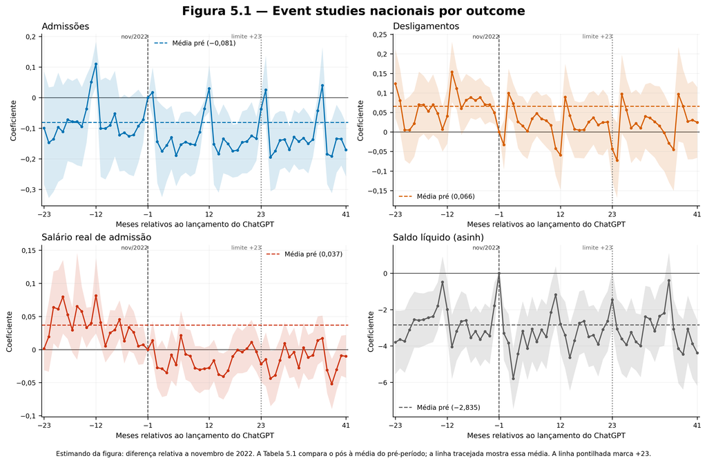

Figure 5.1 — National event studies and trajectories

Table 5.1.1 — Sector-control co-principal specifications

| outcome | level_1_coefficient | level_1_standard_error | level_1_p_value | level_1_n_obs | level_1_minimum_clusters | level_1_cluster_counts | level_1_role | level_2_coefficient | level_2_standard_error | level_2_p_value | level_2_n_obs | level_2_minimum_clusters | level_2_cluster_counts | level_2_role | coefficient_delta_level_2_minus_level_1 | level_1_pretrend_status | level_1_pretrend_joint_p_value | level_2_pretrend_status | level_2_pretrend_joint_p_value | two_way_coefficient | two_way_standard_error | two_way_p_value | two_way_n_obs | two_way_minimum_clusters | two_way_cluster_counts | two_way_role | two_way_pretrend_status | two_way_pretrend_joint_p_value | two_way_lead_covariance_positive_semidefinite | … |
| --- | --- | --- | --- | --- | --- | --- | --- | --- | --- | --- | --- | --- | --- | --- | --- | --- | --- | --- | --- | --- | --- | --- | --- | --- | --- | --- | --- | --- | --- | --- |
| admissoes | -0.053772 | 0.038560 | 0.164076 | 22049 | 341 | {““cbo_4d”“: 341} | principal | -0.075076 | 0.035644 | 0.035914 | 804574 | 341 | {““cbo_4d”“: 341} | co_principal_sector | -0.021304 | fail | 0.000000 | fail | 0.000000 | -0.075076 | 0.038403 | 0.053838 | 804574 | 87 | {““cbo_4d”“: 341,”“divisao”“: 87} | inference_robustness | fail | 0.269453 | FALSE | … |
| desligamentos | -0.042014 | 0.034702 | 0.226841 | 22049 | 341 | {““cbo_4d”“: 341} | principal | -0.066446 | 0.034828 | 0.057253 | 804665 | 341 | {““cbo_4d”“: 341} | co_principal_sector | -0.024432 | fail | 0.000000 | fail | 0.000000 | -0.066446 | 0.038195 | 0.085497 | 804665 | 87 | {““cbo_4d”“: 341,”“divisao”“: 87} | inference_robustness | fail | 0.555449 | FALSE | … |
| n_movimentacoes | -0.048093 | 0.035337 | 0.174416 | 22049 | 341 | {““cbo_4d”“: 341} | principal | -0.070665 | 0.034303 | 0.040155 | 804735 | 341 | {““cbo_4d”“: 341} | co_principal_sector | -0.022572 | fail | 0.000000 | fail | 0.000000 | -0.070665 | 0.037701 | 0.064276 | 804735 | 87 | {““cbo_4d”“: 341,”“divisao”“: 87} | inference_robustness | fail | 0.000000 | FALSE | … |
| ln_salario_real_adm | -0.050740 | 0.010332 | 0.000001 | 22012 | 341 | {““cbo_4d”“: 341} | principal | -0.035598 | 0.006438 | 0.000000 | 682889 | 341 | {““cbo_4d”“: 341} | co_principal_sector | 0.015142 | fail | 0.000158 | fail | 0.000055 | -0.035598 | 0.006913 | 0.000002 | 682889 | 87 | {““cbo_4d”“: 341,”“divisao”“: 87} | inference_robustness | fail | 0.000000 | TRUE | … |
| asinh_saldo | -0.551267 | 0.378317 | 0.145996 | 22049 | 341 | {““cbo_4d”“: 341} | principal | -0.139494 | 0.073427 | 0.058311 | 804735 | 341 | {““cbo_4d”“: 341} | co_principal_sector | 0.411773 | fail | 0.000001 | fail | 0.000000 | -0.139494 | 0.079670 | 0.083532 | 804735 | 87 | {““cbo_4d”“: 341,”“divisao”“: 87} | inference_robustness | fail | 0.000000 | TRUE | … |

**Gate científico.** O documento deve ser lido junto ao status de pré-tendência. Uma pré-tendência conjunta falha, uma matriz de covariância não PSD ou suporte insuficiente suprime a interpretação causal; isso não é corrigido por um coeficiente estático significativo.

National and supporting pretrend diagnostics (first 50 rows)

| family | specification_id | specification_label | outcome | estimator | event_window | joint_lead_window | joint_lead_count | joint_lead_p_value | lead_covariance_positive_semidefinite | linear_pretrend_coefficient | linear_pretrend_p_value | dynamic_pre_coefficients | dynamic_pre_p_lt_005 | pretrend_status | n_obs | minimum_clusters |
| --- | --- | --- | --- | --- | --- | --- | --- | --- | --- | --- | --- | --- | --- | --- | --- | --- |
| national | 00_frozen_exact_model | Frozen exact model, full sample, window -23…+23 | admissoes | ppml | -23_to_23 | -23_to_-2 | 22 | 0.000000 | TRUE | -0.005979 | 0.000000 | 22 | 3 | fail | 15935 | NA |
| national | 00_frozen_exact_model | Frozen exact model, full sample, window -23…+23 | desligamentos | ppml | -23_to_23 | -23_to_-2 | 22 | 0.000000 | TRUE | 0.003337 | 0.000008 | 22 | 10 | fail | 15935 | NA |
| national | 00_frozen_exact_model | Frozen exact model, full sample, window -23…+23 | n_movimentacoes | ppml | -23_to_23 | -23_to_-2 | 22 | 0.000000 | TRUE | -0.002599 | 0.001064 | 22 | 1 | fail | 15935 | NA |
| national | 00_frozen_exact_model | Frozen exact model, full sample, window -23…+23 | ln_salario_real_adm | ols | -23_to_23 | -23_to_-2 | 22 | 0.000158 | TRUE | -0.000584 | 0.220798 | 22 | 11 | fail | 15907 | NA |
| national | 00_frozen_exact_model | Frozen exact model, full sample, window -23…+23 | asinh_saldo | ols | -23_to_23 | -23_to_-2 | 22 | 0.000001 | TRUE | 0.002125 | 0.919829 | 22 | 21 | fail | 15935 | NA |
| power | balanced_frozen_window | Full sample, frozen balanced window -23 to +23 | admissoes | ppml | -23_to_23 | -23_to_-2 | 22 | 0.000000 | TRUE | -0.005979 | 0.000000 | 22 | 3 | fail | 15935 | 341 |
| power | balanced_frozen_window | Full sample, frozen balanced window -23 to +23 | admissoes | ppml | -23_to_23 | -11_to_-2 | 10 | 0.000002 | TRUE | -0.002395 | 0.344341 | 10 | 2 | fail | 15935 | 341 |
| power | extended_full_sample | Full sample, diagnostic window -23 to +41 | admissoes | ppml | -23_to_41 | -23_to_-2 | 22 | 0.000000 | TRUE | -0.005979 | 0.000000 | 22 | 3 | fail | 22049 | 341 |
| power | extended_full_sample | Full sample, diagnostic window -23 to +41 | admissoes | ppml | -23_to_41 | -11_to_-2 | 10 | 0.000002 | TRUE | -0.002395 | 0.344348 | 10 | 2 | fail | 22049 | 341 |
| power | balanced_frozen_window | Full sample, frozen balanced window -23 to +23 | desligamentos | ppml | -23_to_23 | -23_to_-2 | 22 | 0.000000 | TRUE | 0.003337 | 0.000008 | 22 | 10 | fail | 15935 | 341 |
| power | balanced_frozen_window | Full sample, frozen balanced window -23 to +23 | desligamentos | ppml | -23_to_23 | -11_to_-2 | 10 | 0.000144 | TRUE | -0.009162 | 0.000067 | 10 | 9 | fail | 15935 | 341 |
| power | extended_full_sample | Full sample, diagnostic window -23 to +41 | desligamentos | ppml | -23_to_41 | -23_to_-2 | 22 | 0.000000 | TRUE | 0.003337 | 0.000008 | 22 | 10 | fail | 22049 | 341 |
| power | extended_full_sample | Full sample, diagnostic window -23 to +41 | desligamentos | ppml | -23_to_41 | -11_to_-2 | 10 | 0.000144 | TRUE | -0.009162 | 0.000067 | 10 | 9 | fail | 22049 | 341 |
| power | balanced_frozen_window | Full sample, frozen balanced window -23 to +23 | n_movimentacoes | ppml | -23_to_23 | -23_to_-2 | 22 | 0.000000 | TRUE | -0.002599 | 0.001064 | 22 | 1 | fail | 15935 | 341 |
| power | balanced_frozen_window | Full sample, frozen balanced window -23 to +23 | n_movimentacoes | ppml | -23_to_23 | -11_to_-2 | 10 | 0.000003 | TRUE | -0.004117 | 0.020142 | 10 | 0 | fail | 15935 | 341 |
| power | extended_full_sample | Full sample, diagnostic window -23 to +41 | n_movimentacoes | ppml | -23_to_41 | -23_to_-2 | 22 | 0.000000 | TRUE | -0.002599 | 0.001064 | 22 | 1 | fail | 22049 | 341 |
| power | extended_full_sample | Full sample, diagnostic window -23 to +41 | n_movimentacoes | ppml | -23_to_41 | -11_to_-2 | 10 | 0.000003 | TRUE | -0.004117 | 0.020144 | 10 | 0 | fail | 22049 | 341 |
| power | balanced_frozen_window | Full sample, frozen balanced window -23 to +23 | ln_salario_real_adm | ols | -23_to_23 | -23_to_-2 | 22 | 0.000158 | TRUE | -0.000584 | 0.220798 | 22 | 11 | fail | 15907 | 341 |
| power | balanced_frozen_window | Full sample, frozen balanced window -23 to +23 | ln_salario_real_adm | ols | -23_to_23 | -11_to_-2 | 10 | 0.009855 | TRUE | -0.002436 | 0.030651 | 10 | 3 | fail | 15907 | 341 |
| power | extended_full_sample | Full sample, diagnostic window -23 to +41 | ln_salario_real_adm | ols | -23_to_41 | -23_to_-2 | 22 | 0.000174 | TRUE | -0.000571 | 0.231302 | 22 | 11 | fail | 22012 | 341 |
| power | extended_full_sample | Full sample, diagnostic window -23 to +41 | ln_salario_real_adm | ols | -23_to_41 | -11_to_-2 | 10 | 0.010115 | TRUE | -0.002455 | 0.029510 | 10 | 3 | fail | 22012 | 341 |
| power | balanced_frozen_window | Full sample, frozen balanced window -23 to +23 | asinh_saldo | ols | -23_to_23 | -23_to_-2 | 22 | 0.000001 | TRUE | 0.002125 | 0.919829 | 22 | 21 | fail | 15935 | 341 |
| power | balanced_frozen_window | Full sample, frozen balanced window -23 to +23 | asinh_saldo | ols | -23_to_23 | -11_to_-2 | 10 | 0.000012 | TRUE | 0.181928 | 0.001785 | 10 | 10 | fail | 15935 | 341 |
| power | extended_full_sample | Full sample, diagnostic window -23 to +41 | asinh_saldo | ols | -23_to_41 | -23_to_-2 | 22 | 0.000001 | TRUE | 0.002113 | 0.920284 | 22 | 21 | fail | 22049 | 341 |
| power | extended_full_sample | Full sample, diagnostic window -23 to +41 | asinh_saldo | ols | -23_to_41 | -11_to_-2 | 10 | 0.000012 | TRUE | 0.181934 | 0.001784 | 10 | 10 | fail | 22049 | 341 |
| sample | sample_2022_01 | Sample starts January 2022, window -11 to +41 | admissoes | ppml | -11_to_41 | -11_to_-2 | 10 | 0.000002 | TRUE | -0.002395 | 0.344338 | 10 | 2 | fail | 17976 | 341 |
| sample | sample_2022_01 | Sample starts January 2022, window -11 to +41 | desligamentos | ppml | -11_to_41 | -11_to_-2 | 10 | 0.000144 | TRUE | -0.009162 | 0.000067 | 10 | 9 | fail | 17976 | 341 |
| sample | sample_2022_01 | Sample starts January 2022, window -11 to +41 | n_movimentacoes | ppml | -11_to_41 | -11_to_-2 | 10 | 0.000003 | TRUE | -0.004117 | 0.020142 | 10 | 0 | fail | 17976 | 341 |
| sample | sample_2022_01 | Sample starts January 2022, window -11 to +41 | ln_salario_real_adm | ols | -11_to_41 | -11_to_-2 | 10 | 0.010164 | TRUE | -0.002452 | 0.029722 | 10 | 3 | fail | 17947 | 341 |
| sample | sample_2022_01 | Sample starts January 2022, window -11 to +41 | asinh_saldo | ols | -11_to_41 | -11_to_-2 | 10 | 0.000012 | TRUE | 0.181939 | 0.001783 | 10 | 10 | fail | 17976 | 341 |
| ladder | 04_include_minimal_as_control | Minimal Exposure included as control | admissoes | ppml | -23_to_23 | -23_to_-2 | 22 | 0.000000 | TRUE | 0.000281 | 0.757017 | 22 | 1 | fail | 20294 | 436 |
| ladder | 04_include_minimal_as_control | Minimal Exposure included as control | desligamentos | ppml | -23_to_23 | -23_to_-2 | 22 | 0.000000 | TRUE | 0.000715 | 0.337992 | 22 | 10 | fail | 20294 | 436 |
| ladder | 04_include_minimal_as_control | Minimal Exposure included as control | n_movimentacoes | ppml | -23_to_23 | -23_to_-2 | 22 | 0.000000 | TRUE | -0.001162 | 0.075450 | 22 | 0 | fail | 20294 | 436 |
| ladder | 04_include_minimal_as_control | Minimal Exposure included as control | ln_salario_real_adm | ols | -23_to_23 | -23_to_-2 | 22 | 0.002030 | TRUE | -0.000543 | 0.252382 | 22 | 9 | fail | 20238 | 436 |
| ladder | 04_include_minimal_as_control | Minimal Exposure included as control | asinh_saldo | ols | -23_to_23 | -23_to_-2 | 22 | 0.000001 | TRUE | -0.010793 | 0.595877 | 22 | 21 | fail | 20294 | 436 |
| ladder | 05_continuous_exposure | Standardized continuous exposure | admissoes | ppml | -23_to_23 | -23_to_-2 | 22 | 0.000000 | TRUE | -0.001516 | 0.000000 | 22 | 1 | fail | 20294 | 436 |
| ladder | 05_continuous_exposure | Standardized continuous exposure | desligamentos | ppml | -23_to_23 | -23_to_-2 | 22 | 0.000000 | TRUE | 0.001457 | 0.000000 | 22 | 12 | fail | 20294 | 436 |
| ladder | 05_continuous_exposure | Standardized continuous exposure | n_movimentacoes | ppml | -23_to_23 | -23_to_-2 | 22 | 0.000000 | TRUE | -0.001464 | 0.000000 | 22 | 1 | fail | 20294 | 436 |
| ladder | 05_continuous_exposure | Standardized continuous exposure | ln_salario_real_adm | ols | -23_to_23 | -23_to_-2 | 22 | 0.000020 | TRUE | -0.000309 | 0.075298 | 22 | 9 | fail | 20238 | 436 |
| ladder | 05_continuous_exposure | Standardized continuous exposure | asinh_saldo | ols | -23_to_23 | -23_to_-2 | 22 | 0.000000 | TRUE | 0.003095 | 0.701803 | 22 | 21 | fail | 20294 | 436 |
| sector | level_2 | CBO4 x CNAE section and section x month effects | admissoes | ppml | -23_to_23 | -23_to_-2 | 22 | 0.000000 | TRUE | -0.001731 | 0.016100 | 22 | 1 | fail | 581324 | 341 |
| sector | level_2 | CBO4 x CNAE section and section x month effects | desligamentos | ppml | -23_to_23 | -23_to_-2 | 22 | 0.000000 | TRUE | -0.000556 | 0.364731 | 22 | 3 | fail | 581433 | 341 |
| sector | level_2 | CBO4 x CNAE section and section x month effects | n_movimentacoes | ppml | -23_to_23 | -23_to_-2 | 22 | 0.000000 | TRUE | -0.000404 | 0.527562 | 22 | 0 | fail | 581507 | 341 |
| sector | level_2 | CBO4 x CNAE section and section x month effects | ln_salario_real_adm | ols | -23_to_23 | -23_to_-2 | 22 | 0.000055 | TRUE | -0.000455 | 0.092249 | 22 | 14 | fail | 493494 | 341 |
| sector | level_2 | CBO4 x CNAE section and section x month effects | asinh_saldo | ols | -23_to_23 | -23_to_-2 | 22 | 0.000000 | TRUE | -0.000479 | 0.810057 | 22 | 18 | fail | 581507 | 341 |
| sector | level_2_two_way | Level 2 with CBO4 and CNAE-division two-way clustering | admissoes | ppml | -23_to_23 | -23_to_-2 | 22 | 0.269453 | FALSE | -0.003856 | 0.000008 | 22 | 1 | fail | 581324 | 87 |
| sector | level_2_two_way | Level 2 with CBO4 and CNAE-division two-way clustering | desligamentos | ppml | -23_to_23 | -23_to_-2 | 22 | 0.555449 | FALSE | -0.004109 | 0.000039 | 22 | 3 | fail | 581433 | 87 |
| sector | level_2_two_way | Level 2 with CBO4 and CNAE-division two-way clustering | n_movimentacoes | ppml | -23_to_23 | -23_to_-2 | 22 | 0.000000 | FALSE | -0.002103 | 0.000000 | 22 | 0 | fail | 581507 | 87 |
| sector | level_2_two_way | Level 2 with CBO4 and CNAE-division two-way clustering | ln_salario_real_adm | ols | -23_to_23 | -23_to_-2 | 22 | 0.000000 | TRUE | -0.001628 | 0.000000 | 22 | 13 | fail | 493494 | 87 |
| sector | level_2_two_way | Level 2 with CBO4 and CNAE-division two-way clustering | asinh_saldo | ols | -23_to_23 | -23_to_-2 | 22 | 0.000000 | TRUE | 0.008913 | 0.000295 | 22 | 15 | fail | 581507 | 87 |

## 3.7 Heterogeneidades e diferenças-em-diferenças-em-diferenças (Seção 5.2)

Para uma característica de grupo $G_o$, o contraste de heterogeneidade usa todas as interações necessárias:

$$g\{Y_{ot}\} = \delta (Post_t \times Treated_o \times G_o)
+ \beta (Post_t \times Treated_o)
+ \gamma (Post_t \times G_o)
+ \eta (Treated_o \times G_o)
+ \alpha_o + \lambda_t + \varepsilon_{ot}.$$

Não basta comparar dois coeficientes em subamostras para chamar o resultado de DDD: o termo triplo acima é o objeto estimado. As famílias A–C têm regras de multiplicidade e testes de pré-tendência próprios, preservados nos artefatos abaixo.

**Código exibido apenas para leitura.** A família DDD completa usa o grande painel de heterogeneidade e é exibida, em vez de reexecutada, neste companion. Os modelos nacionais estáticos acima são deliberadamente os únicos modelos CAGED executados aqui.

```r
# Structural form used in the DDD contracts (illustrative R syntax)
feols(
  outcome ~ post_treat_group + post_treat + post_group + treat_group |
    cbo_4d + periodo,
  data = heterogeneity_panel,
  vcov = ~cbo_4d
)

# Dynamic group trajectories use the same event-time reference convention.
feols(
  outcome ~ i(event_time, treatment, group, ref = -1) |
    cbo_4d + periodo,
  data = heterogeneity_panel,
  vcov = ~cbo_4d
)
```

### 3.7.1 Sexo

Table 5.2.1 — Results by sex

group_id

group_label

outcome

estimator

coefficient

standard_error

nominal_p_value

n_obs

minimum_clusters

group_pretrend_status

group_pretrend_joint_p_value

ddd_pretrend_status

group_mde_80_power

result_status

error

source_diagnostic_family

ci_low

ci_high

cluster_df

support_status

target_treated_cbo_with_flows

target_control_cbo_with_flows

bh_adjusted_p_value

nominal_significant_005

bh_significant_005

family_id

family_size

multiplicity_method

multiplicity_scope

interpretation

is_causal_effect

diagnostic_group_pretrend

pretrend_reason

group_pretrend

stars

star_source

sex

micro

men

Men

admissoes

ppml

-0.077878

0.027223

0.004488

15935

341

fail

0.000000

fail

0.076487

estimated

NA

A

-0.131425

-0.024332

340

adequate

75

266

0.018819

TRUE

TRUE

C

130

Benjamini-Hochberg

single adjustment over all 130 per-group DiD tests

reportable

FALSE

fail

NA

fail

bh_adjusted_p_value

sex

micro

men

Men

desligamentos

ppml

-0.063543

0.024387

0.009575

15935

341

fail

0.000000

fail

0.068520

estimated

NA

A

-0.111512

-0.015574

340

adequate

75

266

0.033643

TRUE

TRUE

C

130

Benjamini-Hochberg

single adjustment over all 130 per-group DiD tests

reportable

FALSE

fail

NA

fail

bh_adjusted_p_value

sex

micro

men

Men

ln_salario_real_adm

ols

-0.050107

0.012178

0.000049

15867

341

fail

0.000382

fail

0.034217

estimated

NA

A

-0.074061

-0.026153

340

adequate

75

266

0.000453

TRUE

TRUE

C

130

Benjamini-Hochberg

single adjustment over all 130 per-group DiD tests

reportable

FALSE

fail

NA

fail

***

bh_adjusted_p_value

sex

micro

men

Men

asinh_saldo

ols

-0.245135

0.343413

0.475829

15935

341

fail

0.000000

fail

0.964870

estimated

NA

A

-0.920617

0.430347

340

adequate

75

266

0.581851

FALSE

FALSE

C

130

Benjamini-Hochberg

single adjustment over all 130 per-group DiD tests

reportable

FALSE

fail

NA

fail

bh_adjusted_p_value

sex

micro

women

Women

admissoes

ppml

-0.072387

0.046353

0.119306

15926

340

fail

0.000000

fail

0.130238

estimated

NA

A

-0.163564

0.018789

339

adequate

75

266

0.228085

FALSE

FALSE

C

130

Benjamini-Hochberg

single adjustment over all 130 per-group DiD tests

reportable

FALSE

fail

NA

fail

bh_adjusted_p_value

sex

micro

women

Women

desligamentos

ppml

-0.077643

0.037118

0.037196

15935

341

fail

0.000000

fail

0.104287

estimated

NA

A

-0.150652

-0.004634

340

adequate

75

266

0.094814

TRUE

FALSE

C

130

Benjamini-Hochberg

single adjustment over all 130 per-group DiD tests

reportable

FALSE

fail

NA

fail

bh_adjusted_p_value

sex

micro

women

Women

ln_salario_real_adm

ols

-0.049066

0.011726

0.000036

15418

340

fail

0.005858

fail

0.032946

estimated

NA

A

-0.072131

-0.026001

339

adequate

75

266

0.000365

TRUE

TRUE

C

130

Benjamini-Hochberg

single adjustment over all 130 per-group DiD tests

reportable

FALSE

fail

NA

fail

***

bh_adjusted_p_value

sex

micro

women

Women

asinh_saldo

ols

-1.018791

0.301525

0.000813

15935

341

fail

0.000916

fail

0.847179

estimated

NA

A

-1.611880

-0.425701

340

adequate

75

266

0.004225

TRUE

TRUE

C

130

Benjamini-Hochberg

single adjustment over all 130 per-group DiD tests

reportable

FALSE

fail

NA

fail

***

bh_adjusted_p_value

#### 3.7.1.1 Figure 5.2.1.1 — Admissions by sex

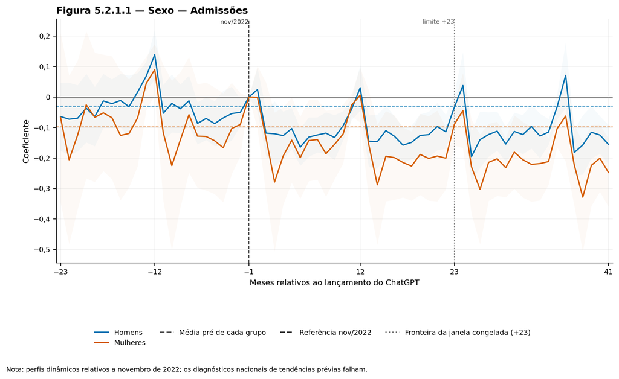

Figure 5.2.1.1 — Admissions by sex

#### 3.7.1.2 Figure 5.2.1.2 — Real admission wage by sex

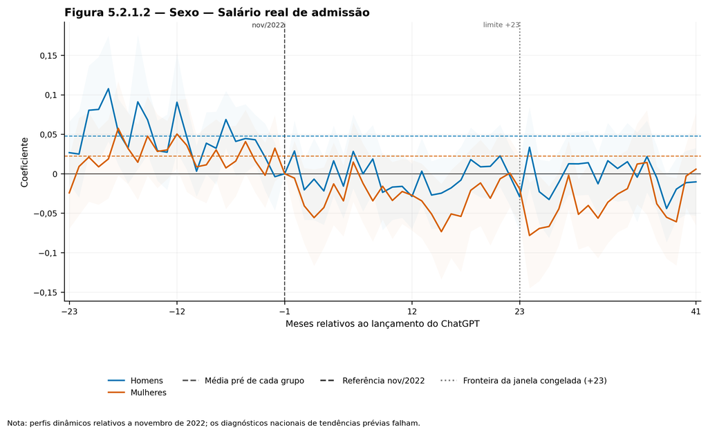

Figure 5.2.1.2 — Real admission wage by sex

### 3.7.2 Raça ou cor

Table 5.2.2 — Results by race or color

| dimension | dimension_kind | group_id | group_label | outcome | estimator | coefficient | standard_error | nominal_p_value | n_obs | minimum_clusters | group_pretrend_status | group_pretrend_joint_p_value | ddd_pretrend_status | group_mde_80_power | result_status | error | source_diagnostic_family | ci_low | ci_high | cluster_df | support_status | target_treated_cbo_with_flows | target_control_cbo_with_flows | bh_adjusted_p_value | nominal_significant_005 | bh_significant_005 | family_id | family_size | multiplicity_method | … |
| --- | --- | --- | --- | --- | --- | --- | --- | --- | --- | --- | --- | --- | --- | --- | --- | --- | --- | --- | --- | --- | --- | --- | --- | --- | --- | --- | --- | --- | --- | --- |
| race_color | micro | race_white | White | admissoes | ppml | -0.024075 | 0.034955 | 0.491452 | 15935 | 341 | fail | 0.000000 | fail | 0.098211 | estimated | NA | A | -0.092831 | 0.044680 | 340 | adequate | 75 | 266 | 0.591562 | FALSE | FALSE | C | 130 | Benjamini-Hochberg | … |
| race_color | micro | race_white | White | desligamentos | ppml | -0.018192 | 0.025037 | 0.467961 | 15935 | 341 | fail | 0.000000 | fail | 0.070344 | estimated | NA | A | -0.067438 | 0.031054 | 340 | adequate | 75 | 266 | 0.579381 | FALSE | FALSE | C | 130 | Benjamini-Hochberg | … |
| race_color | micro | race_white | White | ln_salario_real_adm | ols | -0.054381 | 0.011398 | 0.000003 | 15802 | 341 | fail | 0.000070 | fail | 0.032024 | estimated | NA | A | -0.076800 | -0.031962 | 340 | adequate | 75 | 266 | 0.000059 | TRUE | TRUE | C | 130 | Benjamini-Hochberg | … |
| race_color | micro | race_white | White | asinh_saldo | ols | -0.224571 | 0.300245 | 0.455002 | 15935 | 341 | fail | 0.000028 | fail | 0.843582 | estimated | NA | A | -0.815143 | 0.366001 | 340 | adequate | 75 | 266 | 0.568753 | FALSE | FALSE | C | 130 | Benjamini-Hochberg | … |
| race_aggregate | micro | race_negra | Black or Pardo | admissoes | ppml | -0.062126 | 0.044580 | 0.164355 | 15935 | 341 | fail | 0.000000 | fail | 0.125254 | estimated | NA | B | -0.149813 | 0.025561 | 340 | adequate | 75 | 266 | 0.260562 | FALSE | FALSE | C | 130 | Benjamini-Hochberg | … |
| race_aggregate | micro | race_negra | Black or Pardo | desligamentos | ppml | -0.058368 | 0.039568 | 0.141103 | 15935 | 341 | fail | 0.000000 | fail | 0.111173 | estimated | NA | B | -0.136198 | 0.019461 | 340 | adequate | 75 | 266 | 0.244147 | FALSE | FALSE | C | 130 | Benjamini-Hochberg | … |
| race_aggregate | micro | race_negra | Black or Pardo | ln_salario_real_adm | ols | -0.051294 | 0.010292 | 0.000001 | 15825 | 340 | fail | 0.114309 | pass | 0.028918 | estimated | NA | B | -0.071539 | -0.031050 | 339 | adequate | 75 | 266 | 0.000040 | TRUE | TRUE | C | 130 | Benjamini-Hochberg | … |
| race_aggregate | micro | race_negra | Black or Pardo | asinh_saldo | ols | -0.326449 | 0.262538 | 0.214564 | 15935 | 341 | fail | 0.000000 | fail | 0.737637 | estimated | NA | B | -0.842851 | 0.189954 | 340 | adequate | 75 | 266 | 0.307662 | FALSE | FALSE | C | 130 | Benjamini-Hochberg | … |

#### 3.7.2.1 Figure 5.2.2.1 — Admissions by race or color

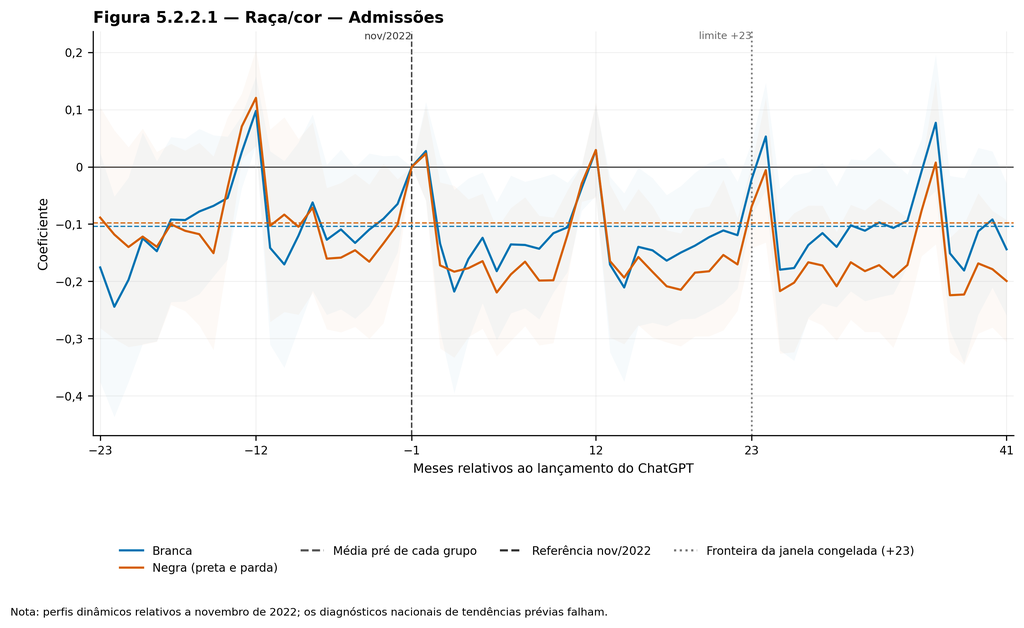

Figure 5.2.2.1 — Admissions by race or color

#### 3.7.2.2 Figure 5.2.2.2 — Real admission wage by race or color

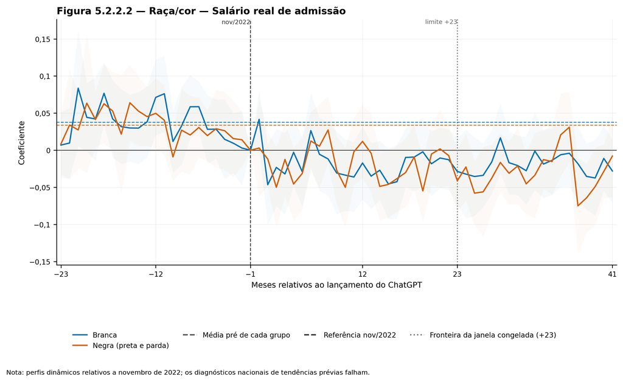

Figure 5.2.2.2 — Real admission wage by race or color

### 3.7.3 Idade

Table 5.2.3 — Results by age group

group_id

group_label

outcome

estimator

coefficient

standard_error

nominal_p_value

n_obs

minimum_clusters

group_pretrend_status

group_pretrend_joint_p_value

ddd_pretrend_status

group_mde_80_power

result_status

error

source_diagnostic_family

ci_low

ci_high

cluster_df

support_status

target_treated_cbo_with_flows

target_control_cbo_with_flows

bh_adjusted_p_value

nominal_significant_005

bh_significant_005

family_id

family_size

multiplicity_method

multiplicity_scope

interpretation

is_causal_effect

diagnostic_group_pretrend

pretrend_reason

group_pretrend

stars

star_source

age_pnad

micro

age_18_24

Age 18-24

admissoes

ppml

-0.037976

0.035970

0.291821

15935

341

fail

0.000000

fail

0.101062

estimated

NA

B

-0.108727

0.032775

340

adequate

75

266

0.399334

FALSE

FALSE

C

130

Benjamini-Hochberg

single adjustment over all 130 per-group DiD tests

reportable

FALSE

fail

NA

fail

bh_adjusted_p_value

age_pnad

micro

age_18_24

Age 18-24

desligamentos

ppml

-0.017031

0.044337

0.701129

15926

340

fail

0.000000

fail

0.124573

estimated

NA

B

-0.104241

0.070180

339

adequate

75

266

0.753279

FALSE

FALSE

C

130

Benjamini-Hochberg

single adjustment over all 130 per-group DiD tests

reportable

FALSE

fail

NA

fail

bh_adjusted_p_value

age_pnad

micro

age_18_24

Age 18-24

ln_salario_real_adm

ols

-0.051158

0.011063

0.000005

15616

340

warning

0.839432

fail

0.031083

estimated

NA

B

-0.072919

-0.029398

339

adequate

75

266

0.000092

TRUE

TRUE

C

130

Benjamini-Hochberg

single adjustment over all 130 per-group DiD tests

reportable

FALSE

warning

NA

warning

***

bh_adjusted_p_value

age_pnad

micro

age_18_24

Age 18-24

asinh_saldo

ols

-0.034383

0.193036

0.858738

15935

341

fail

0.000003

fail

0.542363

estimated

NA

B

-0.414078

0.345313

340

adequate

75

266

0.872156

FALSE

FALSE

C

130

Benjamini-Hochberg

single adjustment over all 130 per-group DiD tests

reportable

FALSE

fail

NA

fail

bh_adjusted_p_value

age_pnad

micro

age_25_34

Age 25-34

admissoes

ppml

-0.069303

0.031373

0.027840

15935

341

fail

0.000000

fail

0.088146

estimated

NA

B

-0.131012

-0.007594

340

adequate

75

266

0.078678

TRUE

FALSE

C

130

Benjamini-Hochberg

single adjustment over all 130 per-group DiD tests

reportable

FALSE

fail

NA

fail

bh_adjusted_p_value

age_pnad

micro

age_25_34

Age 25-34

desligamentos

ppml

-0.060823

0.025798

0.018957

15935

341

fail

0.000000

fail

0.072484

estimated

NA

B

-0.111568

-0.010079

340

adequate

75

266

0.058678

TRUE

FALSE

C

130

Benjamini-Hochberg

single adjustment over all 130 per-group DiD tests

reportable

FALSE

fail

NA

fail

bh_adjusted_p_value

age_pnad

micro

age_25_34

Age 25-34

ln_salario_real_adm

ols

-0.045982

0.010958

0.000035

15828

341

fail

0.000006

warning

0.030789

estimated

NA

B

-0.067537

-0.024427

340

adequate

75

266

0.000365

TRUE

TRUE

C

130

Benjamini-Hochberg

single adjustment over all 130 per-group DiD tests

reportable

FALSE

fail

NA

fail

***

bh_adjusted_p_value

age_pnad

micro

age_25_34

Age 25-34

asinh_saldo

ols

-0.506880

0.352875

0.151799

15935

341

fail

0.000000

fail

0.991453

estimated

NA

B

-1.200972

0.187213

340

adequate

75

266

0.249797

FALSE

FALSE

C

130

Benjamini-Hochberg

single adjustment over all 130 per-group DiD tests

reportable

FALSE

fail

NA

fail

bh_adjusted_p_value

age_pnad

micro

age_35_44

Age 35-44

admissoes

ppml

-0.045428

0.034348

0.186857

15935

341

fail

0.000000

fail

0.096505

estimated

NA

B

-0.112989

0.022132

340

adequate

75

266

0.285781

FALSE

FALSE

C

130

Benjamini-Hochberg

single adjustment over all 130 per-group DiD tests

reportable

FALSE

fail

NA

fail

bh_adjusted_p_value

age_pnad

micro

age_35_44

Age 35-44

desligamentos

ppml

-0.039796

0.026958

0.140816

15935

341

fail

0.000000

fail

0.075744

estimated

NA

B

-0.092822

0.013230

340

adequate

75

266

0.244147

FALSE

FALSE

C

130

Benjamini-Hochberg

single adjustment over all 130 per-group DiD tests

reportable

FALSE

fail

NA

fail

bh_adjusted_p_value

age_pnad

micro

age_35_44

Age 35-44

ln_salario_real_adm

ols

-0.054910

0.012861

0.000025

15775

340

fail

0.002765

fail

0.036136

estimated

NA

B

-0.080208

-0.029612

339

adequate

75

266

0.000301

TRUE

TRUE

C

130

Benjamini-Hochberg

single adjustment over all 130 per-group DiD tests

reportable

FALSE

fail

NA

fail

***

bh_adjusted_p_value

age_pnad

micro

age_35_44

Age 35-44

asinh_saldo

ols

-0.549763

0.305006

0.072358

15935

341

fail

0.000000

pass

0.856960

estimated

NA

B

-1.149700

0.050174

340

adequate

75

266

0.162274

FALSE

FALSE

C

130

Benjamini-Hochberg

single adjustment over all 130 per-group DiD tests

reportable

FALSE

fail

NA

fail

bh_adjusted_p_value

age_pnad

micro

age_45_54

Age 45-54

admissoes

ppml

-0.012489

0.046860

0.790007

15935

341

fail

0.000000

fail

0.131660

estimated

NA

B

-0.104661

0.079684

340

adequate

75

266

0.821608

FALSE

FALSE

C

130

Benjamini-Hochberg

single adjustment over all 130 per-group DiD tests

reportable

FALSE

fail

NA

fail

bh_adjusted_p_value

age_pnad

micro

age_45_54

Age 45-54

desligamentos

ppml

-0.022109

0.032548

0.497426

15935

341

fail

0.000000

fail

0.091447

estimated

NA

B

-0.086129

0.041911

340

adequate

75

266

0.593260

FALSE

FALSE

C

130

Benjamini-Hochberg

single adjustment over all 130 per-group DiD tests

reportable

FALSE

fail

NA

fail

bh_adjusted_p_value

age_pnad

micro

age_45_54

Age 45-54

ln_salario_real_adm

ols

-0.041712

0.011361

0.000280

15478

339

warning

0.195648

fail

0.031921

estimated

NA

B

-0.064060

-0.019365

338

adequate

75

266

0.001917

TRUE

TRUE

C

130

Benjamini-Hochberg

single adjustment over all 130 per-group DiD tests

reportable

FALSE

warning

NA

warning

***

bh_adjusted_p_value

age_pnad

micro

age_45_54

Age 45-54

asinh_saldo

ols

-0.227390

0.227028

0.317251

15935

341

fail

0.000000

fail

0.637868

estimated

NA

B

-0.673946

0.219166

340

adequate

75

266

0.425181

FALSE

FALSE

C

130

Benjamini-Hochberg

single adjustment over all 130 per-group DiD tests

reportable

FALSE

fail

NA

fail

bh_adjusted_p_value

age_pnad

micro

age_55_65

Age 55-65

admissoes

ppml

-0.039886

0.067775

0.556585

15926

340

fail

0.000000

fail

0.190426

estimated

NA

B

-0.173199

0.093427

339

adequate

75

266

0.646037

FALSE

FALSE

C

130

Benjamini-Hochberg

single adjustment over all 130 per-group DiD tests

reportable

FALSE

fail

NA

fail

bh_adjusted_p_value

age_pnad

micro

age_55_65

Age 55-65

desligamentos

ppml

-0.085955

0.039380

0.029743

15935

341

fail

0.000000

fail

0.110645

estimated

NA

B

-0.163415

-0.008495

340

adequate

75

266

0.082269

TRUE

FALSE

C

130

Benjamini-Hochberg

single adjustment over all 130 per-group DiD tests

reportable

FALSE

fail

NA

fail

bh_adjusted_p_value

age_pnad

micro

age_55_65

Age 55-65

ln_salario_real_adm

ols

-0.044843

0.012861

0.000554

14512

338

fail

0.117549

warning

0.036136

estimated

NA

B

-0.070141

-0.019544

337

adequate

75

266

0.003130

TRUE

TRUE

C

130

Benjamini-Hochberg

single adjustment over all 130 per-group DiD tests

reportable

FALSE

fail

NA

fail

***

bh_adjusted_p_value

age_pnad

micro

age_55_65

Age 55-65

asinh_saldo

ols

0.379402

0.134542

0.005085

15935

341

fail

0.000000

fail

0.378016

estimated

NA

B

0.114762

0.644042

340

adequate

75

266

0.020031

TRUE

TRUE

C

130

Benjamini-Hochberg

single adjustment over all 130 per-group DiD tests

reportable

FALSE

fail

NA

fail

bh_adjusted_p_value

#### 3.7.3.1 Figure 5.2.3.1 — Admissions by age group

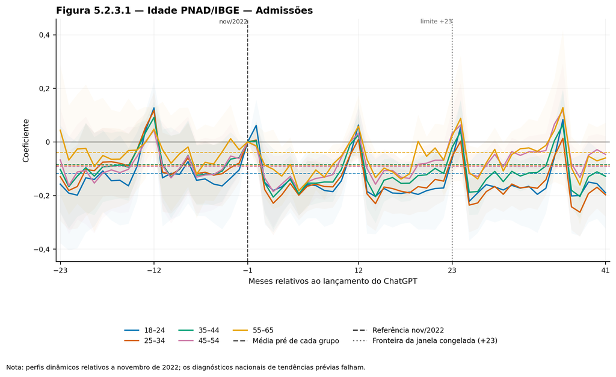

Figure 5.2.3.1 — Admissions by age group

#### 3.7.3.2 Figure 5.2.3.2 — Real admission wage by age group

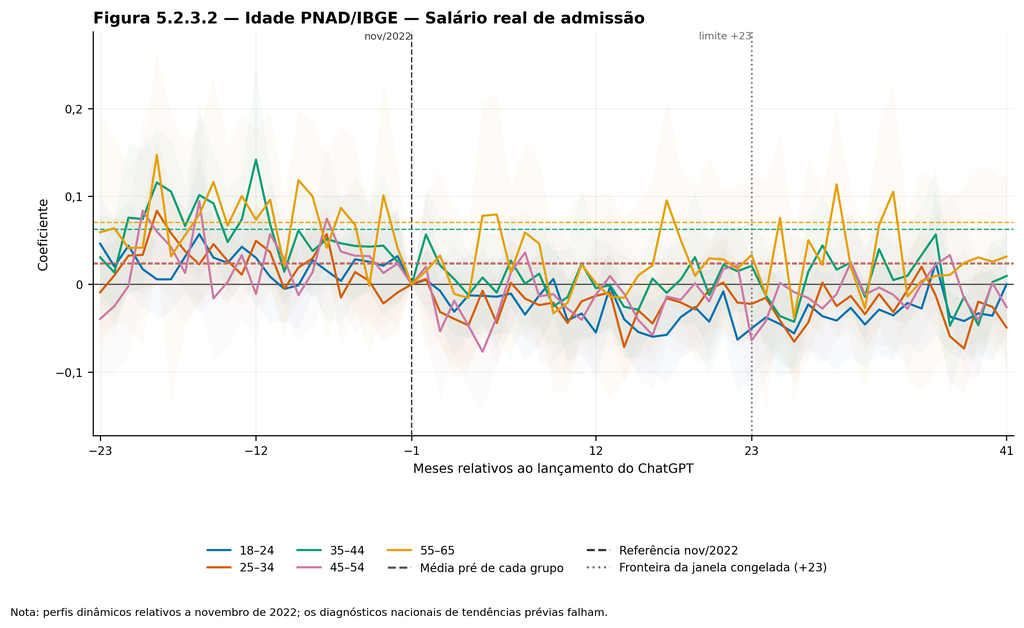

Figure 5.2.3.2 — Real admission wage by age group

#### 3.7.3.3 Figure 5.2.3.3 — Real admission wage for ages 22 to 25

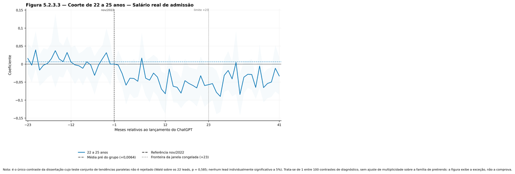

Figure 5.2.3.3 — Real admission wage for ages 22 to 25

### 3.7.4 Educação

Table 5.2.4 — Results by education

| dimension | dimension_kind | group_id | group_label | outcome | estimator | coefficient | standard_error | nominal_p_value | n_obs | minimum_clusters | group_pretrend_status | group_pretrend_joint_p_value | ddd_pretrend_status | group_mde_80_power | result_status | error | source_diagnostic_family | ci_low | ci_high | cluster_df | support_status | target_treated_cbo_with_flows | target_control_cbo_with_flows | bh_adjusted_p_value | nominal_significant_005 | bh_significant_005 | family_id | family_size | multiplicity_method | … |
| --- | --- | --- | --- | --- | --- | --- | --- | --- | --- | --- | --- | --- | --- | --- | --- | --- | --- | --- | --- | --- | --- | --- | --- | --- | --- | --- | --- | --- | --- | --- |
| education | micro | fundamental_or_less | Primary or less | admissoes | ppml | 0.001758 | 0.053086 | 0.973595 | 15879 | 339 | fail | 0.000000 | fail | 0.149155 | estimated | NA | A | -0.102662 | 0.106179 | 338 | adequate | 75 | 266 | 0.973595 | FALSE | FALSE | C | 130 | Benjamini-Hochberg | … |
| education | micro | fundamental_or_less | Primary or less | desligamentos | ppml | 0.014131 | 0.046854 | 0.763148 | 15935 | 341 | fail | 0.000000 | fail | 0.131644 | estimated | NA | A | -0.078030 | 0.106291 | 340 | adequate | 75 | 266 | 0.800075 | FALSE | FALSE | C | 130 | Benjamini-Hochberg | … |
| education | micro | fundamental_or_less | Primary or less | ln_salario_real_adm | ols | -0.007990 | 0.014424 | 0.580019 | 14641 | 337 | fail | 0.027048 | fail | 0.040528 | estimated | NA | A | -0.036363 | 0.020384 | 336 | adequate | 75 | 266 | 0.661425 | FALSE | FALSE | C | 130 | Benjamini-Hochberg | … |
| education | micro | fundamental_or_less | Primary or less | asinh_saldo | ols | 0.333043 | 0.166810 | 0.046671 | 15935 | 341 | fail | 0.000000 | fail | 0.468676 | estimated | NA | A | 0.004934 | 0.661153 | 340 | adequate | 75 | 266 | 0.112357 | TRUE | FALSE | C | 130 | Benjamini-Hochberg | … |
| education | micro | high_school | Secondary | admissoes | ppml | -0.043807 | 0.031376 | 0.163571 | 15935 | 341 | fail | 0.000000 | fail | 0.088156 | estimated | NA | A | -0.105523 | 0.017909 | 340 | adequate | 75 | 266 | 0.260562 | FALSE | FALSE | C | 130 | Benjamini-Hochberg | … |
| education | micro | high_school | Secondary | desligamentos | ppml | -0.045482 | 0.030682 | 0.139178 | 15935 | 341 | fail | 0.000000 | fail | 0.086207 | estimated | NA | A | -0.105833 | 0.014870 | 340 | adequate | 75 | 266 | 0.244147 | FALSE | FALSE | C | 130 | Benjamini-Hochberg | … |
| education | micro | high_school | Secondary | ln_salario_real_adm | ols | -0.042705 | 0.012183 | 0.000517 | 15801 | 341 | fail | 0.045009 | fail | 0.034230 | estimated | NA | A | -0.066668 | -0.018741 | 340 | adequate | 75 | 266 | 0.003057 | TRUE | TRUE | C | 130 | Benjamini-Hochberg | … |
| education | micro | high_school | Secondary | asinh_saldo | ols | -0.297263 | 0.325099 | 0.361167 | 15935 | 341 | fail | 0.000000 | fail | 0.913413 | estimated | NA | A | -0.936721 | 0.342195 | 340 | adequate | 75 | 266 | 0.469517 | FALSE | FALSE | C | 130 | Benjamini-Hochberg | … |
| education | micro | higher_education | Higher education | admissoes | ppml | -0.107456 | 0.037063 | 0.003984 | 15926 | 340 | fail | 0.000000 | fail | 0.104136 | estimated | NA | A | -0.180360 | -0.034553 | 339 | adequate | 75 | 266 | 0.017265 | TRUE | TRUE | C | 130 | Benjamini-Hochberg | … |
| education | micro | higher_education | Higher education | desligamentos | ppml | -0.093889 | 0.036346 | 0.010207 | 15935 | 341 | fail | 0.000000 | fail | 0.102120 | estimated | NA | A | -0.165381 | -0.022397 | 340 | adequate | 75 | 266 | 0.034917 | TRUE | TRUE | C | 130 | Benjamini-Hochberg | … |
| education | micro | higher_education | Higher education | ln_salario_real_adm | ols | -0.035157 | 0.009320 | 0.000191 | 14892 | 340 | fail | 0.000113 | warning | 0.026187 | estimated | NA | A | -0.053489 | -0.016824 | 339 | adequate | 75 | 266 | 0.001379 | TRUE | TRUE | C | 130 | Benjamini-Hochberg | … |
| education | micro | higher_education | Higher education | asinh_saldo | ols | -1.156196 | 0.317289 | 0.000310 | 15935 | 341 | fail | 0.000002 | fail | 0.891469 | estimated | NA | A | -1.780292 | -0.532100 | 340 | adequate | 75 | 266 | 0.002017 | TRUE | TRUE | C | 130 | Benjamini-Hochberg | … |

#### 3.7.4.1 Figure 5.2.4.1 — Admissions by education

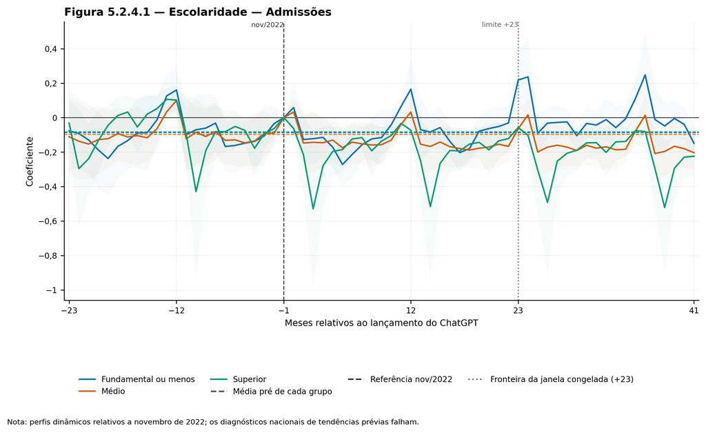

Figure 5.2.4.1 — Admissions by education

#### 3.7.4.2 Figure 5.2.4.2 — Real admission wage by education

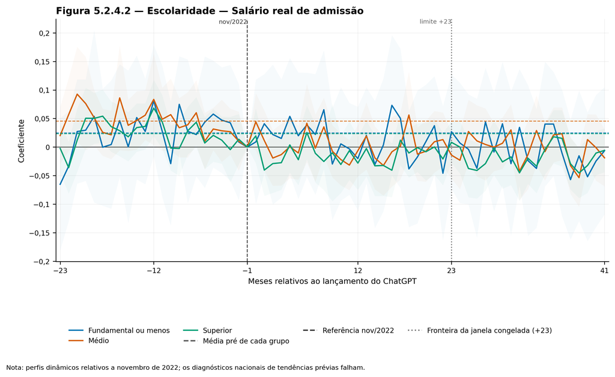

Figure 5.2.4.2 — Real admission wage by education

### 3.7.5 Renda ocupacional pré-tratamento

Table 5.2.5 — Results by pre-treatment occupational wage

| dimension | dimension_kind | group_id | group_label | outcome | estimator | coefficient | standard_error | nominal_p_value | n_obs | minimum_clusters | group_pretrend_status | group_pretrend_joint_p_value | ddd_pretrend_status | group_mde_80_power | result_status | error | source_diagnostic_family | ci_low | ci_high | cluster_df | support_status | target_treated_cbo_with_flows | target_control_cbo_with_flows | bh_adjusted_p_value | nominal_significant_005 | bh_significant_005 | family_id | family_size | multiplicity_method | … |
| --- | --- | --- | --- | --- | --- | --- | --- | --- | --- | --- | --- | --- | --- | --- | --- | --- | --- | --- | --- | --- | --- | --- | --- | --- | --- | --- | --- | --- | --- | --- |
| income | cbo_predetermined | low_income | Up to 2 minimum wages | admissoes | ppml | -0.030351 | 0.032087 | 0.345031 | 12782 | 273 | fail | 0.000000 | fail | 0.090217 | estimated | NA | A | -0.093522 | 0.032819 | 272 | adequate | 46 | 227 | 0.453071 | FALSE | FALSE | C | 130 | Benjamini-Hochberg | … |
| income | cbo_predetermined | low_income | Up to 2 minimum wages | desligamentos | ppml | -0.040914 | 0.029942 | 0.172925 | 12782 | 273 | fail | 0.000000 | fail | 0.084186 | estimated | NA | A | -0.099861 | 0.018033 | 272 | adequate | 46 | 227 | 0.270846 | FALSE | FALSE | C | 130 | Benjamini-Hochberg | … |
| income | cbo_predetermined | low_income | Up to 2 minimum wages | ln_salario_real_adm | ols | -0.049298 | 0.013975 | 0.000492 | 12755 | 273 | fail | 0.015630 | warning | 0.039292 | estimated | NA | A | -0.076810 | -0.021786 | 272 | adequate | 46 | 227 | 0.003046 | TRUE | TRUE | C | 130 | Benjamini-Hochberg | … |
| income | cbo_predetermined | low_income | Up to 2 minimum wages | asinh_saldo | ols | 0.214415 | 0.356887 | 0.548478 | 12782 | 273 | fail | 0.000012 | fail | 1.003448 | estimated | NA | A | -0.488197 | 0.917027 | 272 | adequate | 46 | 227 | 0.642362 | FALSE | FALSE | C | 130 | Benjamini-Hochberg | … |
| income | cbo_predetermined | middle_income | Over 2 through 5 minimum wages | admissoes | ppml | -0.191359 | 0.066396 | 0.005561 | 2726 | 58 | fail | 0.000000 | fail | 0.189258 | estimated | NA | A | -0.324315 | -0.058403 | 57 | limited | 26 | 32 | 0.021264 | TRUE | TRUE | C | 130 | Benjamini-Hochberg | … |
| income | cbo_predetermined | middle_income | Over 2 through 5 minimum wages | desligamentos | ppml | -0.102760 | 0.079974 | 0.204015 | 2726 | 58 | fail | 0.000000 | fail | 0.227960 | estimated | NA | A | -0.262904 | 0.057384 | 57 | limited | 26 | 32 | 0.297999 | FALSE | FALSE | C | 130 | Benjamini-Hochberg | … |
| income | cbo_predetermined | middle_income | Over 2 through 5 minimum wages | ln_salario_real_adm | ols | -0.043429 | 0.025765 | 0.097340 | 2725 | 58 | fail | 0.000169 | fail | 0.073441 | estimated | NA | A | -0.095022 | 0.008164 | 57 | limited | 26 | 32 | 0.198338 | FALSE | FALSE | C | 130 | Benjamini-Hochberg | … |
| income | cbo_predetermined | middle_income | Over 2 through 5 minimum wages | asinh_saldo | ols | -1.248403 | 0.835035 | 0.140423 | 2726 | 58 | warning | 0.197596 | fail | 2.380215 | estimated | NA | A | -2.920531 | 0.423726 | 57 | limited | 26 | 32 | 0.244147 | FALSE | FALSE | C | 130 | Benjamini-Hochberg | … |
| income | cbo_predetermined | high_income | Over 5 minimum wages | admissoes | ppml | -0.006831 | 0.095401 | 0.944678 | 423 | 9 | not_interpretable_rank_deficient | NA | fail | 0.304795 | estimated | NA | A | -0.226825 | 0.213164 | 8 | thin | 3 | 6 | 0.952001 | FALSE | FALSE | C | 130 | Benjamini-Hochberg | … |
| income | cbo_predetermined | high_income | Over 5 minimum wages | desligamentos | ppml | 0.156369 | 0.105305 | 0.175865 | 423 | 9 | not_interpretable_rank_deficient | NA | fail | 0.336437 | estimated | NA | A | -0.086464 | 0.399202 | 8 | thin | 3 | 6 | 0.272172 | FALSE | FALSE | C | 130 | Benjamini-Hochberg | … |
| income | cbo_predetermined | high_income | Over 5 minimum wages | ln_salario_real_adm | ols | 0.011735 | 0.034502 | 0.742520 | 423 | 9 | not_interpretable_rank_deficient | NA | fail | 0.110230 | estimated | NA | A | -0.067827 | 0.091297 | 8 | thin | 3 | 6 | 0.784777 | FALSE | FALSE | C | 130 | Benjamini-Hochberg | … |
| income | cbo_predetermined | high_income | Over 5 minimum wages | asinh_saldo | ols | -3.422714 | 2.117129 | 0.144610 | 423 | 9 | not_interpretable_rank_deficient | NA | fail | 6.764003 | estimated | NA | A | -8.304823 | 1.459395 | 8 | thin | 3 | 6 | 0.244147 | FALSE | FALSE | C | 130 | Benjamini-Hochberg | … |

#### 3.7.5.1 Figure 5.2.5.1 — Admissions by pre-treatment income

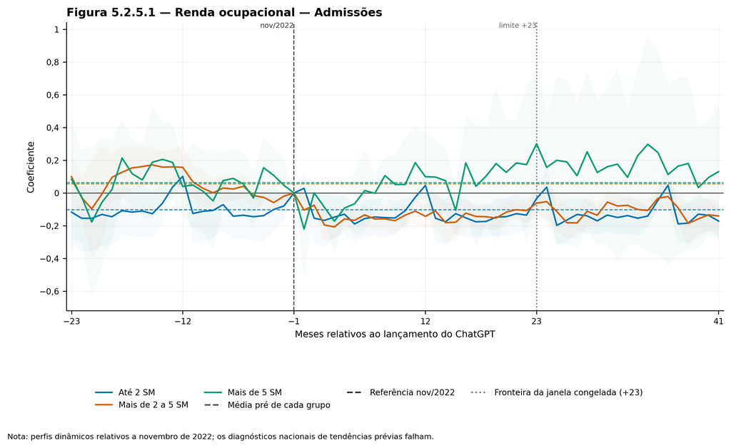

Figure 5.2.5.1 — Admissions by pre-treatment income

#### 3.7.5.2 Figure 5.2.5.2 — Real admission wage by pre-treatment income

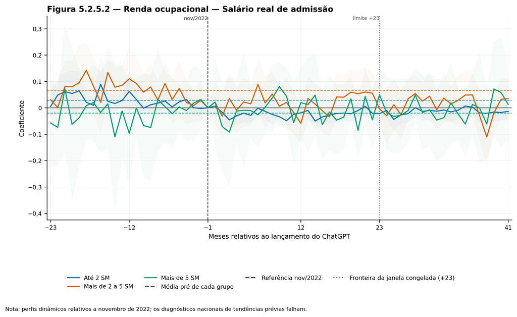

Figure 5.2.5.2 — Real admission wage by pre-treatment income

### 3.7.6 Síntese por desfecho

#### 3.7.6.1 Figure 5.2.6 — Within-group DiD estimates by outcome

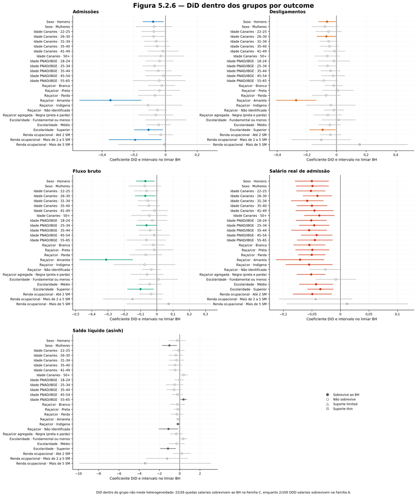

Figure 5.2.6 — Within-group DiD estimates by outcome

## 3.8 Apêndice A: diagnósticos e contrastes DDD

**Carregado da referência assinada do V2.** O Apêndice A é renderizado a partir das tabelas de referência assinadas e de duas tabelas descritivas da versão atual da dissertação, apoiadas por dados de auditoria do V2. Os rótulos atuais A.2.1 e A.2.2 são intencionalmente distintos dos identificadores legados dos artefatos V2.

Table A.1 — National-result diagnostics

| panel | outcome_id | outcome | coefficient | standard_error | p_value | pretrend_status | pretrend_p_value | n_obs | n_clusters | interpretation |
| --- | --- | --- | --- | --- | --- | --- | --- | --- | --- | --- |
| B.1 | admissoes | Admissões (PPML, nível) | -0.053772 | 0.038560 | 0.164076 | fail | 0.000000 | 22049 | 341 | principal national estimate; all available pretrends fail |
| B.1 | desligamentos | Desligamentos (PPML, nível) | -0.042014 | 0.034702 | 0.226841 | fail | 0.000000 | 22049 | 341 | principal national estimate; all available pretrends fail |
| B.1 | n_movimentacoes | Fluxo bruto (PPML, nível) | -0.048093 | 0.035337 | 0.174416 | fail | 0.000000 | 22049 | 341 | principal national estimate; all available pretrends fail |
| B.1 | ln_salario_real_adm | Salário real de admissão (log) | -0.050740 | 0.010332 | 0.000001 | fail | 0.000158 | 22012 | 341 | principal national estimate; all available pretrends fail |
| B.1 | asinh_saldo | Saldo líquido (asinh) | -0.551267 | 0.378317 | 0.145996 | fail | 0.000001 | 22049 | 341 | principal national estimate; all available pretrends fail |
| B.2 | stock_proxy_index | Proxy cumulativo de fluxo líquido | 1.429214 | 1.309287 | 0.275785 | not_available | NA | 22100 | 340 | cumulative flow proxy; not employment stock |

Table A.2.1 — Educational composition shift

| group_id | treated_pre | treated_post | control_pre | control_post | treated_change_pp | control_change_pp | did_pp |
| --- | --- | --- | --- | --- | --- | --- | --- |
| fundamental_or_less | 0.034744 | 0.033871 | 0.270588 | 0.242122 | -0.087257 | -2.846639 | 2.759382 |
| high_school | 0.666252 | 0.695388 | 0.675590 | 0.705466 | 2.913610 | 2.987581 | -0.073971 |
| higher_education | 0.299004 | 0.270741 | 0.053821 | 0.052412 | -2.826354 | -0.140942 | -2.685411 |

Table A.2.2 — Wage price/composition decomposition

| group_id | coefficient | standard_error | bh_adjusted_p_value | treated_pre | did_pp | weight |
| --- | --- | --- | --- | --- | --- | --- |
| fundamental_or_less | -0.007990 | 0.014424 | 0.661425 | 0.034744 | 2.759382 | 0.034744 |
| high_school | -0.042705 | 0.012183 | 0.003057 | 0.666252 | -0.073971 | 0.666252 |
| higher_education | -0.035157 | 0.009320 | 0.001379 | 0.299004 | -2.685411 | 0.299004 |

Table A.3 — DDD contrasts by sex

| panel_family_group | outcome | ddd_estimate_se | nominal_p_value | bh_adjusted_p_value | group_pretrend | ddd_pretrend | group_mde_80_power | n_and_cbo_support |
| --- | --- | --- | --- | --- | --- | --- | --- | --- |
| Contrastes DDD · Família A (100) · Homens | Admissões (PPML, nível) | 0,0116 (0,0466) | 0.802953 | 0.906791 | fail | fail | 0.076487 | N=15.935; CBOs 75/266; adequate |
| Contrastes DDD · Família A (100) · Homens | Desligamentos (PPML, nível) | 0,0332 (0,0390) | 0.395091 | 0.581015 | fail | fail | 0.068520 | N=15.935; CBOs 75/266; adequate |
| Contrastes DDD · Família A (100) · Homens | Fluxo bruto (PPML, nível) | 0,0216 (0,0420) | 0.607238 | 0.741780 | fail | fail | 0.065508 | N=15.935; CBOs 75/266; adequate |
| Contrastes DDD · Família A (100) · Homens | Salário real de admissão (log) | 0,0022 (0,0100) | 0.823828 | 0.906791 | fail | fail | 0.034217 | N=15.867; CBOs 75/266; adequate |
| Contrastes DDD · Família A (100) · Homens | Saldo líquido (asinh) | 0,7989 (0,2145) | 0.000230 | 0.002552 | fail | fail | 0.964870 | N=15.935; CBOs 75/266; adequate |
| Contrastes DDD · Família A (100) · Mulheres | Admissões (PPML, nível) | −0,0116 (0,0466) | 0.802953 | 0.906791 | fail | fail | 0.130238 | N=15.926; CBOs 75/266; adequate |
| Contrastes DDD · Família A (100) · Mulheres | Desligamentos (PPML, nível) | −0,0332 (0,0390) | 0.395091 | 0.581015 | fail | fail | 0.104287 | N=15.935; CBOs 75/266; adequate |
| Contrastes DDD · Família A (100) · Mulheres | Fluxo bruto (PPML, nível) | −0,0216 (0,0420) | 0.607238 | 0.741780 | fail | fail | 0.114246 | N=15.935; CBOs 75/266; adequate |
| Contrastes DDD · Família A (100) · Mulheres | Salário real de admissão (log) | −0,0022 (0,0100) | 0.823828 | 0.906791 | fail | fail | 0.032946 | N=15.418; CBOs 75/266; adequate |
| Contrastes DDD · Família A (100) · Mulheres | Saldo líquido (asinh) | −0,7989 (0,2145) | 0.000230 | 0.002552 | fail | fail | 0.847179 | N=15.935; CBOs 75/266; adequate |

Table A.4 — DDD contrasts by race or color

| panel_family_group | outcome | ddd_estimate_se | nominal_p_value | bh_adjusted_p_value | group_pretrend | ddd_pretrend | group_mde_80_power | n_and_cbo_support |
| --- | --- | --- | --- | --- | --- | --- | --- | --- |
| Seis categorias raciais · Família A (100) · Branca | Admissões (PPML, nível) | 0,0827 (0,0188) | 0.000015 | 0.000253 | fail | fail | 0.098211 | N=15.935; CBOs 75/266; adequate |
| Seis categorias raciais · Família A (100) · Branca | Desligamentos (PPML, nível) | 0,0651 (0,0136) | 0.000002 | 0.000049 | fail | fail | 0.070344 | N=15.935; CBOs 75/266; adequate |
| Seis categorias raciais · Família A (100) · Branca | Fluxo bruto (PPML, nível) | 0,0743 (0,0144) | 0.000000 | 0.000015 | fail | fail | 0.079413 | N=15.935; CBOs 75/266; adequate |
| Seis categorias raciais · Família A (100) · Branca | Salário real de admissão (log) | −0,0080 (0,0088) | 0.361404 | 0.556007 | fail | fail | 0.032024 | N=15.802; CBOs 75/266; adequate |
| Seis categorias raciais · Família A (100) · Branca | Saldo líquido (asinh) | 0,7390 (0,2544) | 0.003921 | 0.025548 | fail | fail | 0.843582 | N=15.935; CBOs 75/266; adequate |
| Seis categorias raciais · Família A (100) · Preta | Admissões (PPML, nível) | −0,0088 (0,0399) | 0.825180 | 0.906791 | fail | fail | 0.151738 | N=15.926; CBOs 75/265; adequate |
| Seis categorias raciais · Família A (100) · Preta | Desligamentos (PPML, nível) | 0,0445 (0,0309) | 0.150084 | 0.341099 | fail | fail | 0.122205 | N=15.926; CBOs 75/265; adequate |
| Seis categorias raciais · Família A (100) · Preta | Fluxo bruto (PPML, nível) | 0,0160 (0,0356) | 0.653227 | 0.787020 | fail | fail | 0.134590 | N=15.926; CBOs 75/265; adequate |
| Seis categorias raciais · Família A (100) · Preta | Salário real de admissão (log) | −0,0052 (0,0101) | 0.608260 | 0.741780 | fail | fail | 0.034256 | N=14.922; CBOs 75/265; adequate |
| Seis categorias raciais · Família A (100) · Preta | Saldo líquido (asinh) | 0,2580 (0,2821) | 0.360990 | 0.556007 | fail | fail | 0.438637 | N=15.935; CBOs 75/265; adequate |
| Seis categorias raciais · Família A (100) · Parda | Admissões (PPML, nível) | −0,0817 (0,0304) | 0.007504 | 0.041686 | fail | fail | 0.123334 | N=15.935; CBOs 75/266; adequate |
| Seis categorias raciais · Família A (100) · Parda | Desligamentos (PPML, nível) | −0,0886 (0,0292) | 0.002586 | 0.018474 | fail | fail | 0.111986 | N=15.935; CBOs 75/266; adequate |
| Seis categorias raciais · Família A (100) · Parda | Fluxo bruto (PPML, nível) | −0,0848 (0,0293) | 0.004088 | 0.025548 | fail | fail | 0.115106 | N=15.935; CBOs 75/266; adequate |
| Seis categorias raciais · Família A (100) · Parda | Salário real de admissão (log) | −0,0102 (0,0092) | 0.269585 | 0.464802 | fail | pass | 0.027591 | N=15.804; CBOs 75/266; adequate |
| Seis categorias raciais · Família A (100) · Parda | Saldo líquido (asinh) | 0,1655 (0,2834) | 0.559605 | 0.708361 | fail | fail | 0.727567 | N=15.935; CBOs 75/266; adequate |
| Seis categorias raciais · Família A (100) · Amarela | Admissões (PPML, nível) | −0,2770 (0,0576) | 0.000002 | 0.000049 | fail | fail | 0.226164 | N=15.832; CBOs 75/264; adequate |
| Seis categorias raciais · Família A (100) · Amarela | Desligamentos (PPML, nível) | −0,2179 (0,0365) | 0.000000 | 0.000001 | fail | fail | 0.156351 | N=15.832; CBOs 75/264; adequate |
| Seis categorias raciais · Família A (100) · Amarela | Fluxo bruto (PPML, nível) | −0,2487 (0,0466) | 0.000000 | 0.000009 | fail | fail | 0.190066 | N=15.879; CBOs 75/264; adequate |
| Seis categorias raciais · Família A (100) · Amarela | Salário real de admissão (log) | −0,0171 (0,0150) | 0.254107 | 0.453763 | fail | warning | 0.048596 | N=11.300; CBOs 75/264; adequate |
| Seis categorias raciais · Família A (100) · Amarela | Saldo líquido (asinh) | 0,3108 (0,3305) | 0.347628 | 0.551790 | fail | fail | 0.274616 | N=15.935; CBOs 75/264; adequate |
| Seis categorias raciais · Família A (100) · Indígena | Admissões (PPML, nível) | −0,1744 (0,1003) | 0.082847 | 0.218019 | fail | fail | 0.250154 | N=15.040; CBOs 73/259; adequate |
| Seis categorias raciais · Família A (100) · Indígena | Desligamentos (PPML, nível) | −0,1172 (0,1140) | 0.304789 | 0.506978 | fail | fail | 0.192592 | N=15.185; CBOs 73/259; adequate |
| Seis categorias raciais · Família A (100) · Indígena | Fluxo bruto (PPML, nível) | −0,1455 (0,1049) | 0.166334 | 0.369631 | fail | fail | 0.217782 | N=15.420; CBOs 73/259; adequate |
| Seis categorias raciais · Família A (100) · Indígena | Salário real de admissão (log) | −0,0036 (0,0178) | 0.837565 | 0.910396 | pass | pass | 0.047320 | N=8.228; CBOs 73/259; adequate |
| Seis categorias raciais · Família A (100) · Indígena | Saldo líquido (asinh) | 0,3605 (0,3540) | 0.309257 | 0.506978 | fail | fail | 0.184859 | N=15.935; CBOs 73/259; adequate |
| Seis categorias raciais · Família A (100) · Não identificada | Admissões (PPML, nível) | 0,0197 (0,0300) | 0.510477 | 0.680636 | fail | fail | 0.067523 | N=15.931; CBOs 75/266; adequate |
| Seis categorias raciais · Família A (100) · Não identificada | Desligamentos (PPML, nível) | 0,0541 (0,0263) | 0.040299 | 0.125934 | fail | fail | 0.078984 | N=15.926; CBOs 75/266; adequate |
| Seis categorias raciais · Família A (100) · Não identificada | Fluxo bruto (PPML, nível) | 0,0376 (0,0278) | 0.176480 | 0.375489 | fail | fail | 0.066627 | N=15.935; CBOs 75/266; adequate |
| Seis categorias raciais · Família A (100) · Não identificada | Salário real de admissão (log) | 0,0415 (0,0107) | 0.000129 | 0.001841 | warning | fail | 0.032016 | N=14.437; CBOs 75/266; adequate |
| Seis categorias raciais · Família A (100) · Não identificada | Saldo líquido (asinh) | −0,9754 (0,4922) | 0.048312 | 0.142095 | fail | fail | 1.099397 | N=15.935; CBOs 75/266; adequate |

Table A.5 — DDD contrasts by age

| panel_family_group | outcome | ddd_estimate_se | nominal_p_value | bh_adjusted_p_value | group_pretrend | ddd_pretrend | group_mde_80_power | n_and_cbo_support |
| --- | --- | --- | --- | --- | --- | --- | --- | --- |
| Painel 1 — PNAD/IBGE · Família B (30) · 18–24 | Admissões (PPML, nível) | 0,0326 (0,0339) | 0.336420 | 0.504630 | fail | fail | 0.101062 | N=15.935; CBOs 75/266; adequate |
| Painel 1 — PNAD/IBGE · Família B (30) · 18–24 | Desligamentos (PPML, nível) | 0,0508 (0,0448) | 0.258103 | 0.439518 | fail | fail | 0.124573 | N=15.926; CBOs 75/266; adequate |
| Painel 1 — PNAD/IBGE · Família B (30) · 18–24 | Fluxo bruto (PPML, nível) | 0,0397 (0,0377) | 0.293722 | 0.463771 | fail | fail | 0.106362 | N=15.935; CBOs 75/266; adequate |
| Painel 1 — PNAD/IBGE · Família B (30) · 18–24 | Salário real de admissão (log) | −0,0034 (0,0104) | 0.746022 | 0.860794 | warning | fail | 0.031083 | N=15.616; CBOs 75/266; adequate |
| Painel 1 — PNAD/IBGE · Família B (30) · 18–24 | Saldo líquido (asinh) | 0,7097 (0,4037) | 0.079659 | 0.298723 | fail | fail | 0.542363 | N=15.935; CBOs 75/266; adequate |
| Painel 1 — PNAD/IBGE · Família B (30) · 25–34 | Admissões (PPML, nível) | −0,0207 (0,0158) | 0.189132 | 0.398923 | fail | fail | 0.088146 | N=15.935; CBOs 75/266; adequate |
| Painel 1 — PNAD/IBGE · Família B (30) · 25–34 | Desligamentos (PPML, nível) | −0,0275 (0,0180) | 0.127777 | 0.398923 | fail | fail | 0.072484 | N=15.935; CBOs 75/266; adequate |
| Painel 1 — PNAD/IBGE · Família B (30) · 25–34 | Fluxo bruto (PPML, nível) | −0,0229 (0,0158) | 0.148054 | 0.398923 | fail | fail | 0.073426 | N=15.935; CBOs 75/266; adequate |
| Painel 1 — PNAD/IBGE · Família B (30) · 25–34 | Salário real de admissão (log) | −0,0006 (0,0061) | 0.920634 | 0.952380 | fail | warning | 0.030789 | N=15.828; CBOs 75/266; adequate |
| Painel 1 — PNAD/IBGE · Família B (30) · 25–34 | Saldo líquido (asinh) | −0,1245 (0,2233) | 0.577442 | 0.721803 | fail | fail | 0.991453 | N=15.935; CBOs 75/266; adequate |
| Painel 1 — PNAD/IBGE · Família B (30) · 35–44 | Admissões (PPML, nível) | 0,0297 (0,0216) | 0.169728 | 0.398923 | fail | fail | 0.096505 | N=15.935; CBOs 75/266; adequate |
| Painel 1 — PNAD/IBGE · Família B (30) · 35–44 | Desligamentos (PPML, nível) | 0,0191 (0,0253) | 0.451464 | 0.606030 | fail | fail | 0.075744 | N=15.935; CBOs 75/266; adequate |
| Painel 1 — PNAD/IBGE · Família B (30) · 35–44 | Fluxo bruto (PPML, nível) | 0,0257 (0,0230) | 0.263711 | 0.439518 | fail | fail | 0.081610 | N=15.935; CBOs 75/266; adequate |
| Painel 1 — PNAD/IBGE · Família B (30) · 35–44 | Salário real de admissão (log) | −0,0083 (0,0065) | 0.199462 | 0.398923 | fail | fail | 0.036136 | N=15.775; CBOs 75/266; adequate |
| Painel 1 — PNAD/IBGE · Família B (30) · 35–44 | Saldo líquido (asinh) | −0,0695 (0,2572) | 0.787196 | 0.874662 | fail | pass | 0.856960 | N=15.935; CBOs 75/266; adequate |
| Painel 1 — PNAD/IBGE · Família B (30) · 45–54 | Admissões (PPML, nível) | 0,0751 (0,0373) | 0.044752 | 0.223760 | fail | fail | 0.131660 | N=15.935; CBOs 75/266; adequate |
| Painel 1 — PNAD/IBGE · Família B (30) · 45–54 | Desligamentos (PPML, nível) | 0,0455 (0,0339) | 0.180570 | 0.398923 | fail | fail | 0.091447 | N=15.935; CBOs 75/266; adequate |
| Painel 1 — PNAD/IBGE · Família B (30) · 45–54 | Fluxo bruto (PPML, nível) | 0,0615 (0,0345) | 0.075599 | 0.298723 | fail | fail | 0.108570 | N=15.935; CBOs 75/266; adequate |
| Painel 1 — PNAD/IBGE · Família B (30) · 45–54 | Salário real de admissão (log) | 0,0151 (0,0074) | 0.042937 | 0.223760 | warning | fail | 0.031921 | N=15.478; CBOs 75/266; adequate |
| Painel 1 — PNAD/IBGE · Família B (30) · 45–54 | Saldo líquido (asinh) | 0,3714 (0,3082) | 0.229032 | 0.429435 | fail | fail | 0.637868 | N=15.935; CBOs 75/266; adequate |
| Painel 1 — PNAD/IBGE · Família B (30) · 55–65 | Admissões (PPML, nível) | 0,0332 (0,0686) | 0.628289 | 0.753947 | fail | fail | 0.190426 | N=15.926; CBOs 75/266; adequate |
| Painel 1 — PNAD/IBGE · Família B (30) · 55–65 | Desligamentos (PPML, nível) | −0,0418 (0,0460) | 0.365015 | 0.521450 | fail | fail | 0.110645 | N=15.935; CBOs 75/266; adequate |
| Painel 1 — PNAD/IBGE · Família B (30) · 55–65 | Fluxo bruto (PPML, nível) | −0,0067 (0,0535) | 0.900389 | 0.952380 | fail | fail | 0.139826 | N=15.935; CBOs 75/266; adequate |
| Painel 1 — PNAD/IBGE · Família B (30) · 55–65 | Salário real de admissão (log) | 0,0090 (0,0123) | 0.464623 | 0.606030 | fail | warning | 0.036136 | N=14.512; CBOs 75/266; adequate |
| Painel 1 — PNAD/IBGE · Família B (30) · 55–65 | Saldo líquido (asinh) | 1,0083 (0,3546) | 0.004729 | 0.035467 | fail | fail | 0.378016 | N=15.935; CBOs 75/266; adequate |
| Painel 2 — Canaries · Família A (100) · 22–25 | Admissões (PPML, nível) | −0,0189 (0,0269) | 0.482422 | 0.651922 | fail | fail | 0.090505 | N=15.926; CBOs 75/265; adequate |
| Painel 2 — Canaries · Família A (100) · 22–25 | Desligamentos (PPML, nível) | 0,0002 (0,0367) | 0.995192 | 0.995192 | fail | fail | 0.100969 | N=15.926; CBOs 75/265; adequate |
| Painel 2 — Canaries · Família A (100) · 22–25 | Fluxo bruto (PPML, nível) | −0,0107 (0,0302) | 0.722804 | 0.850358 | fail | fail | 0.087171 | N=15.926; CBOs 75/265; adequate |
| Painel 2 — Canaries · Família A (100) · 22–25 | Salário real de admissão (log) | −0,0004 (0,0083) | 0.963779 | 0.973514 | pass | fail | 0.029430 | N=15.554; CBOs 75/265; adequate |
| Painel 2 — Canaries · Família A (100) · 22–25 | Saldo líquido (asinh) | 0,4145 (0,4033) | 0.304834 | 0.506978 | fail | fail | 0.697223 | N=15.935; CBOs 75/265; adequate |
| Painel 2 — Canaries · Família A (100) · 26–30 | Admissões (PPML, nível) | −0,0105 (0,0139) | 0.449633 | 0.615936 | fail | fail | 0.087739 | N=15.935; CBOs 75/266; adequate |
| Painel 2 — Canaries · Família A (100) · 26–30 | Desligamentos (PPML, nível) | −0,0125 (0,0113) | 0.266354 | 0.464802 | fail | fail | 0.075062 | N=15.935; CBOs 75/266; adequate |
| Painel 2 — Canaries · Família A (100) · 26–30 | Fluxo bruto (PPML, nível) | −0,0115 (0,0116) | 0.323337 | 0.521510 | fail | fail | 0.073939 | N=15.935; CBOs 75/266; adequate |
| Painel 2 — Canaries · Família A (100) · 26–30 | Salário real de admissão (log) | 0,0070 (0,0081) | 0.387757 | 0.581015 | fail | fail | 0.029516 | N=15.708; CBOs 75/266; adequate |
| Painel 2 — Canaries · Família A (100) · 26–30 | Saldo líquido (asinh) | 0,2284 (0,1840) | 0.215130 | 0.418206 | fail | fail | 0.819254 | N=15.935; CBOs 75/266; adequate |
| Painel 2 — Canaries · Família A (100) · 31–34 | Admissões (PPML, nível) | 0,0253 (0,0122) | 0.038360 | 0.125243 | fail | fail | 0.088807 | N=15.935; CBOs 75/266; adequate |
| Painel 2 — Canaries · Família A (100) · 31–34 | Desligamentos (PPML, nível) | 0,0202 (0,0121) | 0.096941 | 0.245325 | fail | fail | 0.070578 | N=15.935; CBOs 75/266; adequate |
| Painel 2 — Canaries · Família A (100) · 31–34 | Fluxo bruto (PPML, nível) | 0,0231 (0,0115) | 0.045762 | 0.138671 | fail | fail | 0.073386 | N=15.935; CBOs 75/266; adequate |
| Painel 2 — Canaries · Família A (100) · 31–34 | Salário real de admissão (log) | −0,0105 (0,0070) | 0.135434 | 0.324664 | fail | fail | 0.032911 | N=15.561; CBOs 75/266; adequate |
| Painel 2 — Canaries · Família A (100) · 31–34 | Saldo líquido (asinh) | 0,4299 (0,1942) | 0.027544 | 0.094980 | fail | fail | 0.853289 | N=15.935; CBOs 75/266; adequate |
| Painel 2 — Canaries · Família A (100) · 35–40 | Admissões (PPML, nível) | 0,0353 (0,0148) | 0.017386 | 0.062092 | fail | fail | 0.093016 | N=15.926; CBOs 75/265; adequate |
| Painel 2 — Canaries · Família A (100) · 35–40 | Desligamentos (PPML, nível) | 0,0275 (0,0166) | 0.098130 | 0.245325 | fail | fail | 0.074477 | N=15.926; CBOs 75/265; adequate |
| Painel 2 — Canaries · Família A (100) · 35–40 | Fluxo bruto (PPML, nível) | 0,0319 (0,0154) | 0.038825 | 0.125243 | fail | fail | 0.079007 | N=15.926; CBOs 75/265; adequate |
| Painel 2 — Canaries · Família A (100) · 35–40 | Salário real de admissão (log) | 0,0026 (0,0068) | 0.699294 | 0.832493 | fail | warning | 0.030995 | N=15.663; CBOs 75/265; adequate |
| Painel 2 — Canaries · Família A (100) · 35–40 | Saldo líquido (asinh) | 0,2605 (0,2006) | 0.194923 | 0.397803 | fail | fail | 0.803341 | N=15.935; CBOs 75/265; adequate |
| Painel 2 — Canaries · Família A (100) · 41–49 | Admissões (PPML, nível) | 0,0841 (0,0236) | 0.000426 | 0.004261 | fail | fail | 0.112508 | N=15.935; CBOs 75/266; adequate |
| Painel 2 — Canaries · Família A (100) · 41–49 | Desligamentos (PPML, nível) | 0,0699 (0,0245) | 0.004639 | 0.027287 | fail | fail | 0.082897 | N=15.935; CBOs 75/266; adequate |
| Painel 2 — Canaries · Família A (100) · 41–49 | Fluxo bruto (PPML, nível) | 0,0776 (0,0235) | 0.001067 | 0.008895 | fail | fail | 0.094224 | N=15.935; CBOs 75/266; adequate |
| Painel 2 — Canaries · Família A (100) · 41–49 | Salário real de admissão (log) | 0,0010 (0,0076) | 0.891889 | 0.924895 | warning | warning | 0.038270 | N=15.646; CBOs 75/266; adequate |
| Painel 2 — Canaries · Família A (100) · 41–49 | Saldo líquido (asinh) | 0,3007 (0,2457) | 0.221805 | 0.418500 | fail | fail | 0.714027 | N=15.935; CBOs 75/266; adequate |
| Painel 2 — Canaries · Família A (100) · 50+ | Admissões (PPML, nível) | 0,0663 (0,0533) | 0.214005 | 0.418206 | fail | fail | 0.166393 | N=15.935; CBOs 75/266; adequate |
| Painel 2 — Canaries · Família A (100) · 50+ | Desligamentos (PPML, nível) | 0,0069 (0,0377) | 0.854965 | 0.919317 | fail | fail | 0.099378 | N=15.935; CBOs 75/266; adequate |
| Painel 2 — Canaries · Família A (100) · 50+ | Fluxo bruto (PPML, nível) | 0,0357 (0,0430) | 0.407014 | 0.581448 | fail | fail | 0.126499 | N=15.935; CBOs 75/266; adequate |
| Painel 2 — Canaries · Família A (100) · 50+ | Salário real de admissão (log) | 0,0136 (0,0103) | 0.188941 | 0.393627 | fail | fail | 0.030541 | N=15.318; CBOs 75/266; adequate |
| Painel 2 — Canaries · Família A (100) · 50+ | Saldo líquido (asinh) | 1,2056 (0,3571) | 0.000820 | 0.007458 | fail | fail | 0.484607 | N=15.935; CBOs 75/266; adequate |

Table A.6 — DDD contrasts by education

| panel_family_group | outcome | ddd_estimate_se | nominal_p_value | bh_adjusted_p_value | group_pretrend | ddd_pretrend | group_mde_80_power | n_and_cbo_support |
| --- | --- | --- | --- | --- | --- | --- | --- | --- |
| Contrastes DDD · Família A (100) · Fundamental ou menos | Admissões (PPML, nível) | 0,1231 (0,0502) | 0.014721 | 0.055294 | fail | fail | 0.149155 | N=15.879; CBOs 75/266; adequate |
| Contrastes DDD · Família A (100) · Fundamental ou menos | Desligamentos (PPML, nível) | 0,1321 (0,0531) | 0.013409 | 0.055294 | fail | fail | 0.131644 | N=15.935; CBOs 75/266; adequate |
| Contrastes DDD · Família A (100) · Fundamental ou menos | Fluxo bruto (PPML, nível) | 0,1284 (0,0504) | 0.011237 | 0.051079 | fail | fail | 0.137002 | N=15.935; CBOs 75/266; adequate |
| Contrastes DDD · Família A (100) · Fundamental ou menos | Salário real de admissão (log) | 0,0349 (0,0142) | 0.014201 | 0.055294 | fail | fail | 0.040528 | N=14.641; CBOs 75/266; adequate |
| Contrastes DDD · Família A (100) · Fundamental ou menos | Saldo líquido (asinh) | 0,9560 (0,3619) | 0.008632 | 0.043160 | fail | fail | 0.468676 | N=15.935; CBOs 75/266; adequate |
| Contrastes DDD · Família A (100) · Médio | Admissões (PPML, nível) | −0,0057 (0,0344) | 0.867708 | 0.923093 | fail | fail | 0.088156 | N=15.935; CBOs 75/266; adequate |
| Contrastes DDD · Família A (100) · Médio | Desligamentos (PPML, nível) | −0,0333 (0,0288) | 0.248096 | 0.451085 | fail | fail | 0.086207 | N=15.935; CBOs 75/266; adequate |
| Contrastes DDD · Família A (100) · Médio | Fluxo bruto (PPML, nível) | −0,0187 (0,0294) | 0.524954 | 0.690729 | fail | fail | 0.082704 | N=15.935; CBOs 75/266; adequate |
| Contrastes DDD · Família A (100) · Médio | Salário real de admissão (log) | −0,0014 (0,0112) | 0.902405 | 0.924895 | fail | fail | 0.034230 | N=15.801; CBOs 75/266; adequate |
| Contrastes DDD · Família A (100) · Médio | Saldo líquido (asinh) | 0,1938 (0,2481) | 0.435264 | 0.604533 | fail | fail | 0.913413 | N=15.935; CBOs 75/266; adequate |
| Contrastes DDD · Família A (100) · Superior | Admissões (PPML, nível) | −0,1108 (0,0451) | 0.014514 | 0.055294 | fail | fail | 0.104136 | N=15.926; CBOs 75/266; adequate |
| Contrastes DDD · Família A (100) · Superior | Desligamentos (PPML, nível) | −0,1064 (0,0435) | 0.014929 | 0.055294 | fail | fail | 0.102120 | N=15.935; CBOs 75/266; adequate |
| Contrastes DDD · Família A (100) · Superior | Fluxo bruto (PPML, nível) | −0,1083 (0,0418) | 0.010007 | 0.047652 | fail | fail | 0.092923 | N=15.935; CBOs 75/266; adequate |
| Contrastes DDD · Família A (100) · Superior | Salário real de admissão (log) | 0,0076 (0,0128) | 0.551337 | 0.707115 | fail | warning | 0.026187 | N=14.892; CBOs 75/266; adequate |
| Contrastes DDD · Família A (100) · Superior | Saldo líquido (asinh) | −0,8421 (0,2689) | 0.001889 | 0.014529 | fail | fail | 0.891469 | N=15.935; CBOs 75/266; adequate |

Table A.7 — DDD contrasts by pre-treatment occupational wage

| panel_family_group | outcome | ddd_estimate_se | nominal_p_value | bh_adjusted_p_value | group_pretrend | ddd_pretrend | group_mde_80_power | n_and_cbo_support |
| --- | --- | --- | --- | --- | --- | --- | --- | --- |
| Contrastes DDD · Família A (100) · Até 2 SM | Admissões (PPML, nível) | 0,1183 (0,0793) | 0.136359 | 0.324664 | fail | fail | 0.090217 | N=12.782; CBOs 46/227; adequate |
| Contrastes DDD · Família A (100) · Até 2 SM | Desligamentos (PPML, nível) | 0,0112 (0,0952) | 0.906397 | 0.924895 | fail | fail | 0.084186 | N=12.782; CBOs 46/227; adequate |
| Contrastes DDD · Família A (100) · Até 2 SM | Fluxo bruto (PPML, nível) | 0,0676 (0,0863) | 0.433616 | 0.604533 | fail | fail | 0.083880 | N=12.782; CBOs 46/227; adequate |
| Contrastes DDD · Família A (100) · Até 2 SM | Salário real de admissão (log) | −0,0062 (0,0236) | 0.791537 | 0.906791 | fail | warning | 0.039292 | N=12.755; CBOs 46/227; adequate |
| Contrastes DDD · Família A (100) · Até 2 SM | Saldo líquido (asinh) | 1,6638 (0,8627) | 0.054600 | 0.156000 | fail | fail | 1.003448 | N=12.782; CBOs 46/227; adequate |
| Contrastes DDD · Família A (100) · Mais de 2 a 5 SM | Admissões (PPML, nível) | −0,1474 (0,0779) | 0.059218 | 0.164494 | fail | fail | 0.189258 | N=2.726; CBOs 26/32; limited |
| Contrastes DDD · Família A (100) · Mais de 2 a 5 SM | Desligamentos (PPML, nível) | −0,0543 (0,0911) | 0.551549 | 0.707115 | fail | fail | 0.227960 | N=2.726; CBOs 26/32; limited |
| Contrastes DDD · Família A (100) · Mais de 2 a 5 SM | Fluxo bruto (PPML, nível) | −0,1033 (0,0836) | 0.217467 | 0.418206 | fail | fail | 0.206878 | N=2.726; CBOs 26/32; limited |
| Contrastes DDD · Família A (100) · Mais de 2 a 5 SM | Salário real de admissão (log) | −0,0031 (0,0256) | 0.903866 | 0.924895 | fail | fail | 0.073441 | N=2.725; CBOs 26/32; limited |
| Contrastes DDD · Família A (100) · Mais de 2 a 5 SM | Saldo líquido (asinh) | −1,2692 (0,9244) | 0.170628 | 0.370931 | warning | fail | 2.380215 | N=2.726; CBOs 26/32; limited |
| Contrastes DDD · Família A (100) · Mais de 5 SM | Admissões (PPML, nível) | 0,0947 (0,1133) | 0.403664 | 0.581448 | not_interpretable_rank_deficient | fail | 0.304795 | N=423; CBOs 3/6; thin |
| Contrastes DDD · Família A (100) · Mais de 5 SM | Desligamentos (PPML, nível) | 0,2486 (0,1375) | 0.071428 | 0.193050 | not_interpretable_rank_deficient | fail | 0.336437 | N=423; CBOs 3/6; thin |
| Contrastes DDD · Família A (100) · Mais de 5 SM | Fluxo bruto (PPML, nível) | 0,1699 (0,1153) | 0.141671 | 0.329468 | not_interpretable_rank_deficient | fail | 0.270167 | N=423; CBOs 3/6; thin |
| Contrastes DDD · Família A (100) · Mais de 5 SM | Salário real de admissão (log) | 0,0643 (0,0242) | 0.008214 | 0.043160 | not_interpretable_rank_deficient | fail | 0.110230 | N=423; CBOs 3/6; thin |
| Contrastes DDD · Família A (100) · Mais de 5 SM | Saldo líquido (asinh) | −2,4186 (2,0104) | 0.229783 | 0.425524 | not_interpretable_rank_deficient | fail | 6.764003 | N=423; CBOs 3/6; thin |

## 3.9 Apêndice C: casos ocupacionais

**Carregado da referência assinada do V2.** As tabelas e figuras dos casos ocupacionais são carregadas da referência assinada do V2.

Table C.1 — Occupational case selection and exposure composition

| case_id | case_label_pt | primary_cbo6_codes | high_confidence_codes | medium_confidence_codes | low_confidence_codes | reported_cbo6_codes | semantic_confidence | canaries_benchmark | ilo_composition_brazil | ilo_score_coverage | preperiod_admissions | dictionary_sha256 | dictionary_source | composition_source |
| --- | --- | --- | --- | --- | --- | --- | --- | --- | --- | --- | --- | --- | --- | --- |
| software_developers | Desenvolvedores de software | 7 | 7 | 0 | 0 | 7 | Alta | Alta exposição | G3 64,6%; G2 29,9%; sem escore 5,5% | 94,5% | 293893 | b8d0310606c37ed32decf4cb46a9088632f9c1409c837d869a2c33d4ac8aa4b2 | data/derived/occupation_cases/occupation_case_dictionary.csv | data/derived/occupation_cases/table_c_1_occupation_case_exposure_summary.csv |
| customer_service | Atendimento ao cliente | 2 | 2 | 0 | 0 | 2 | Alta | Alta exposição | G3 100,0% | 100,0% | 160341 | b8d0310606c37ed32decf4cb46a9088632f9c1409c837d869a2c33d4ac8aa4b2 | data/derived/occupation_cases/occupation_case_dictionary.csv | data/derived/occupation_cases/table_c_1_occupation_case_exposure_summary.csv |
| marketing_sales_managers | Gerentes de marketing e vendas | 2 | 2 | 0 | 0 | 2 | Alta | Quintil 4 | G2 100,0% | 100,0% | 68132 | b8d0310606c37ed32decf4cb46a9088632f9c1409c837d869a2c33d4ac8aa4b2 | data/derived/occupation_cases/occupation_case_dictionary.csv | data/derived/occupation_cases/table_c_1_occupation_case_exposure_summary.csv |
| production_supervisors | Supervisores de produção | 53 | 0 | 53 | 0 | 53 | Moderada | Quintil 3 | exposição mínima 5,5%; não exposto 58,3%; sem escore 36,2% | 63,8% | 62953 | b8d0310606c37ed32decf4cb46a9088632f9c1409c837d869a2c33d4ac8aa4b2 | data/derived/occupation_cases/occupation_case_dictionary.csv | data/derived/occupation_cases/table_c_1_occupation_case_exposure_summary.csv |
| stock_clerks | Estoquistas e repositores | 5 | 5 | 0 | 0 | 5 | Alta | Quintil 2 | exposição mínima 100,0% | 100,0% | 1593069 | b8d0310606c37ed32decf4cb46a9088632f9c1409c837d869a2c33d4ac8aa4b2 | data/derived/occupation_cases/occupation_case_dictionary.csv | data/derived/occupation_cases/table_c_1_occupation_case_exposure_summary.csv |
| health_care_aides | Auxiliares de saúde e cuidado | 7 | 0 | 7 | 0 | 7 | Moderada | Quintil 1 | exposição mínima 37,6%; não exposto 62,4% | 100,0% | 147801 | b8d0310606c37ed32decf4cb46a9088632f9c1409c837d869a2c33d4ac8aa4b2 | data/derived/occupation_cases/occupation_case_dictionary.csv | data/derived/occupation_cases/table_c_1_occupation_case_exposure_summary.csv |

#### 3.9.0.1 Figure C.1 — Monthly admissions by occupational case and age

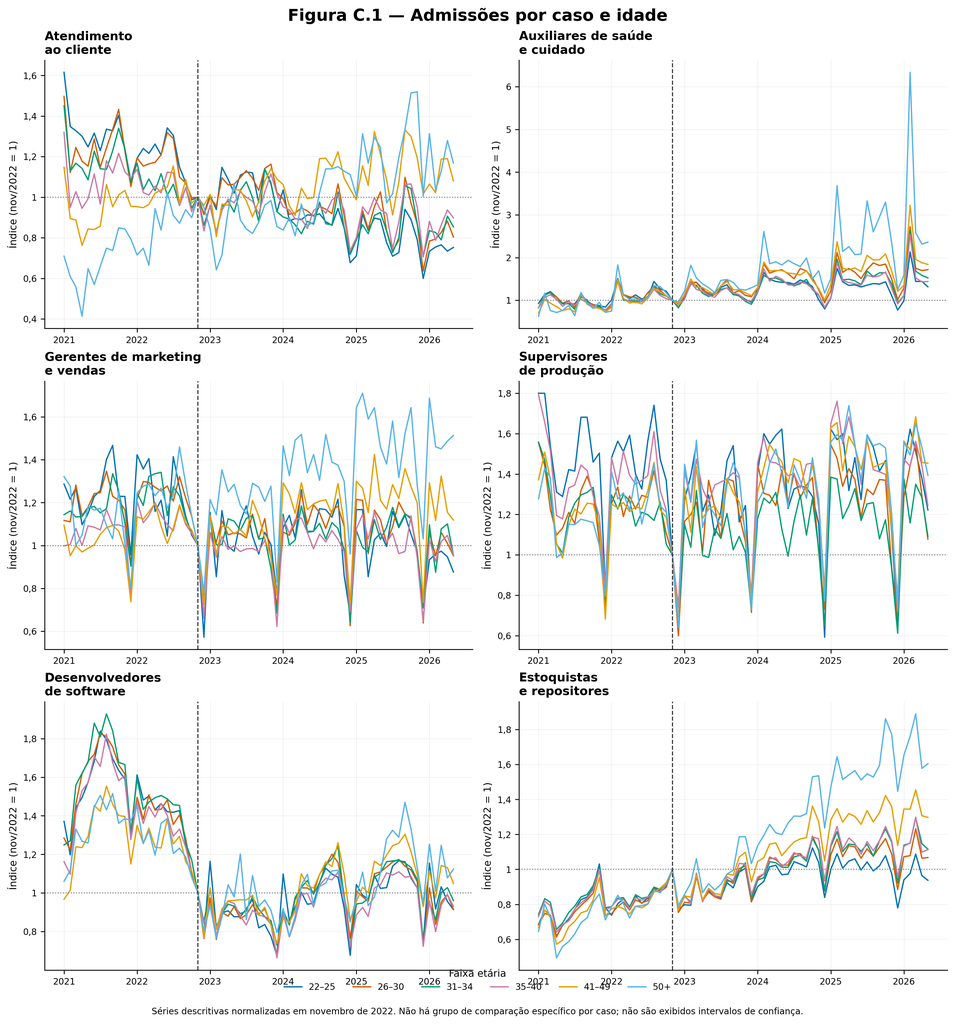

Figure C.1 — Monthly admissions by occupational case and age

#### 3.9.0.2 Figure C.2 — Monthly real admission wage by occupational case and age

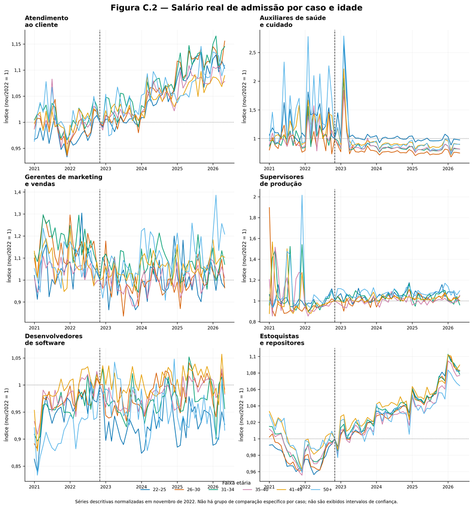

Figure C.2 — Monthly real admission wage by occupational case and age

# 4 Evidência complementar: RAIS e PNAD Contínua (Seção 5.4 e Apêndice B/D)

As extensões com RAIS e PNAD Contínua são evidência complementar. Elas usam outras unidades de observação e outros desfechos, preservam as famílias de multiplicidade D e E e não convertem mudança de composição em transição individual de trabalhadores.

## 4.1 RAIS: estoque formal, rotatividade e tempo de emprego

A RAIS fornece um recorte anual de vínculos formais. A entrada compacta tem uma linha por ocupação e ano para cada contrato de modelo. Abaixo, os três modelos são efetivamente reestimados em R; o script fonte completo é mostrado primeiro para tornar claro que a forma funcional, efeitos fixos e agrupamento são os mesmos do V2.

**Executado neste documento.** Os três modelos estáticos da RAIS são reestimados a partir de sua entrada compacta e sem coeficientes.

```r
#!/usr/bin/env Rscript

suppressPackageStartupMessages({
  library(data.table)
  library(fixest)
})

script_argument <- grep(
  "^--file=",
  commandArgs(trailingOnly = FALSE),
  value = TRUE
)
if (length(script_argument) != 1L) {
  stop("Unable to resolve r12_cross_replication.R location.")
}
script_path_raw <- sub("^--file=", "", script_argument)
if (!file.exists(script_path_raw)) {
  script_path_raw <- gsub("~\\+~", " ", script_path_raw)
}
script_path <- normalizePath(script_path_raw, mustWork = TRUE)
front_root <- dirname(dirname(script_path))
input_path <- file.path(
  front_root,
  "data",
  "vintage",
  "rais_cross_replication_input.csv"
)
output_path <- file.path(
  front_root,
  "results",
  "rais_cross_replication_r.csv"
)

if (!file.exists(input_path)) {
  stop("The frozen RAIS cross-replication input is missing.")
}

setFixest_nthreads(1L)
sample <- fread(
  input_path,
  colClasses = list(character = c("model_id", "outcome", "cbo_4d"))
)

fit_principal <- function(model_key) {
  model_data <- sample[model_id == model_key]
  if (nrow(model_data) == 0L) {
    stop(paste("Missing cross-replication model:", model_key))
  }
  estimator <- unique(model_data$estimator)
  outcome <- unique(model_data$outcome)
  if (length(estimator) != 1L || length(outcome) != 1L) {
    stop(paste("Model metadata is not unique:", model_key))
  }
  model_data[, cbo_4d := factor(cbo_4d)]
  model_data[, ano := factor(ano)]
  if (estimator == "ppml") {
    model <- fepois(
      y ~ post_treat | cbo_4d + ano,
      data = model_data,
      vcov = ~cbo_4d,
      fixef.rm = "perfect_fit",
      notes = FALSE,
      warn = TRUE
    )
  } else if (estimator == "ols") {
    model <- feols(
      y ~ post_treat | cbo_4d + ano,
      data = model_data,
      vcov = ~cbo_4d,
      fixef.rm = "perfect_fit",
      notes = FALSE,
      warn = TRUE
    )
  } else {
    stop(paste("Unsupported estimator:", estimator))
  }
  fixed_effects <- fixef(model, sorted = FALSE, notes = FALSE)
  data.table(
    outcome = outcome,
    estimator = estimator,
    coefficient = unname(coef(model)[["post_treat"]]),
    standard_error = unname(se(model)[["post_treat"]]),
    n_obs = nobs(model),
    n_clusters = length(fixed_effects[["cbo_4d"]])
  )
}

model_ids <- unique(sample$model_id)
results <- rbindlist(
  lapply(model_ids, fit_principal),
  use.names = TRUE
)
setorder(results, outcome)

temporary_path <- paste0(output_path, ".tmp")
fwrite(results, temporary_path)
if (!file.rename(temporary_path, output_path)) {
  stop("Unable to atomically publish the R result.")
}
cat(
  sprintf(
    "{\"models\":%d,\"rows\":%d}\n",
    nrow(results),
    sum(results$n_obs)
  )
)
```

```r
rais_input <- fread(
  file.path(bundle_root, "derived", "rais", "vintage", "rais_cross_replication_input.csv"),
  colClasses = list(character = c("model_id", "outcome", "cbo_4d"))
)

fit_rais_static <- function(data, model_key) {
  model_data <- copy(data[model_id == model_key])
  estimator <- unique(model_data$estimator)
  outcome <- unique(model_data$outcome)
  model_data[, `:=`(cbo_4d = factor(cbo_4d), ano = factor(ano))]
  fit <- if (identical(estimator, "ppml")) {
    fepois(
      y ~ post_treat | cbo_4d + ano,
      data = model_data,
      vcov = ~cbo_4d,
      fixef.rm = "perfect_fit",
      warn = TRUE
    )
  } else {
    feols(
      y ~ post_treat | cbo_4d + ano,
      data = model_data,
      vcov = ~cbo_4d,
      fixef.rm = "perfect_fit",
      warn = TRUE
    )
  }
  data.table(
    model_id = model_key,
    outcome = outcome,
    estimator = estimator,
    coefficient = unname(coef(fit)[["post_treat"]]),
    standard_error = unname(se(fit)[["post_treat"]]),
    n_obs = as.integer(nobs(fit)),
    n_clusters = uniqueN(model_data$cbo_4d)
  )
}

rais_light_results <- rbindlist(
  lapply(
    unique(rais_input$model_id),
    function(model_key) fit_rais_static(rais_input, model_key)
  )
)
rais_light_results
```

| model_id | outcome | estimator | coefficient | standard_error | n_obs | n_clusters |
| --- | --- | --- | --- | --- | --- | --- |
| rais_static__estoque_3112 | estoque_3112 | ppml | -0.04292458 | 0.01557407 | 2040 | 341 |
| rais_static__ln_taxa_rotatividade | ln_taxa_rotatividade | ols | -0.01783897 | 0.02619637 | 1359 | 341 |
| rais_static__ln_tempo_emprego_medio | ln_tempo_emprego_medio | ols | -0.02635556 | 0.01853318 | 2040 | 341 |

RAIS light R re-estimation compared with the frozen independent-R result

| outcome | model_id | estimator | coefficient | standard_error | n_obs | n_clusters | reference_coefficient | reference_standard_error | reference_n_obs | reference_n_clusters | coefficient_difference | standard_error_difference | comparison_pass |
| --- | --- | --- | --- | --- | --- | --- | --- | --- | --- | --- | --- | --- | --- |
| estoque_3112 | rais_static__estoque_3112 | ppml | -0.04292458 | 0.01557407 | 2040 | 341 | -0.04292458 | 0.01557407 | 2040 | 340 | 0 | 0 | TRUE |
| ln_taxa_rotatividade | rais_static__ln_taxa_rotatividade | ols | -0.01783897 | 0.02619637 | 1359 | 341 | -0.01783897 | 0.02619637 | 1359 | 340 | 0 | 0 | TRUE |
| ln_tempo_emprego_medio | rais_static__ln_tempo_emprego_medio | ols | -0.02635556 | 0.01853318 | 2040 | 341 | -0.02635556 | 0.01853318 | 2040 | 340 | 0 | 0 | TRUE |

**Gate científico.** A Família D usa um único ajuste Benjamini–Hochberg sobre seus três desfechos registrados. O status de pré-tendência continua sendo parte do resultado; um status falho impede linguagem causal.

Table D.1 — Formal stock, turnover, and job tenure (Family D)

| outcome | estimator | coefficient | standard_error | ci_low | ci_high | nominal_p_value | bh_adjusted_p_value | n_obs | minimum_clusters | pretrend_status | result_status | family_id |
| --- | --- | --- | --- | --- | --- | --- | --- | --- | --- | --- | --- | --- |
| estoque_3112 | ppml | -0.042925 | 0.015574 | -0.073559 | -0.012291 | 0.006165 | 0.018494 | 2040 | 340 | fail | estimated | D |
| ln_taxa_rotatividade | ols | -0.017839 | 0.026196 | -0.069367 | 0.033689 | 0.496355 | 0.496355 | 1359 | 340 | pass | estimated | D |
| ln_tempo_emprego_medio | ols | -0.026356 | 0.018533 | -0.062810 | 0.010099 | 0.155924 | 0.233886 | 2040 | 340 | fail | estimated | D |

Table B.1 — Exact-model pretrends for RAIS

| outcome | sample_window | joint_lead_count | joint_lead_p_value | linear_pretrend_p_value | dynamic_pre_p_lt_005 | lead_covariance_positive_semidefinite | pretrend_status | n_obs | minimum_clusters |
| --- | --- | --- | --- | --- | --- | --- | --- | --- | --- |
| estoque_3112 | 2019-2024 | 3 | 0.081808 | 0.144826 | 2 | TRUE | fail | 2040 | 340 |
| ln_taxa_rotatividade | 2021-2024 | 1 | 0.468768 | 0.469268 | 0 | TRUE | pass | 1359 | 340 |
| ln_tempo_emprego_medio | 2019-2024 | 3 | 0.046801 | 0.800239 | 0 | TRUE | fail | 2040 | 340 |

## 4.2 PNAD Contínua: informalidade, conta própria, estoques e renda

A PNAD Contínua combina dois braços de análise. O braço A usa resultados de composição ponderados no nível individual, agregados de maneira suficiente para a réplica independente; o braço B estima estoques ocupacionais COD3. O documento executa os seis contratos compactos, mas não lê o painel individual de cerca de dez milhões de linhas.

**Executado neste documento.** Os seis contratos PNADc abaixo são reestimados a partir de uma entrada compacta e sem coeficientes. COD4 está ausente de propósito: o desenho complementar da PNADc é definido em COD3.

```r
#!/usr/bin/env Rscript

suppressPackageStartupMessages(library(fixest))

args <- commandArgs(trailingOnly = TRUE)
if (length(args) != 2) {
  stop("Usage: pnadc_cross_replication.R INPUT_CSV OUTPUT_CSV")
}

input_path <- args[[1]]
output_path <- args[[2]]
data <- read.csv(input_path, stringsAsFactors = FALSE)

required_columns <- c(
  "model_id",
  "outcome",
  "arm",
  "cod3",
  "trimestre_num",
  "post_treat",
  "outcome_value",
  "regression_weight",
  "source_observations",
  "original_n"
)
if (!all(required_columns %in% names(data))) {
  stop("Cross-replication input has an invalid schema")
}
if (any(grepl("cod4", names(data), ignore.case = TRUE))) {
  stop("COD4 is forbidden in the PNADc cross-replication")
}

model_ids <- unique(data$model_id)
if (length(model_ids) != 6) {
  stop("The PNADc cross-replication requires six models")
}

rows <- vector("list", length(model_ids))
for (index in seq_along(model_ids)) {
  model_id <- model_ids[[index]]
  subset <- data[data$model_id == model_id, , drop = FALSE]
  arm <- unique(subset$arm)
  outcome <- unique(subset$outcome)
  original_n <- unique(subset$original_n)
  if (length(arm) != 1 || length(outcome) != 1 || length(original_n) != 1) {
    stop(paste("Inconsistent identifiers for", model_id))
  }

  if (arm == "A") {
    fit <- feols(
      outcome_value ~ post_treat | cod3 + trimestre_num,
      data = subset,
      weights = ~regression_weight,
      cluster = ~cod3,
      ssc = ssc(
        K.adj = TRUE,
        K.fixef = "nonnested",
        G.adj = TRUE,
        G.df = "min",
        t.df = "min"
      ),
      warn = TRUE
    )
    df_k <- as.integer(degrees_freedom(fit, type = "k"))
    collapsed_n <- nobs(fit)
    collapsed_adjustment <- (collapsed_n - 1) / (collapsed_n - df_k)
    original_adjustment <- (original_n - 1) / (original_n - df_k)
    standard_error <- unname(se(fit)[["post_treat"]]) *
      sqrt(original_adjustment / collapsed_adjustment)
  } else if (arm == "B") {
    fit <- fepois(
      outcome_value ~ post_treat | cod3 + trimestre_num,
      data = subset,
      cluster = ~cod3,
      ssc = ssc(
        K.adj = TRUE,
        K.fixef = "nonnested",
        G.adj = TRUE,
        G.df = "min",
        t.df = "min"
      ),
      warn = TRUE
    )
    df_k <- as.integer(degrees_freedom(fit, type = "k"))
    collapsed_n <- nobs(fit)
    standard_error <- unname(se(fit)[["post_treat"]])
  } else {
    stop(paste("Unknown arm for", model_id))
  }

  rows[[index]] <- data.frame(
    model_id = model_id,
    outcome = outcome,
    arm = arm,
    coefficient = unname(coef(fit)[["post_treat"]]),
    standard_error = standard_error,
    n_obs = as.integer(original_n),
    n_clusters = length(unique(subset$cod3)),
    computational_rows = as.integer(collapsed_n),
    df_k = df_k,
    engine = "fixest",
    stringsAsFactors = FALSE
  )
}

result <- do.call(rbind, rows)
temporary_path <- paste0(output_path, ".tmp")
write.csv(result, temporary_path, row.names = FALSE, na = "")
if (!file.rename(temporary_path, output_path)) {
  stop("Unable to atomically publish R cross-replication results")
}
```

```r
pnadc_input <- fread(
  file.path(bundle_root, "derived", "pnadc", "pnadc_cross_replication_input.csv")
)
if (any(grepl("cod4", names(pnadc_input), ignore.case = TRUE))) {
  stop("COD4 must not appear in the PNADc companion input.")
}

fit_pnadc_static <- function(data, model_key) {
  model_data <- copy(data[model_id == model_key])
  arm <- unique(model_data$arm)
  outcome <- unique(model_data$outcome)
  original_n <- unique(model_data$original_n)
  if (length(arm) != 1L || length(outcome) != 1L || length(original_n) != 1L) {
    stop("Inconsistent compact PNADc contract: ", model_key)
  }
  if (arm == "A") {
    fit <- feols(
      outcome_value ~ post_treat | cod3 + trimestre_num,
      data = model_data,
      weights = ~regression_weight,
      cluster = ~cod3,
      ssc = ssc(K.adj = TRUE, K.fixef = "nonnested", G.adj = TRUE, G.df = "min", t.df = "min"),
      warn = TRUE
    )
    df_k <- as.integer(degrees_freedom(fit, type = "k"))
    collapsed_n <- nobs(fit)
    collapsed_adjustment <- (collapsed_n - 1) / (collapsed_n - df_k)
    original_adjustment <- (original_n - 1) / (original_n - df_k)
    standard_error <- unname(se(fit)[["post_treat"]]) *
      sqrt(original_adjustment / collapsed_adjustment)
    estimator <- "ols"
  } else if (arm == "B") {
    fit <- fepois(
      outcome_value ~ post_treat | cod3 + trimestre_num,
      data = model_data,
      cluster = ~cod3,
      ssc = ssc(K.adj = TRUE, K.fixef = "nonnested", G.adj = TRUE, G.df = "min", t.df = "min"),
      warn = TRUE
    )
    df_k <- as.integer(degrees_freedom(fit, type = "k"))
    collapsed_n <- nobs(fit)
    standard_error <- unname(se(fit)[["post_treat"]])
    estimator <- "ppml"
  } else {
    stop("Unknown PNADc arm: ", arm)
  }
  data.table(
    model_id = model_key,
    outcome = outcome,
    arm = arm,
    estimator = estimator,
    coefficient = unname(coef(fit)[["post_treat"]]),
    standard_error = standard_error,
    n_obs = as.integer(original_n),
    n_clusters = uniqueN(model_data$cod3),
    computational_rows = as.integer(collapsed_n),
    df_k = df_k
  )
}

pnadc_light_results <- rbindlist(
  lapply(
    unique(pnadc_input$model_id),
    function(model_key) fit_pnadc_static(pnadc_input, model_key)
  )
)
pnadc_light_results
```

| model_id | outcome | arm | estimator | coefficient | standard_error | n_obs | n_clusters | computational_rows | df_k |
| --- | --- | --- | --- | --- | --- | --- | --- | --- | --- |
| pnadc_principal_informal | informal | A | ols | 0.008539600 | 0.01132477 | 10009479 | 115 | 6600 | 57 |
| pnadc_principal_conta_propria | conta_propria | A | ols | 0.021259441 | 0.02094821 | 10009479 | 115 | 6600 | 57 |
| pnadc_principal_ln_renda | ln_renda | A | ols | -0.009282283 | 0.02175751 | 9631074 | 115 | 6600 | 57 |
| pnadc_principal_ocupados_total | ocupados_total | B | ppml | 0.061563096 | 0.04296666 | 5621 | 101 | 5621 | 57 |
| pnadc_principal_ocupados_formais | ocupados_formais | B | ppml | 0.042009788 | 0.04824800 | 5621 | 101 | 5621 | 57 |
| pnadc_principal_ocupados_informais | ocupados_informais | B | ppml | 0.081723342 | 0.05759949 | 5621 | 101 | 5621 | 57 |

PNADc light R re-estimation compared with the frozen independent-R result

| model_id | outcome | arm | estimator | coefficient | standard_error | n_obs | n_clusters | computational_rows | df_k | reference_coefficient | reference_standard_error | reference_n_obs | reference_n_clusters | coefficient_difference | standard_error_difference | comparison_pass |
| --- | --- | --- | --- | --- | --- | --- | --- | --- | --- | --- | --- | --- | --- | --- | --- | --- |
| pnadc_principal_conta_propria | conta_propria | A | ols | 0.021259441 | 0.02094821 | 10009479 | 115 | 6600 | 57 | 0.021259441 | 0.02094821 | 10009479 | 115 | 0 | 0 | TRUE |
| pnadc_principal_informal | informal | A | ols | 0.008539600 | 0.01132477 | 10009479 | 115 | 6600 | 57 | 0.008539600 | 0.01132477 | 10009479 | 115 | 0 | 0 | TRUE |
| pnadc_principal_ln_renda | ln_renda | A | ols | -0.009282283 | 0.02175751 | 9631074 | 115 | 6600 | 57 | -0.009282283 | 0.02175751 | 9631074 | 115 | 0 | 0 | TRUE |
| pnadc_principal_ocupados_formais | ocupados_formais | B | ppml | 0.042009788 | 0.04824800 | 5621 | 101 | 5621 | 57 | 0.042009788 | 0.04824800 | 5621 | 101 | 0 | 0 | TRUE |
| pnadc_principal_ocupados_informais | ocupados_informais | B | ppml | 0.081723342 | 0.05759949 | 5621 | 101 | 5621 | 57 | 0.081723342 | 0.05759949 | 5621 | 101 | 0 | 0 | TRUE |
| pnadc_principal_ocupados_total | ocupados_total | B | ppml | 0.061563096 | 0.04296666 | 5621 | 101 | 5621 | 57 | 0.061563096 | 0.04296666 | 5621 | 101 | 0 | 0 | TRUE |

**Gate científico.** A Família E aplica Benjamini–Hochberg uma vez sobre todos os seis desfechos registrados. Suas estimativas são diferenciais explícitos de composição/estoque, não transições individuais de emprego, e o status de pré-tendência suprime a interpretação causal quando falha.

Table D.2 — Occupational composition and stock (Family E)

| outcome | arm | estimator | coefficient | standard_error | ci_low | ci_high | nominal_p_value | bh_adjusted_p_value | n_obs | minimum_clusters | pretrend_status_full | pretrend_status_without_2020 | result_status | family_id |
| --- | --- | --- | --- | --- | --- | --- | --- | --- | --- | --- | --- | --- | --- | --- |
| informal | A | ols | 0.008540 | 0.011325 | -0.013895 | 0.030974 | 0.452366 | 0.542839 | 10009479 | 115 | fail | fail | estimated | E |
| conta_propria | A | ols | 0.021259 | 0.020948 | -0.020239 | 0.062758 | 0.312323 | 0.542839 | 10009479 | 115 | fail | fail | estimated | E |
| ocupados_total | B | ppml | 0.061563 | 0.042967 | -0.023682 | 0.146808 | 0.155031 | 0.477182 | 5621 | 101 | fail | fail | estimated | E |
| ocupados_formais | B | ppml | 0.042010 | 0.048248 | -0.053713 | 0.137732 | 0.386001 | 0.542839 | 5621 | 101 | fail | fail | estimated | E |
| ocupados_informais | B | ppml | 0.081723 | 0.057600 | -0.032552 | 0.195999 | 0.159061 | 0.477182 | 5621 | 101 | fail | fail | estimated | E |
| ln_renda | A | ols | -0.009282 | 0.021758 | -0.052384 | 0.033819 | 0.670458 | 0.670458 | 9631074 | 115 | fail | fail | estimated | E |

Table B.2 — Exact-model pretrends for PNADc

| outcome | sample | joint_lead_count | joint_lead_p_value | linear_pretrend_p_value | dynamic_pre_p_lt_005 | lead_covariance_positive_semidefinite | pretrend_status | n_obs | minimum_clusters |
| --- | --- | --- | --- | --- | --- | --- | --- | --- | --- |
| informal | full | 42 | 0.000000 | 0.523092 | 0 | TRUE | fail | 10009479 | 115 |
| informal | without_2020 | 38 | 0.000000 | 0.061304 | 0 | TRUE | fail | 9511403 | 115 |
| conta_propria | full | 42 | 0.001616 | 0.928121 | 0 | TRUE | fail | 10009479 | 115 |
| conta_propria | without_2020 | 38 | 0.000955 | 0.921488 | 0 | TRUE | fail | 9511403 | 115 |
| ocupados_total | full | 42 | 0.000000 | 0.000223 | 2 | TRUE | fail | 5621 | 101 |
| ocupados_total | without_2020 | 38 | 0.000000 | 0.000006 | 2 | TRUE | fail | 5220 | 101 |
| ocupados_formais | full | 42 | 0.000000 | 0.003414 | 3 | TRUE | fail | 5621 | 101 |
| ocupados_formais | without_2020 | 38 | 0.000000 | 0.002635 | 2 | TRUE | fail | 5220 | 101 |
| ocupados_informais | full | 42 | 0.000000 | 0.189829 | 3 | TRUE | fail | 5621 | 101 |
| ocupados_informais | without_2020 | 38 | 0.000000 | 0.646626 | 3 | TRUE | fail | 5220 | 101 |
| ln_renda | full | 42 | 0.000000 | 0.000318 | 0 | TRUE | fail | 9631074 | 115 |
| ln_renda | without_2020 | 38 | 0.000000 | 0.000286 | 1 | TRUE | fail | 9150325 | 115 |

# 5 Extensão espacial: placebo, pré-tendências e suporte (Seção 4.5 e Apêndice B)

A extensão espacial não produz um efeito DDD substantivo. Ela é um diagnóstico de suporte: testa um placebo temporal, avalia pré-tendências e mede a concentração efetiva de clusters para proxies de intensidade digital. A família F tem doze posições declaradas, mas nenhum coeficiente, p-valor ou ajuste BH é permitido enquanto o gate de suporte não é aprovado.

**Gate científico.** A extensão espacial para no gate de suporte. Este guia exibe sua implementação em R e diagnósticos congelados, mas não estima uma DDD de tratamento, porque tal estimativa é proibida pelo contrato do V2.

```r
#!/usr/bin/env Rscript

suppressPackageStartupMessages({
  library(data.table)
  library(fixest)
  library(jsonlite)
})

setFixest_nthreads(1L)
setFixest_notes(FALSE)
arguments <- commandArgs(trailingOnly = TRUE)
if (length(arguments) != 7L) {
  stop(
    "Usage: spatial_replication.R STAGE0 SUPPORT CONTRACTS ",
    "MODELS PRETRENDS SUPPORT_RESULTS STATUS"
  )
}
if (paste(R.version$major, R.version$minor, sep = ".") != "4.4.1") {
  stop("The locked replication runtime requires R 4.4.1.")
}

stage0 <- fread(
  arguments[[1L]],
  colClasses = list(character = c(
    "id_municipio", "cbo_municipio", "cbo_periodo", "uf_periodo"
  ))
)
support <- fread(
  arguments[[2L]],
  colClasses = list(character = c(
    "id_municipio", "uf_code", "cbo_municipio", "cbo_periodo", "uf_periodo"
  ))
)
contracts <- fread(arguments[[3L]])

cluster_count <- function(model) {
  value <- attr(vcov(model), "min_cluster_size")
  if (is.null(value) || length(value) != 1L || is.na(value)) {
    stop("Cluster count is unavailable.")
  }
  as.integer(value)
}

event_time_from_term <- function(term) {
  parsed <- sub("^event_time::(-?[0-9]+):.*$", "\\1", term)
  if (identical(parsed, term)) return(NA_integer_)
  as.integer(parsed)
}

pinv <- function(matrix) {
  decomposition <- svd(matrix)
  tolerance <- 1e-15 * max(decomposition$d)
  inverse <- ifelse(decomposition$d > tolerance, 1 / decomposition$d, 0)
  decomposition$v %*% diag(inverse, nrow = length(inverse)) %*%
    t(decomposition$u)
}

classify_pretrend <- function(joint_p, linear_p, individual_count) {
  if (joint_p < 0.05 || linear_p < 0.05 || individual_count >= 2L) {
    return("fail")
  }
  if (joint_p > 0.10 && linear_p > 0.10 && individual_count == 0L) {
    return("pass")
  }
  "warning"
}

model_rows <- list()
diagnostic_rows <- list()
for (index in seq_len(nrow(contracts))) {
  contract <- contracts[index]
  high <- stage0[[contract$high_column]]
  y <- stage0[[contract$outcome]]
  model_data <- copy(stage0)
  model_data[, y := y]
  if (contract$kind == "placebo") {
    model_data[, placebo_post := as.integer(periodo_num >= 202112L)]
    model_data[, placebo_post_high := placebo_post * high]
    model_data[, placebo_triple := placebo_post * treated * high]
    base <- feols(
      y ~ placebo_triple + placebo_post_high |
        cbo_municipio + cbo_periodo + uf_periodo,
      data = model_data,
      fixef.rm = "singleton",
      warn = TRUE
    )
    model <- summary(base, vcov = ~id_municipio, vcov_fix = FALSE)
    model_rows[[length(model_rows) + 1L]] <- data.table(
      model_id = contract$model_id,
      event_time = NA_integer_,
      coefficient = as.numeric(coef(model)[["placebo_triple"]]),
      standard_error = as.numeric(se(model)[["placebo_triple"]]),
      n_obs = as.integer(nobs(model)),
      minimum_clusters = cluster_count(model),
      reference_event_time = NA_integer_,
      status = "estimated"
    )
  } else {
    model_data[, pretrend_high := high]
    model_data[, pretrend_treated_high := treated * high]
    base <- feols(
      y ~ i(event_time, pretrend_treated_high, ref = -1) +
        i(event_time, pretrend_high, ref = -1) |
        cbo_municipio + cbo_periodo + uf_periodo,
      data = model_data,
      fixef.rm = "singleton",
      warn = TRUE
    )
    model <- summary(base, vcov = ~id_municipio, vcov_fix = FALSE)
    coefficient_names <- names(coef(model))
    event_times <- vapply(coefficient_names, event_time_from_term, integer(1L))
    triple_positions <- which(
      !is.na(event_times) & grepl(":pretrend_treated_high$", coefficient_names)
    )
    expected <- -23L:-2L
    if (!identical(unname(event_times[triple_positions]), expected)) {
      stop("Incomplete spatial pretrend grid for ", contract$model_id)
    }
    coefficients <- as.numeric(coef(model)[triple_positions])
    standard_errors <- as.numeric(se(model)[triple_positions])
    model_rows[[length(model_rows) + 1L]] <- data.table(
      model_id = contract$model_id,
      event_time = event_times[triple_positions],
      coefficient = coefficients,
      standard_error = standard_errors,
      n_obs = as.integer(nobs(model)),
      minimum_clusters = cluster_count(model),
      reference_event_time = -1L,
      status = "estimated"
    )
    covariance <- vcov(model)[triple_positions, triple_positions, drop = FALSE]
    symmetric <- 0.5 * (covariance + t(covariance))
    minimum_eigenvalue <- min(eigen(symmetric, symmetric = TRUE)$values)
    scale <- max(abs(diag(symmetric)))
    covariance_is_psd <- minimum_eigenvalue >= -1e-8 * max(scale, 1)
    joint_precision <- solve(covariance, tol = 0)
    joint <- as.numeric(t(coefficients) %*% joint_precision %*% coefficients)
    joint_p <- pchisq(joint, df = length(coefficients), lower.tail = FALSE)
    precision <- pinv(covariance)
    design <- expected + 1L
    denominator <- as.numeric(t(design) %*% precision %*% design)
    slope <- as.numeric(t(design) %*% precision %*% coefficients / denominator)
    slope_se <- sqrt(1 / denominator)
    clusters <- cluster_count(model)
    slope_p <- 2 * pt(-abs(slope / slope_se), df = clusters - 1L)
    individual_p <- 2 * pt(
      -abs(coefficients / standard_errors),
      df = clusters - 1L
    )
    individual_count <- sum(individual_p < 0.05)
    diagnostic_rows[[length(diagnostic_rows) + 1L]] <- data.table(
      model_id = contract$model_id,
      joint_lead_count = length(coefficients),
      joint_lead_statistic = joint,
      joint_lead_p_value = joint_p,
      lead_covariance_min_eigenvalue = minimum_eigenvalue,
      lead_covariance_positive_semidefinite = covariance_is_psd,
      linear_pretrend_coefficient = slope,
      linear_pretrend_standard_error = slope_se,
      linear_pretrend_p_value = slope_p,
      dynamic_pre_p_lt_005 = individual_count,
      dynamic_min_p_value = min(individual_p),
      pretrend_status = classify_pretrend(joint_p, slope_p, individual_count),
      n_obs = as.integer(nobs(model)),
      minimum_clusters = clusters,
      reference_event_time = -1L,
      status = "estimated"
    )
  }
  rm(model_data, base, model)
  gc(verbose = FALSE)
}

effective_clusters <- function(residual, cluster) {
  mass <- data.table(cluster = cluster, mass = residual^2)[, .(mass = sum(mass)), by = cluster]
  shares <- mass$mass / sum(mass$mass)
  1 / sum(shares^2)
}

proxy_specs <- list(
  list(
    proxy = "fixed_broadband_penetration",
    continuous = "penetracao_bl",
    high = "high_connectivity"
  ),
  list(
    proxy = "digital_intensive_admission_share",
    continuous = "digital_admission_share",
    high = "high_digital_admission_share"
  ),
  list(
    proxy = "pnad_internet_use_2021",
    continuous = "internet_use_pct",
    high = "high_pnad_internet_use"
  )
)
support_rows <- list()
for (specification in proxy_specs) {
  support[, support_key := post * treated * get(specification$high)]
  residual_model <- feols(
    support_key ~ 1 | cbo_municipio + cbo_periodo + uf_periodo,
    data = support,
    fixef.rm = "none",
    warn = TRUE
  )
  support[, support_key := NULL]
  if (nobs(residual_model) != nrow(support)) {
    stop("R support residualization removed rows unexpectedly.")
  }
  residual <- resid(residual_model)
  effective_municipalities <- effective_clusters(
    residual,
    support$id_municipio
  )
  effective_ufs <- effective_clusters(residual, support$uf_code)
  municipality_status <- if (
    effective_municipalities >= 50
  ) "adequate" else if (effective_municipalities >= 25) "limited" else "thin"
  uf_status <- if (
    effective_ufs >= 20
  ) "adequate" else if (effective_ufs >= 10) "limited" else "thin"
  classification <- if (
    municipality_status == "thin" || uf_status == "thin"
  ) "thin" else if (
    municipality_status == "limited" || uf_status == "limited"
  ) "limited" else "adequate"
  uf_mass <- data.table(
    uf_code = support$uf_code,
    mass = residual^2
  )[, .(mass = sum(mass)), by = uf_code]
  uf_mass[, leverage := mass / sum(mass)]
  largest <- uf_mass[which.max(leverage)]
  support_rows[[length(support_rows) + 1L]] <- data.table(
    proxy = specification$proxy,
    municipality_clusters_nominal = uniqueN(support$id_municipio),
    uf_clusters_nominal = uniqueN(support$uf_code),
    continuous_proxy_distinct_values = uniqueN(
      support[[specification$continuous]]
    ),
    split_proxy_distinct_values = uniqueN(support[[specification$high]]),
    effective_municipality_clusters = effective_municipalities,
    effective_uf_clusters = effective_ufs,
    largest_uf_leverage_code = largest$uf_code,
    largest_uf_leverage_share = largest$leverage,
    classification = classification
  )
  rm(residual_model, residual)
  gc(verbose = FALSE)
}

model_results <- rbindlist(model_rows, use.names = TRUE)
pretrend_results <- rbindlist(diagnostic_rows, use.names = TRUE)
support_results <- rbindlist(support_rows, use.names = TRUE)
setorder(model_results, model_id, event_time)
setorder(pretrend_results, model_id)
setorder(support_results, proxy)
fwrite(model_results, arguments[[4L]])
fwrite(pretrend_results, arguments[[5L]])
fwrite(support_results, arguments[[6L]])
status <- list(
  family_f_declared_slots = 12L,
  family_f_coefficients_created = 0L,
  family_f_p_values_created = 0L,
  model_rows = nrow(model_results),
  pretrend_models = nrow(pretrend_results),
  r_version = paste(R.version$major, R.version$minor, sep = "."),
  status = "pass",
  support_proxies = nrow(support_results),
  treatment_coefficient_estimated = FALSE
)
write_json(status, arguments[[7L]], auto_unbox = TRUE, pretty = TRUE, digits = 16)
cat(toJSON(status, auto_unbox = TRUE, digits = 16), "\n")
```

**Carregado da referência assinada do V2.** As duas tabelas espaciais publicadas são diagnósticos de suporte, não estimativas de efeito de tratamento.

Table B.3 — December 2021 temporal placebo

| outcome | coefficient | standard_error | p_value | n_obs | minimum_clusters | real_treatment_coefficient_estimated |
| --- | --- | --- | --- | --- | --- | --- |
| ln_admissoes | 0.009607 | 0.005574 | 0.085281 | 1533998 | 657 | FALSE |
| ln_desligamentos | 0.007669 | 0.005011 | 0.126390 | 1533998 | 657 | FALSE |
| ln_salario_real_adm | 0.001169 | 0.002509 | 0.641351 | 1231420 | 657 | FALSE |
| asinh_saldo | -0.013855 | 0.015826 | 0.381645 | 1533998 | 657 | FALSE |

Table B.4 — Effective clusters by digital-intensity proxy

[output not shown]

Family F declaration: registered positions without estimates

| family | family_size | outcome | proxy | coefficient | p_value | bh_adjusted_p_value | status |
| --- | --- | --- | --- | --- | --- | --- | --- |
| F | 12 | ln_admissoes | fixed_broadband_penetration | NA | NA | NA | declared_not_estimated |
| F | 12 | ln_admissoes | digital_intensive_admission_share | NA | NA | NA | declared_not_estimated |
| F | 12 | ln_admissoes | pnad_internet_use_2021 | NA | NA | NA | declared_not_estimated |
| F | 12 | ln_desligamentos | fixed_broadband_penetration | NA | NA | NA | declared_not_estimated |
| F | 12 | ln_desligamentos | digital_intensive_admission_share | NA | NA | NA | declared_not_estimated |
| F | 12 | ln_desligamentos | pnad_internet_use_2021 | NA | NA | NA | declared_not_estimated |
| F | 12 | ln_salario_real_adm | fixed_broadband_penetration | NA | NA | NA | declared_not_estimated |
| F | 12 | ln_salario_real_adm | digital_intensive_admission_share | NA | NA | NA | declared_not_estimated |
| F | 12 | ln_salario_real_adm | pnad_internet_use_2021 | NA | NA | NA | declared_not_estimated |
| F | 12 | asinh_saldo | fixed_broadband_penetration | NA | NA | NA | declared_not_estimated |
| F | 12 | asinh_saldo | digital_intensive_admission_share | NA | NA | NA | declared_not_estimated |
| F | 12 | asinh_saldo | pnad_internet_use_2021 | NA | NA | NA | declared_not_estimated |

# 6 Roteiro de conferência e limites de interpretação

## 6.1 Um caminho curto para a leitura conjunta com a dissertação

1. Comece pela Seção 3 deste guia e pelas Tabelas/Figuras 3.1–3.10 na dissertação. Veja a definição de cobertura e depois os agregados independentes em R.
2. Passe à Seção 4 para entender a cadeia `MOV + FOR - EXC`, a unidade ocupação-mês, o tratamento e os desfechos antes de olhar qualquer coeficiente.
3. Leia a equação DiD e os cinco modelos nacionais leves executados em R. Em seguida, compare o quadro de reconciliação com a tabela congelada.
4. Na Seção 5, leia o estudo de eventos e o status de pré-tendência antes de interpretar a tabela estática. Faça o mesmo para cada heterogeneidade DDD.
5. Use RAIS e PNADc como evidência complementar, mantendo a distinção entre composição, estoque e transição individual.
6. Termine no módulo espacial: ele é deliberadamente uma extensão de suporte e não gera um efeito de tratamento.

## 6.2 Onde cada leitura encontra o código-fonte

Source-code navigation map

| topic | source_file | purpose |
| --- | --- | --- |
| Section 3 aggregates in R | R/section3_replication.R | Weighted descriptive aggregates and cross-language identifiers |
| Independent CAGED contracts in R | R/complete_replication.R | Contract-driven fixed-effects, PPML/OLS, event studies, and validation |
| CAGED raw movements | code/caged/ingest/build_movements.py | Official-vintage MOV/FOR/EXC reconstruction with signed weights |
| CAGED occupation-month panel | code/caged/panel/build_panel.py | CBO4-by-month panel, treatment, deflation, and support contracts |
| RAIS independent R replication | code/rais/r12_cross_replication.R | Family D static models |
| PNADc independent R replication | code/pnadc/pnadc_cross_replication.R | Family E COD3 composition and stock models |
| Spatial support diagnostics in R | code/spatial/spatial_replication.R | Placebo, pretrend, and effective-cluster diagnostics |

## 6.3 Checklist editorial e de integridade

**Carregado da referência assinada do V2.** O mapa de cobertura resolve todo artefato computacional da versão atual da dissertação para uma referência V2 existente ou um arquivo de backing data. Renderizar este guia escreve apenas seu HTML.

Companion integrity checks

| manuscript_computational_artifacts | signed_v2_artifacts | current_manuscript_backing_data | available_reference_paths | missing_reference_paths | reference_is_read_only |
| --- | --- | --- | --- | --- | --- |
| 55 | 53 | 2 | 55 | 0 | Yes: this document only reads V2/results/reference |

Compact R re-estimation checks (tolerance 1e-6)

| component | models_compared | models_within_1e6 | status |
| --- | --- | --- | --- |
| caged | 5 | 5 | pass |
| rais | 3 | 3 | pass |
| pnadc | 6 | 6 | pass |

Os seguintes limites permanecem explícitos neste guia e na dissertação:

- Pré-tendências que falham não são transformadas em evidência causal por meio de uma estimativa estática favorável.
- Uma covariância de leads não PSD, suporte insuficiente ou poucos clusters permanece um gate científico, não um detalhe de apresentação.
- RAIS e PNADc descrevem evidência complementar; composição ocupacional não é transição individual.
- A extensão espacial termina antes de qualquer coeficiente de tratamento ou p-valor da Família F.
- Tabelas e gráficos carregados são referências congeladas; as reestimações leves servem para tornar o código legível e verificável em R, não para substituir a execução completa do V2.

## 6.4 Como renderizar novamente

Por padrão, o documento usa os caminhos relativos de um checkout que contém `Replication Package/V2` e `Replication Package/_bundle/v2` lado a lado. Para renderizar com os cinco modelos CAGED, os três RAIS e os seis PNADc:

```r
setwd("Replication Package/R Companion")
rmarkdown::render("dissertation_code_companion.Rmd")
```

Para uma leitura ainda mais rápida, sem rodar os modelos leves, passe `run_light_models = FALSE`. Os resultados congelados, as figuras e o código continuarão disponíveis.

```r
rmarkdown::render(
  "dissertation_code_companion.Rmd",
  params = list(run_light_models = FALSE)
)
```

## 6.5 Ambiente R desta renderização